# Social Network Analysis - Amber Heard Case - Twitter (Aquaman Petition)

MAHMOUD NAGY - JUNE 2022

- **Introduction**
- Exploratory Data Analysis
- Conclusions

## Introduction

> Twitter (Aquaman Petition) - Social Network Analysis on Amber Heard's Case

```python
import pandas as pd
import os
pd.set_option('display.max_columns', 500)
import numpy as np
import matplotlib.pyplot as plt
import seaborn as sb
import matplotlib.dates as mdates
import plotly.express as px
import plotly.graph_objects as go
import pickle
import re
import warnings
import datetime
warnings.filterwarnings('ignore')
sb.set_style("darkgrid")
%matplotlib inline

import plotly.io as pio
pio.renderers
# pio.renderers.default = "svg"
svg_renderer = pio.renderers["svg"]
svg_renderer.width = 950
svg_renderer.height = 550


# To Apply helpers updates without resarting the kernel
import importlib
import helpers
importlib.reload(helpers)

from load_data import *

# # To keep track of any module updates
# %load_ext autoreload
# %autoreload2

%config InlineBackend.figure_format = 'retina'
```

## Exploratory Data Analysis

- Introduction
- **Exploratory Data Analysis**
- Conclusions

```python
# Filtered Data on Aquaman petition Links
print(aquaman_petition.shape)
aquaman_petition.head(2)
```

```
(55324, 30)
```

|  | n_statuses | created_at | user_description | user_created_at | user_id | username | is_verified | user_location | n_followers | user_url | lang | profile_banner_url | profile_image_url | text | n_friends | tweet_id | user_screen_name | date | year | month | dayofmonth | hour | diff | days_diff | minutes_diff | retweet_count | reply_count | like_count | quote_count | … |
| --- | --- | --- | --- | --- | --- | --- | --- | --- | --- | --- | --- | --- | --- | --- | --- | --- | --- | --- | --- | --- | --- | --- | --- | --- | --- | --- | --- | --- | --- | --- |
| 4434 | 2860 | 2018-03-16 21:52:09 | I pretend to be sophisticated, but really I'm ... | 2016-06-29 18:06:35 | 748216104565235712 | Morgan | False | NaN | 177 | https://t.co/7NiXfsBF9J | en | https://pbs.twimg.com/profile_banners/74821610... | http://pbs.twimg.com/profile_images/1202278135... | can't find the receipts but he also defended j... | 656 | 974765287080853508 | mdragonfly89 | 2018-03-16 | 2018 | Mar | 16 | 21 | 625 days 03:45:34 | 625 | 225.57 | 0.0 | 0.0 | 6.0 | 0.0 | … |
| 4577 | 4654 | 2018-03-18 22:06:17 | Daily film news, intellectually stimulating ed... | 2018-02-17 08:29:20 | 964778778143555585 | Le Cinéphiles | False | Le Cinéma | 17786 | https://t.co/TexAcEQbue | en | https://pbs.twimg.com/profile_banners/96477877... | http://pbs.twimg.com/profile_images/1035011501... | breaking: amber heard reportedly grew a mustac... | 528 | 975493621917954048 | LeCinephiles | 2018-03-18 | 2018 | Mar | 18 | 22 | 29 days 13:36:57 | 29 | 816.95 | 44.0 | 5.0 | 177.0 | 9.0 | … |

```python
aquaman_petition.created_at.dt.date.min(), aquaman_petition.created_at.dt.date.max()
```

```
(datetime.date(2018, 3, 16), datetime.date(2022, 4, 28))
```

```python
# Users Tweeted with "Aquaman Petition Links"
print(aquaman_petition_u.shape)
aquaman_petition_u.head(2)
```

```
(38396, 13)
```

|  | user_id | user_created_at | username | user_screen_name | n_followers | n_friends | n_statuses | user_url | user_description | user_location | profile_banner_url | profile_image_url | is_verified |
| --- | --- | --- | --- | --- | --- | --- | --- | --- | --- | --- | --- | --- | --- |
| 26 | 70083 | 2006-12-15 10:35:38 | marul69 | marul69 | 2952 | 1043 | 43859 | NaN | Not here to please you. | Brunei Darussalam | https://pbs.twimg.com/profile_banners/70083/16... | http://pbs.twimg.com/profile_images/5195113944... | False |
| 41 | 671883 | 2007-01-20 18:31:59 | Martin Edelius | MartinNr5 | 51 | 36 | 5744 | NaN | Life's too short. | In the Floda woodlands! | NaN | http://pbs.twimg.com/profile_images/3707406681... | False |

> **NOTE:**
> - 38396 users tweeted with "aquaman petition" related links

## Tweets Metrics

> - **Tweets Metrics**
> - Users Tweets Metrics
> - ------------------------------
> - Duration After Account Creation
> - Tweets Created OVER TIME
> - Peak Dates
> - ------------------------------
> - Tweets on Peaks
> - Most Repeated Tweets
> - Same Text Same Date
> - ------------------------------
> - Unverified Accounts
> - Deleted or Banned
> - Default Profile Image
> - Users Metrics

## Tweets Metrics

> > - **Metrics Vs Time**
> > - Top Retweeted Tweets
> > - Tweets with Most Likes
> > - Tweets with Most Replies

## Metrics Vs Time

> > - **Retweets**
> > - Likes
> > - Replies

## Daily Metrics (Peak Retweets)

```python
df_daily_metrics = (
    aquaman_petition.groupby(['date', 'year', 'month', 'dayofmonth'])
    .agg({'text':'count', 'user_id': 'nunique', 'total_retweets': 'sum', 'like_count': 'sum', 'reply_count': 'sum'})
    .reset_index().rename(columns={'text':'n_tweets', 'user_id': 'by_#accounts'})
)
df_daily_metrics.sort_values('total_retweets', ascending=False).head(10)
```

|  | date | year | month | dayofmonth | n_tweets | by_#accounts | total_retweets | like_count | reply_count |
| --- | --- | --- | --- | --- | --- | --- | --- | --- | --- |
| 1100 | 2022-04-28 | 2022 | Apr | 28 | 3231 | 3067 | 19208.0 | 129141.0 | 2035.0 |
| 694 | 2021-02-28 | 2021 | Feb | 28 | 494 | 470 | 14106.0 | 105434.0 | 954.0 |
| 586 | 2020-11-12 | 2020 | Nov | 12 | 3197 | 2902 | 7044.0 | 32154.0 | 1421.0 |
| 580 | 2020-11-06 | 2020 | Nov | 6 | 849 | 748 | 5442.0 | 10344.0 | 214.0 |
| 846 | 2021-07-30 | 2021 | Jul | 30 | 112 | 109 | 5256.0 | 14052.0 | 3051.0 |
| 302 | 2020-02-02 | 2020 | Feb | 2 | 1654 | 1597 | 3288.0 | 11527.0 | 187.0 |
| 224 | 2019-11-11 | 2019 | Nov | 11 | 179 | 175 | 3238.0 | 860.0 | 69.0 |
| 815 | 2021-06-29 | 2021 | Jun | 29 | 98 | 85 | 2510.0 | 8851.0 | 197.0 |
| 581 | 2020-11-07 | 2020 | Nov | 7 | 1565 | 1387 | 2345.0 | 7606.0 | 162.0 |
| 695 | 2021-03-01 | 2021 | Mar | 1 | 161 | 148 | 1945.0 | 3805.0 | 693.0 |

## HeatMap For "Aquaman Petition Links" Retweets

```python
# importlib.reload(helpers)
```

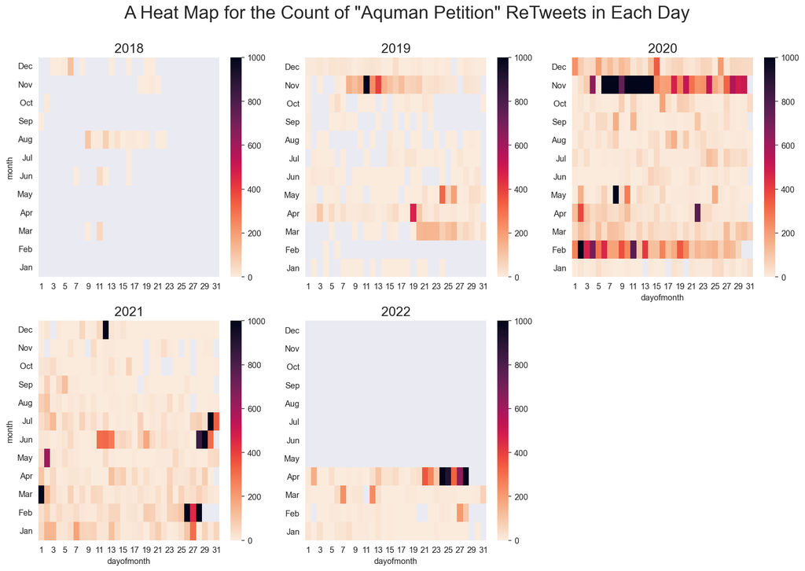

```python
title = 'A Heat Map for the Count of "Aquman Petition" ReTweets in Each Day'
helpers.facet_heat(df_daily_metrics, title, heat_col='total_retweets', n_col=3, vmax=1000)
```

## "Aquaman Petition Links" Retweets Over Years

```python
df_years_retweet = df_daily_metrics.groupby('year')['total_retweets'].sum().reset_index()
```

```python
helpers.bar(df_years_retweet, "year", "total_retweets", "Number of 'Aquaman Petition Links' ReTweets over Years", text=0, margin=25000)
```

[figure not shown]

## "Aquaman Petition Links" Retweets On Each Month

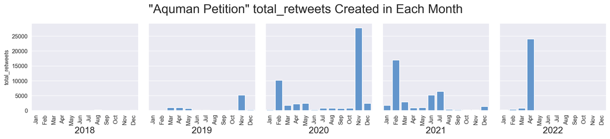

```python
df_metrics_month = (
    df_daily_metrics.groupby(['month', 'year'])[['total_retweets', 'like_count', 'reply_count']]
    .sum().reset_index()
)
helpers.facet_day_month(df_metrics_month, "month", "total_retweets", facet_on='year', n_col=5)
```

## Metrics Vs Time

> > - Retweets
> > - **Likes**
> > - Replies

## Daily Metrics (Peak Likes)

```python
df_daily_metrics.sort_values('like_count', ascending=False).head(10)
```

|  | date | year | month | dayofmonth | n_tweets | by_#accounts | total_retweets | like_count | reply_count |
| --- | --- | --- | --- | --- | --- | --- | --- | --- | --- |
| 1100 | 2022-04-28 | 2022 | Apr | 28 | 3231 | 3067 | 19208.0 | 129141.0 | 2035.0 |
| 694 | 2021-02-28 | 2021 | Feb | 28 | 494 | 470 | 14106.0 | 105434.0 | 954.0 |
| 586 | 2020-11-12 | 2020 | Nov | 12 | 3197 | 2902 | 7044.0 | 32154.0 | 1421.0 |
| 846 | 2021-07-30 | 2021 | Jul | 30 | 112 | 109 | 5256.0 | 14052.0 | 3051.0 |
| 302 | 2020-02-02 | 2020 | Feb | 2 | 1654 | 1597 | 3288.0 | 11527.0 | 187.0 |
| 1096 | 2022-04-24 | 2022 | Apr | 24 | 75 | 69 | 1706.0 | 11259.0 | 425.0 |
| 580 | 2020-11-06 | 2020 | Nov | 6 | 849 | 748 | 5442.0 | 10344.0 | 214.0 |
| 692 | 2021-02-26 | 2021 | Feb | 26 | 78 | 76 | 1513.0 | 9965.0 | 118.0 |
| 815 | 2021-06-29 | 2021 | Jun | 29 | 98 | 85 | 2510.0 | 8851.0 | 197.0 |
| 581 | 2020-11-07 | 2020 | Nov | 7 | 1565 | 1387 | 2345.0 | 7606.0 | 162.0 |

## HeatMap For "Aquaman Petition Links" Tweets Likes

```python
# importlib.reload(helpers)
```

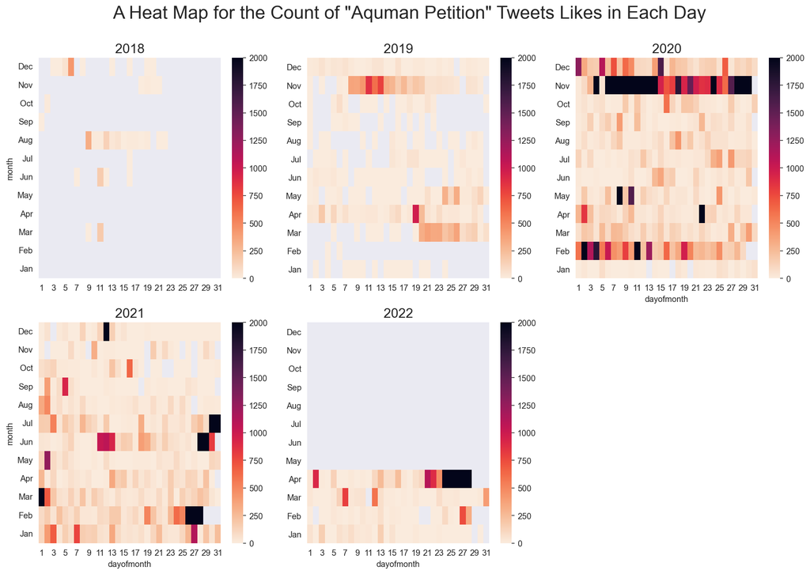

```python
title = 'A Heat Map for the Count of "Aquman Petition" Tweets Likes in Each Day'
helpers.facet_heat(df_daily_metrics, title, heat_col='like_count', n_col=3, vmax=2000)
```

## "Aquaman Petition Links" Tweets Likes Over Years

```python
df_years_likes = df_daily_metrics.groupby('year')['like_count'].sum().reset_index()
```

```python
helpers.bar(df_years_likes, "year", "like_count", "Number of 'Aquaman Petition Links' Likes over Years", text=0, margin=25000)
```

[figure not shown]

## "Aquaman Petition Links" Likes On Each Month

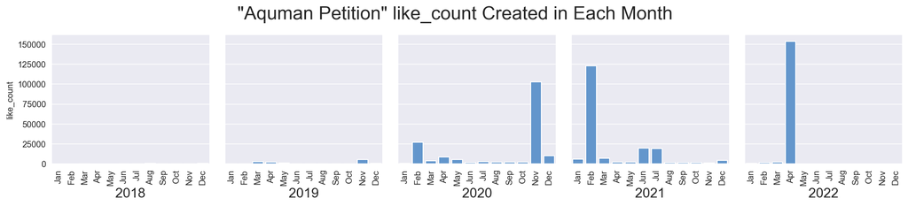

```python
helpers.facet_day_month(df_metrics_month, "month", "like_count", facet_on='year', n_col=5)
```

## Metrics Vs Time

> > - Retweets
> > - Likes
> > - **Replies**

## Daily Metrics (Peak Replies)

```python
df_daily_metrics.sort_values('reply_count', ascending=False).head(10)
```

|  | date | year | month | dayofmonth | n_tweets | by_#accounts | total_retweets | like_count | reply_count |
| --- | --- | --- | --- | --- | --- | --- | --- | --- | --- |
| 846 | 2021-07-30 | 2021 | Jul | 30 | 112 | 109 | 5256.0 | 14052.0 | 3051.0 |
| 1100 | 2022-04-28 | 2022 | Apr | 28 | 3231 | 3067 | 19208.0 | 129141.0 | 2035.0 |
| 586 | 2020-11-12 | 2020 | Nov | 12 | 3197 | 2902 | 7044.0 | 32154.0 | 1421.0 |
| 694 | 2021-02-28 | 2021 | Feb | 28 | 494 | 470 | 14106.0 | 105434.0 | 954.0 |
| 695 | 2021-03-01 | 2021 | Mar | 1 | 161 | 148 | 1945.0 | 3805.0 | 693.0 |
| 587 | 2020-11-13 | 2020 | Nov | 13 | 2493 | 2292 | 1456.0 | 6018.0 | 509.0 |
| 1096 | 2022-04-24 | 2022 | Apr | 24 | 75 | 69 | 1706.0 | 11259.0 | 425.0 |
| 847 | 2021-07-31 | 2021 | Jul | 31 | 75 | 68 | 338.0 | 2003.0 | 417.0 |
| 601 | 2020-11-27 | 2020 | Nov | 27 | 339 | 316 | 326.0 | 1564.0 | 288.0 |
| 90 | 2019-04-19 | 2019 | Apr | 19 | 79 | 62 | 471.0 | 973.0 | 226.0 |

## HeatMap For "Aquaman Petition Links" Tweets Replies

```python
# importlib.reload(helpers)
```

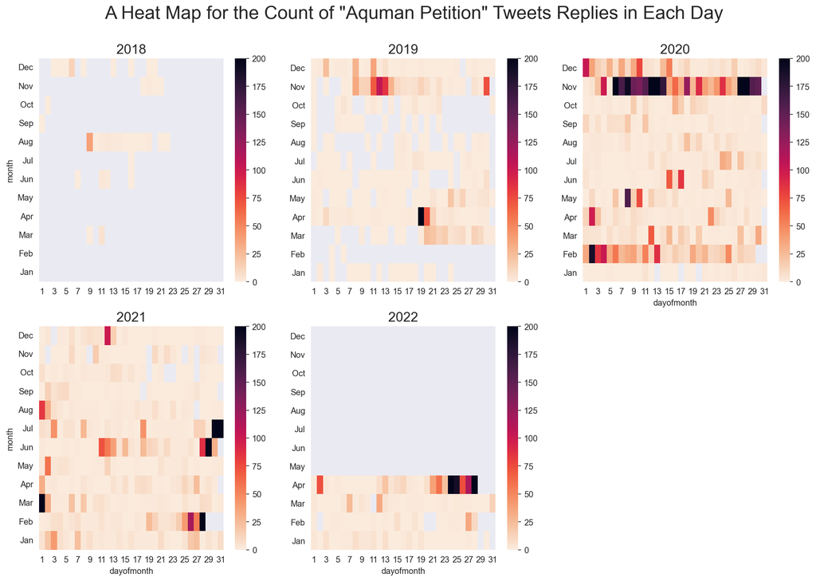

```python
title = 'A Heat Map for the Count of "Aquman Petition" Tweets Replies in Each Day'
helpers.facet_heat(df_daily_metrics, title, heat_col='reply_count', n_col=3, vmax=200)
```

## "Aquaman Petition Links" Tweets Replies Over Years

```python
df_years_replies = df_daily_metrics.groupby('year')['reply_count'].sum().reset_index()
```

```python
helpers.bar(df_years_replies, "year", "reply_count", "Number of 'Aquaman Petition Links' Replies over Years", text=0, margin=2000)
```

[figure not shown]

## "Aquaman Petition Links" Replies On Each Month

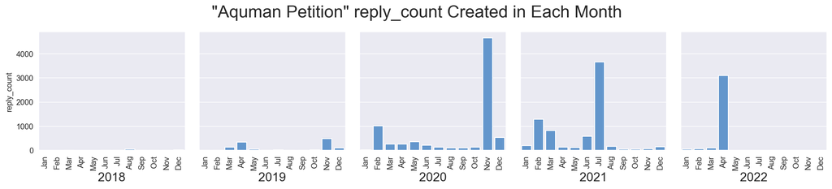

```python
helpers.facet_day_month(df_metrics_month, "month", "reply_count", facet_on='year', n_col=5)
```

## Tweets Metrics

> > - Metrics Vs Time
> > - **Top Retweeted Tweets**
> > - Tweets with Most Likes
> > - Tweets with Most Replies

#### Retweets

A count of how many times the Tweet has been Retweeted.  
Please note: This does not include Quote Tweets (“Retweets with comment”).

#### Quote Tweets

A count of how many times the Tweet has been Retweeted with a new comment (message).  
Please note: This does not include Retweets.

To get the “Retweets and comments” total as displayed on the Twitter clients, simply add retweet_count and quote_count.  
This will return the total count of Quote Tweets. There are no Quote Tweets from a paid context so all Quote Tweets are organic.

> - **total_retweets:** is the total retweet count (Retweets + Quote Tweets)

```python
top_retweet = aquaman_petition.sort_values('total_retweets', ascending=False)
with pd.option_context('display.max_colwidth', None):
    display(top_retweet[['text', 'total_retweets', 'reply_count', 'like_count', 'date', 'username', 'days_diff']].head(15))
```

|  | text | total_retweets | reply_count | like_count | date | username | days_diff |
| --- | --- | --- | --- | --- | --- | --- | --- |
| 1695958 | la pétition pour exclure amber heard du second film aquaman a dépassé les 2 millions de signatures.\n\n🔗: https://t.co/dj3wftglqe https://t.co/yrjychmnlq | 4999.0 | 299.0 | 35472.0 | 2022-04-28 | Infos Séries | 1937 |
| 836080 | so if amber heard is really fired from aquaman 2 (and believe me, i really hope she is) may i suggest mera’s replacement... https://t.co/lusgppgxwf | 4526.0 | 274.0 | 33708.0 | 2021-02-28 | 🎄 Colin 🐻‍❄️ | 3266 |
| 1696491 | la pétition pour exclure amber heard de aquaman 2. deja 2 millions de signatures. https://t.co/gcugpisrne | 4204.0 | 160.0 | 37850.0 | 2022-04-28 | 🔰Lesmeilleurescenes®️ 🎥 | 2136 |
| 1692581 | while remove amber heard is trending, a reminder that it is not just about her role in aquaman 2 &amp; her endorsement of l'oréal. \nglobal organisations like aclu &amp; un's human rights commission s… | 3017.0 | 339.0 | 11492.0 | 2022-04-28 | 𝐀𝐲𝐞𝐬𝐡𝐚 | 2470 |
| 485149 | more than 500k people have signed a petition to have amber heard removed from aquaman for abusing johnny depp. yet warner bros. asked johnny to quit fantastic beasts and amber heard will be in aquaman… | 2938.0 | 56.0 | 3824.0 | 2020-11-06 | Mango | 1433 |
| 593861 | over 1m people have signed a petition to remove amber heard from 'aquaman 2' https://t.co/ma06smva6y | 2937.0 | 506.0 | 13515.0 | 2020-11-12 | Fandom | 4989 |
| 124243 | 조니 뎁 추종자들의 엠버 허드를 &lt;아쿠아맨 2&gt;에서 빼라는 청원에 대응해, 엠버 팬들이 엠버 지지 청원을 올렸습니다. 이메일만으로 익명 참가 가능하니 시간되시는 분들은 참여해주세요! #wearewithyouamberheard\nwe support amber heard in aquaman 2 - sign the petition! https://t.… | 2866.0 | 2.0 | 393.0 | 2019-11-11 | justme | 2232 |
| 836002 | me when amber heard gets fired from #aquaman2: https://t.co/lwatooenpb | 2456.0 | 76.0 | 15633.0 | 2021-02-28 | Red Ranger Chris | 1145 |
| 836273 | just heard 'amber heard' has been fired from aquaman 2. anyway, all i wanna say is... https://t.co/0rtwvgyhxy | 2042.0 | 48.0 | 17025.0 | 2021-02-28 | Akash Bhadauria | 387 |
| 1088217 | peter safran says amber heard was never going to be fired from ‘aquaman and the lost kingdom’. \n\n“one is not unaware of what is going on in the twitter-verse, but that doesn’t mean you have to react… | 2036.0 | 884.0 | 3652.0 | 2021-07-30 | DiscussingFilm | 1767 |
| 1048149 | johnny depp has been removed from his upcoming projects but amber heard is still leading actress in aquaman 2. @wbpictures don't be so partial atleast respect an actor for his acting skills. #justicef… | 1964.0 | 106.0 | 7257.0 | 2021-06-29 | Ankeshkumar sharma | 419 |
| 844973 | amber heard is still playing mera in 'aquaman 2' 🔱\n\nthe rumor that she was fired is false\n\n(via @theryanparker) https://t.co/lixfxtvktb | 1758.0 | 597.0 | 3070.0 | 2021-03-01 | Culture Crave 🍿 | 1196 |
| 1693964 | over 2 million signatures want to remove amber heard from aquaman 2 don’t be shy keep it going https://t.co/iq6tfnglbk | 1751.0 | 109.0 | 13794.0 | 2022-04-28 | ɢʀᴇᴛᴄʜᴇɴ ᴀᴅᴇʟʟᴇ | 3430 |
| 156986 | me waiting for amber heard to be fired from playing mera in aquaman 2, then also knowing it’s never going to happen because apparently men can’t be abused too? 🤷🏻‍♀️ she ruined his career and now we a… | 1709.0 | 52.0 | 6709.0 | 2020-02-02 | ImProbablyManic | 1240 |
| 1693170 | 2 million sign petition seeking amber heard's removal from 'aquaman 2' https://t.co/kw94om3d7u https://t.co/yvwtrqywup | 1627.0 | 332.0 | 10392.0 | 2022-04-28 | NDTV News feed | 4517 |

```python
helpers.barh(top_retweet[['tweet_id', 'total_retweets']].head(15),
             'Top Retweeted Tweets with "aquaman petition links"', c='red')
```

[figure not shown]

```python
top_retweet.text.head(15).value_counts()
```

```
la pétition pour exclure amber heard du second film aquaman a dépassé les 2 millions de signatures.\n\n🔗: https://t.co/dj3wftglqe https://t.co/yrjychmnlq                                                                                                                                                   …
so if amber heard is really fired from aquaman 2 (and believe me, i really hope she is) may i suggest mera’s replacement... https://t.co/lusgppgxwf                                                                                                                                                         …
la pétition pour exclure amber heard de aquaman 2. deja 2 millions de signatures. https://t.co/gcugpisrne                                                                                                                                                                                                   …
while remove amber heard is trending, a reminder that it is not just about her role in aquaman 2 &amp; her endorsement of l'oréal. \nglobal organisations like aclu &amp; un's human rights commission still support her. she's still on their offical pages. think about that\n#amberheardisaliar https://t…
more than 500k people have signed a petition to have amber heard removed from aquaman for abusing johnny depp. yet warner bros. asked johnny to quit fantastic beasts and amber heard will be in aquaman 2. \nwhere is the justice?!\n#justiceforjohnnydepp \n#boycottfantasticbeasts https://t.co/x8upg4yi0…
over 1m people have signed a petition to remove amber heard from 'aquaman 2' https://t.co/ma06smva6y                                                                                                                                                                                                        …
조니 뎁 추종자들의 엠버 허드를 &lt;아쿠아맨 2&gt;에서 빼라는 청원에 대응해, 엠버 팬들이 엠버 지지 청원을 올렸습니다. 이메일만으로 익명 참가 가능하니 시간되시는 분들은 참여해주세요! #wearewithyouamberheard\nwe support amber heard in aquaman 2 - sign the petition! https://t.co/ataa77qnfi                                                                                       …
me when amber heard gets fired from #aquaman2: https://t.co/lwatooenpb                                                                                                                                                                                                                                      …
just heard 'amber heard' has been fired from aquaman 2. anyway, all i wanna say is... https://t.co/0rtwvgyhxy                                                                                                                                                                                               …
peter safran says amber heard was never going to be fired from ‘aquaman and the lost kingdom’. \n\n“one is not unaware of what is going on in the twitter-verse, but that doesn’t mean you have to react to it… you have to do what’s right for the film.”\n\n(source: deadline) https://t.co/kvw0m1ebai    …
johnny depp has been removed from his upcoming projects but amber heard is still leading actress in aquaman 2. @wbpictures don't be so partial atleast respect an actor for his acting skills. #justiceforjohnnydepp https://t.co/mcs55ufjrw                                                                …
amber heard is still playing mera in 'aquaman 2' 🔱\n\nthe rumor that she was fired is false\n\n(via @theryanparker) https://t.co/lixfxtvktb                                                                                                                                                                 …
over 2 million signatures want to remove amber heard from aquaman 2 don’t be shy keep it going https://t.co/iq6tfnglbk                                                                                                                                                                                      …
me waiting for amber heard to be fired from playing mera in aquaman 2, then also knowing it’s never going to happen because apparently men can’t be abused too? 🤷🏻‍♀️ she ruined his career and now we are after hers. i hope she is arrested.  #justiceforjohnnydepp https://t.co/s6gdytrji5               …
2 million sign petition seeking amber heard's removal from 'aquaman 2' https://t.co/kw94om3d7u https://t.co/yvwtrqywup                                                                                                                                                                                      …
Name: text, dtype: int64
```

```python
top_retweet.username.head(15)
```

```
1695958               Infos Séries
836080                🎄 Colin 🐻‍❄️
1696491    🔰Lesmeilleurescenes®️ 🎥
1692581                     𝐀𝐲𝐞𝐬𝐡𝐚
485149                       Mango
593861                      Fandom
124243                      justme
836002            Red Ranger Chris
836273             Akash Bhadauria
1088217             DiscussingFilm
1048149         Ankeshkumar sharma
844973             Culture Crave 🍿
1693964            ɢʀᴇᴛᴄʜᴇɴ ᴀᴅᴇʟʟᴇ
156986             ImProbablyManic
1693170             NDTV News feed
Name: username, dtype: object
```

```python
tweets[tweets.username == 'Le Cinéphiles'].text.value_counts().head()
```

```
breaking: amber heard reportedly grew a mustache after filming and is contractually obligated to keep it for her next film. the ‘aquaman’ reshoots will digitally remove her mustache using cgi. https://t.co/sbm0khiixn    1
breaking: warner bros officially announces that johnny depp will play mera in ‘aquaman 2,’ replacing amber heard. https://t.co/fhywf8hqu0                                                                                   1
breaking: amber heard has been cast as grindelwald in ‘fantastic beasts 3.’ https://t.co/wmgcjscena                                                                                                                         1
Name: text, dtype: int64
```

```python
helpers.contr_peaks(tweets, "Le Cinéphiles", n=30, threshold=0)
```

```
total number of tweets by "Le Cinéphiles": 3
```

[figure not shown]

```python
tweets[tweets.username == 'S'].text.value_counts().head(20)
```

```
#justiceforjohnnydepp                                                                                                                                                                                                                                                                        3
amber heard                                                                                                                                                                                                                                                                                  2
amber heard ni bodo gak ek. disebabkan kontroversi kau la johnny dah tak cast untuk fantastic beast.                                                                                                                                                                                         1
amber heard trying to use “i did not punch you, i was just hitting you” as an excuse after repeatedly hitting her man in the face is batty as hell                                                                                                                                           1
johnny depp’s trial proves that society is uncomfortable with admitting that men are victims of domestic violence and that drugs, dysfunction &amp; foul language doesn’t always equate to wife beating. childhood trauma will make us normalize the worst behavior #justiceforjohnnydepp    1
her şeye rağmen eskiden aşık olduğu kadın hakkında tek kötü bir şey bile söylemedi, başkalarının yapamadığını yapıp o mahkemede duygularının arkasında olduğunu savundun ya harika bir adamsın sen #justiceforjohnnydepp                                                                     1
in this trial, even after recounting horrific instances of abuse he suffered, it took an audio of him being on the verge of self-harm to make him break. he knows how broken he was at the end of that abusive relationship. he never deserved that. #johnnydepp #justiceforjohnnydepp       1
that audio made him fucking cry. he was the one in pain. he was begging for a way out of that abuse. how dare she think recording a man in a vulnerable state is ever okay. disgusting #johnnydepp #justiceforjohnnydepp                                                                     1
he’s obviously upset by this audio. the fact she was recording him while he was emotionally destroyed. he was begging for a way out and nearly/did resort to self harming. she’s horrible.  #justiceforjohnnydepp                                                                            1
“officer square head” fuck off 😭😭😭😭😭😭😭😭😭😭😭😭😭😭😭😭😭😭😭😭😭😭😭😭😭😭 #justiceforjohnnydepp                                                                                                                                                                                                              1
i’m sorry... if you want to see how innocent johnny depp is please watch his cross examination. they have out of context texts and audio of her admitting to hitting him. thats it. #justiceforjohnnydepp                                                                                    1
on that audio johnny clearly says “what if i show them this... or this... or this...” i presume he was pointing to injuries. she’s insane, her tone was crazy almost psychopathic...   \n\n#justiceforjohnnydepp                                                                             1
wait... that audio just confirms she did throw the can of mineral spirits at him!!!  #justiceforjohnnydepp                                                                                                                                                                                   1
amber heard is the reham khan of hollywood                                                                                                                                                                                                                                                   1
je suis fascinée par ce procès ça paraît irréel #justiceforjohnnydepp                                                                                                                                                                                                                        1
somebody called amber heard is promoting (unsuccessfully it appears) the multi-million dollar usaid-funded #regimechange ngo, sams; principal suspects behind the #omrandaqneesh scam, #khansheikoun and #douma. https://t.co/snnaot44z1                                                     1
amber heard is prime example of white women crocodile tears                                                                                                                                                                                                                                  1
fuck amber heard me and all my girls hate amber heard. yaa heard me                                                                                                                                                                                                                          1
is this the moaning video??  #justiceforjohnnydepp                                                                                                                                                                                                                                           1
at the end of the day, truth always wins #justiceforjohnnydepp                                                                                                                                                                                                                               1
Name: text, dtype: int64
```

```python
helpers.contr_peaks(tweets, "S", n=2, threshold=0)
```

```
total number of tweets by "S": 124
```

[figure not shown]

## Tweets Metrics

> > - Metrics Vs Time
> > - Top Retweeted Tweets
> > - **Tweets with Most Likes**
> > - Tweets with Most Replies

```python
top_liked = aquaman_petition.sort_values('like_count', ascending=False)
with pd.option_context('display.max_colwidth', None):
    display(top_retweet[['text', 'like_count', 'reply_count', 'total_retweets', 'date', 'username', 'days_diff']].head(15))
```

[output not shown]

```python
helpers.barh(top_liked[['tweet_id', 'like_count']].head(15),
             'Top Liked Tweets with "aquaman petition links"', c='red')
```

[figure not shown]

```python
top_liked.username.head(15)
```

```
1696491    🔰Lesmeilleurescenes®️ 🎥
1695958               Infos Séries
836080                🎄 Colin 🐻‍❄️
836273             Akash Bhadauria
836002            Red Ranger Chris
1693964            ɢʀᴇᴛᴄʜᴇɴ ᴀᴅᴇʟʟᴇ
593861                      Fandom
836821                      LynneG
836306                      Rishi💀
1692581                     𝐀𝐲𝐞𝐬𝐡𝐚
1568820                   _Rott!🕊️
1693170             NDTV News feed
1048149         Ankeshkumar sharma
156986             ImProbablyManic
590329             Culture Crave 🍿
Name: username, dtype: object
```

## Tweets Metrics

> > - Metrics Vs Time
> > - Top Retweeted Tweets
> > - Tweets with Most Likes
> > - **Tweets with Most Replies**

```python
top_replies = aquaman_petition.sort_values('reply_count', ascending=False)
with pd.option_context('display.max_colwidth', None):
    display(top_retweet[['text', 'reply_count', 'like_count', 'total_retweets', 'date', 'username', 'days_diff']].head(15))
```

[output not shown]

```python
helpers.barh(top_replies[['tweet_id', 'reply_count']].head(15),
             '"aquaman petition links" Tweets with Most Replies', c='red')
```

[figure not shown]

```python
top_replies.username.head(15)
```

```
1088217          DiscussingFilm
844973          Culture Crave 🍿
1089460                GameSpot
593861                   Fandom
1568820                _Rott!🕊️
1089241    Entertainment Weekly
1089717                  Fandom
1092818                GameSpot
1692581                  𝐀𝐲𝐞𝐬𝐡𝐚
1693170          NDTV News feed
1695958            Infos Séries
836080             🎄 Colin 🐻‍❄️
1090360               Pop Crave
660577                  TheWrap
590329          Culture Crave 🍿
Name: username, dtype: object
```

```python
tweets[tweets.username == 'DiscussingFilm'].text.value_counts().head()
```

```
dc’s ‘aquaman’ will reportedly diverge from comic canon, and will make dolph lundgren's king nereus and amber heard's mera father and daughter. (via @aquamanshrine) https://t.co/gpkbwztq2o                                                                                                                …
amber heard is set to join the cast of 'gully', with the film marking the directorial debut of nabil elderkin. the film is set in a dystopian version of los angeles and follows three teenagers, all victims of childhood trauma, who are running a riot. (source: @variety) https://t.co/itaqjyqxga       …
amber heard has joined the cast of bow and arrow entertainment’s ‘her smell’. (source: @variety) https://t.co/h6iktsshjr                                                                                                                                                                                    …
amber heard has explained why she almost turned down playing mera in the dceu:\n\n“i had a limited experience, or exposure, to women in that world and then zack snyder explained this badass, kickass warrior queen to me and then i thought ‘sword and a crown, okay’” (source: @etnow) https://t.co/mdqnq…
amber heard has said she would love to team up with gal gadot’s wonder woman in a future dc film. (source: https://t.co/llozrwobsu) https://t.co/6fqiezmicc                                                                                                                                                 …
Name: text, dtype: int64
```

```python
helpers.contr_peaks(tweets, "DiscussingFilm", n=30, threshold=0)
```

```
total number of tweets by "DiscussingFilm": 14
```

[figure not shown]

```python
tweets[tweets.username == 'Culture Crave 🍿'].text.value_counts().head()
```

```
amber heard says she wants to see mera and wonder woman team up and 'kick some ass'\n\n(via @celebfanfest) https://t.co/owkb7ne65m                                                               1
amber heard is currently shooting new scenes for zack snyder's 'justice league' 🔱\n\n(via @thr) https://t.co/dbdnzj5fxe                                                                          1
over 1m people have signed a petition to remove amber heard from 'aquaman 2' https://t.co/yem8gxketd                                                                                             1
amber heard confirms she will return for 'aquaman 2' 🔱\n\n(via @ew) https://t.co/dlzeg1nkwe                                                                                                      1
amber heard has wrapped reshoots on 'zack snyder's justice league' and is hyped for fans to see it 🔱\n\n'i just love nerds. i fucking love nerds'\n\n(via @comicbook) https://t.co/vfxmghkoyk    1
Name: text, dtype: int64
```

```python
helpers.contr_peaks(tweets, "Culture Crave 🍿", n=30, threshold=0)
```

```
total number of tweets by "Culture Crave 🍿": 10
```

[figure not shown]

## Users Tweets Metrics

> - Tweets Metrics
> - **Users Tweets Metrics**
> - ------------------------------
> - Duration After Account Creation
> - Tweets Created OVER TIME
> - Peak Dates
> - ------------------------------
> - Tweets on Peaks
> - Most Repeated Tweets
> - Same Text Same Date
> - ------------------------------
> - Unverified Accounts
> - Deleted or Banned
> - Default Profile Image
> - Users Metrics

## Users Tweets Metrics

> > - **Top Retweeted Users**
> > - Users with Most Likes
> > - Users with Most Replies

#### Retweets

A count of how many times the Tweet has been Retweeted.  
Please note: This does not include Quote Tweets (“Retweets with comment”).

#### Quote Tweets

A count of how many times the Tweet has been Retweeted with a new comment (message).  
Please note: This does not include Retweets.

To get the “Retweets and comments” total as displayed on the Twitter clients, simply add retweet_count and quote_count.  
This will return the total count of Quote Tweets. There are no Quote Tweets from a paid context so all Quote Tweets are organic.

> - **total_retweets:** is the total retweet count (Retweets + Quote Tweets)

```python
aquaman_petition.head(1)
```

|  | n_statuses | created_at | user_description | user_created_at | user_id | username | is_verified | user_location | n_followers | user_url | lang | profile_banner_url | profile_image_url | text | n_friends | tweet_id | user_screen_name | date | year | month | dayofmonth | hour | diff | days_diff | minutes_diff | retweet_count | reply_count | like_count | quote_count | … |
| --- | --- | --- | --- | --- | --- | --- | --- | --- | --- | --- | --- | --- | --- | --- | --- | --- | --- | --- | --- | --- | --- | --- | --- | --- | --- | --- | --- | --- | --- | --- |
| 4434 | 2860 | 2018-03-16 21:52:09 | I pretend to be sophisticated, but really I'm ... | 2016-06-29 18:06:35 | 748216104565235712 | Morgan | False | NaN | 177 | https://t.co/7NiXfsBF9J | en | https://pbs.twimg.com/profile_banners/74821610... | http://pbs.twimg.com/profile_images/1202278135... | can't find the receipts but he also defended j... | 656 | 974765287080853508 | mdragonfly89 | 2018-03-16 | 2018 | Mar | 16 | 21 | 625 days 03:45:34 | 625 | 225.57 | 0.0 | 0.0 | 6.0 | 0.0 | … |

```python
top_retweet_u = (
    aquaman_petition.groupby(['user_id', 'username', 'user_created_at'], as_index=False)
    ['total_retweets', 'like_count', 'reply_count'].sum()
    .sort_values('total_retweets', ascending=False)
)

top_retweet_u.head(15)
```

|  | user_id | username | user_created_at | total_retweets | like_count | reply_count |
| --- | --- | --- | --- | --- | --- | --- |
| 33507 | 817437085191827456 | Infos Séries | 2017-01-06 18:26:03 | 5192.0 | 35764.0 | 358.0 |
| 28953 | 531577673 | 🎄 Colin 🐻‍❄️ | 2012-03-20 19:42:58 | 4526.0 | 33708.0 | 274.0 |
| 31622 | 745369183517548544 | 🔰Lesmeilleurescenes®️ 🎥 | 2016-06-21 21:33:56 | 4204.0 | 37850.0 | 160.0 |
| 12955 | 1332121 | Fandom | 2007-03-17 03:28:55 | 3670.0 | 15512.0 | 887.0 |
| 24480 | 3309371255 | TheRealLauraB🌊⚔️ | 2015-06-05 15:21:16 | 3641.0 | 10903.0 | 467.0 |
| 33179 | 805207070270259201 | Mango | 2016-12-04 00:28:20 | 3137.0 | 4858.0 | 132.0 |
| 36781 | 932786452739407872 | Culture Crave 🍿 | 2017-11-21 01:43:15 | 3024.0 | 9236.0 | 758.0 |
| 24875 | 3389710995 | 𝐀𝐲𝐞𝐬𝐡𝐚 | 2015-07-23 18:58:08 | 3017.0 | 11492.0 | 339.0 |
| 17039 | 1920027500 | justme | 2013-09-30 13:05:19 | 2866.0 | 393.0 | 2.0 |
| 27616 | 4583281223 | Support Johnny Depp ♡ Stream City of Lies | 2015-12-23 23:22:52 | 2488.0 | 11016.0 | 240.0 |
| 37264 | 950895831313510401 | Red Ranger Chris | 2018-01-10 01:03:27 | 2456.0 | 15633.0 | 76.0 |
| 1862 | 1063791963378315264 | Kirst💖 | 2018-11-17 13:52:23 | 2220.0 | 6698.0 | 92.0 |
| 7843 | 1225378925594869761 | Akash Bhadauria | 2020-02-06 11:24:26 | 2042.0 | 17025.0 | 48.0 |
| 32561 | 780460754910732288 | DiscussingFilm | 2016-09-26 17:35:19 | 2036.0 | 3652.0 | 884.0 |
| 9209 | 1257551453628981248 | Ankeshkumar sharma | 2020-05-05 06:03:35 | 1964.0 | 7257.0 | 106.0 |

```python
# # Check duplicates in user_id --> users that changed their usernames
# top_retweet_u.duplicated(subset='user_id').sum()
```

```python
# top_retweet_u[top_retweet_u.user_id.duplicated()]
```

```python
helpers.barh(top_retweet_u[['username', 'total_retweets']].head(15),
             'Top Retweeted Users with "aquaman petition links"', c='red')
```

[figure not shown]

```python
aquaman_petition[aquaman_petition.username == 'Infos Séries'].text.value_counts().head()
```

```
amber heard s'exprime sur la pétition à plus d'un million de signatures pour demander son départ du film 'aquaman 2' :\n\n''les rumeurs et campagnes sur les réseaux sociaux ne dictent pas les décisions de casting car elles n'ont aucun fondement dans la réalité." https://t.co/0cqrneqqqe    1
la pétition pour exclure amber heard du second film aquaman a dépassé les 2 millions de signatures.\n\n🔗: https://t.co/dj3wftglqe https://t.co/yrjychmnlq                                                                                                                                         1
Name: text, dtype: int64
```

```python
helpers.contr_peaks(tweets, "Infos Séries", n=9, threshold=0)
```

```
total number of tweets by "Infos Séries": 63
```

[figure not shown]

### 🎄 Colin 🐻‍❄️

```python
tweets[tweets.username == '🎄 Colin 🐻‍❄️'].text.value_counts().head(20)
```

```
so if amber heard is really fired from aquaman 2 (and believe me, i really hope she is) may i suggest mera’s replacement... https://t.co/lusgppgxwf                                                                                                                                               1
so i genuinely did not expect this tweet to do go beyond my handful of friends\n\ni never meant to start any arguments about johnny depp &amp; amber heard\n\ni just really liked the idea of seeing jason momoa and emila clarke back acting together \n\n❤️ please be kind to one another ❤️    1
Name: text, dtype: int64
```

```python
helpers.contr_peaks(tweets, "🎄 Colin 🐻‍❄️", n=5, threshold=0)
```

```
total number of tweets by "🎄 Colin 🐻‍❄️": 2
```

[figure not shown]

### 🔰Lesmeilleurescenes®️ 🎥

```python
aquaman_petition[aquaman_petition.username == '🔰Lesmeilleurescenes®️ 🎥'].text.value_counts().head(20)
```

```
la pétition pour exclure amber heard de aquaman 2. deja 2 millions de signatures. https://t.co/gcugpisrne    1
Name: text, dtype: int64
```

```python
helpers.contr_peaks(tweets, "🔰Lesmeilleurescenes®️ 🎥", n=10, threshold=0)
```

```
total number of tweets by "🔰Lesmeilleurescenes®️ 🎥": 9
```

[figure not shown]

## Users Tweets Metrics

> > - Top Retweeted Users
> > - **Users with Most Likes**
> > - Users with Most Replies

```python
top_liked_u = top_retweet_u.sort_values('like_count', ascending=False)
top_liked_u.head(15)
```

|  | user_id | username | user_created_at | total_retweets | like_count | reply_count |
| --- | --- | --- | --- | --- | --- | --- |
| 31622 | 745369183517548544 | 🔰Lesmeilleurescenes®️ 🎥 | 2016-06-21 21:33:56 | 4204.0 | 37850.0 | 160.0 |
| 33507 | 817437085191827456 | Infos Séries | 2017-01-06 18:26:03 | 5192.0 | 35764.0 | 358.0 |
| 28953 | 531577673 | 🎄 Colin 🐻‍❄️ | 2012-03-20 19:42:58 | 4526.0 | 33708.0 | 274.0 |
| 7843 | 1225378925594869761 | Akash Bhadauria | 2020-02-06 11:24:26 | 2042.0 | 17025.0 | 48.0 |
| 37264 | 950895831313510401 | Red Ranger Chris | 2018-01-10 01:03:27 | 2456.0 | 15633.0 | 76.0 |
| 12955 | 1332121 | Fandom | 2007-03-17 03:28:55 | 3670.0 | 15512.0 | 887.0 |
| 38393 | 991924602 | ɢʀᴇᴛᴄʜᴇɴ ᴀᴅᴇʟʟᴇ | 2012-12-05 22:41:01 | 1751.0 | 13794.0 | 109.0 |
| 37195 | 948421868 | LynneG | 2012-11-14 20:15:43 | 1588.0 | 12687.0 | 133.0 |
| 28760 | 512966078 | Rishi💀 | 2012-03-03 09:02:31 | 1227.0 | 11629.0 | 27.0 |
| 24875 | 3389710995 | 𝐀𝐲𝐞𝐬𝐡𝐚 | 2015-07-23 18:58:08 | 3017.0 | 11492.0 | 339.0 |
| 13063 | 1337522797275459585 | _Rott!🕊️ | 2020-12-11 22:21:56 | 1613.0 | 11049.0 | 412.0 |
| 27616 | 4583281223 | Support Johnny Depp ♡ Stream City of Lies | 2015-12-23 23:22:52 | 2488.0 | 11016.0 | 240.0 |
| 24480 | 3309371255 | TheRealLauraB🌊⚔️ | 2015-06-05 15:21:16 | 3641.0 | 10903.0 | 467.0 |
| 37803 | 96900937 | NDTV News feed | 2009-12-15 03:10:27 | 1627.0 | 10392.0 | 332.0 |
| 36781 | 932786452739407872 | Culture Crave 🍿 | 2017-11-21 01:43:15 | 3024.0 | 9236.0 | 758.0 |

```python
helpers.barh(top_liked[['username', 'like_count']].head(15),
             'Users with Most Likes on "aquaman petition links" Tweets', c='red')
```

[figure not shown]

### Infos Séries

```python
aquaman_petition[aquaman_petition.username == 'Infos Séries'].text.value_counts().head(20)
```

```
amber heard s'exprime sur la pétition à plus d'un million de signatures pour demander son départ du film 'aquaman 2' :\n\n''les rumeurs et campagnes sur les réseaux sociaux ne dictent pas les décisions de casting car elles n'ont aucun fondement dans la réalité." https://t.co/0cqrneqqqe    1
la pétition pour exclure amber heard du second film aquaman a dépassé les 2 millions de signatures.\n\n🔗: https://t.co/dj3wftglqe https://t.co/yrjychmnlq                                                                                                                                         1
Name: text, dtype: int64
```

```python
helpers.contr_peaks(tweets, "Infos Séries", n=9, threshold=0)
```

```
total number of tweets by "Infos Séries": 63
```

[figure not shown]

### Akash Bhadauria

- This Account created on 2020-02-06

```python
aquaman_petition[aquaman_petition.username == 'Akash Bhadauria'].text.value_counts().head(20)
```

```
just heard 'amber heard' has been fired from aquaman 2. anyway, all i wanna say is... https://t.co/0rtwvgyhxy    1
Name: text, dtype: int64
```

```python
helpers.contr_peaks(tweets, "Akash Bhadauria", n=9, threshold=0)
```

```
total number of tweets by "Akash Bhadauria": 1
```

[figure not shown]

## Users Tweets Metrics

> > - Top Retweeted Users
> > - Users with Most Likes
> > - **Users with Most Replies**

```python
top_replies_u = top_retweet_u.sort_values('reply_count', ascending=False)
top_replies_u.head(15)
```

|  | user_id | username | user_created_at | total_retweets | like_count | reply_count |
| --- | --- | --- | --- | --- | --- | --- |
| 30855 | 7157132 | GameSpot | 2007-06-29 17:54:14 | 789.0 | 3822.0 | 898.0 |
| 12955 | 1332121 | Fandom | 2007-03-17 03:28:55 | 3670.0 | 15512.0 | 887.0 |
| 32561 | 780460754910732288 | DiscussingFilm | 2016-09-26 17:35:19 | 2036.0 | 3652.0 | 884.0 |
| 36781 | 932786452739407872 | Culture Crave 🍿 | 2017-11-21 01:43:15 | 3024.0 | 9236.0 | 758.0 |
| 24480 | 3309371255 | TheRealLauraB🌊⚔️ | 2015-06-05 15:21:16 | 3641.0 | 10903.0 | 467.0 |
| 13063 | 1337522797275459585 | _Rott!🕊️ | 2020-12-11 22:21:56 | 1613.0 | 11049.0 | 412.0 |
| 15970 | 16312576 | Entertainment Weekly | 2008-09-16 16:13:23 | 713.0 | 599.0 | 383.0 |
| 33507 | 817437085191827456 | Infos Séries | 2017-01-06 18:26:03 | 5192.0 | 35764.0 | 358.0 |
| 24875 | 3389710995 | 𝐀𝐲𝐞𝐬𝐡𝐚 | 2015-07-23 18:58:08 | 3017.0 | 11492.0 | 339.0 |
| 37803 | 96900937 | NDTV News feed | 2009-12-15 03:10:27 | 1627.0 | 10392.0 | 332.0 |
| 26246 | 3911239745 | Perez | 2015-10-09 18:29:57 | 90.0 | 480.0 | 309.0 |
| 28953 | 531577673 | 🎄 Colin 🐻‍❄️ | 2012-03-20 19:42:58 | 4526.0 | 33708.0 | 274.0 |
| 27329 | 4429003533 | Pop Crave | 2015-12-09 18:00:33 | 454.0 | 1571.0 | 258.0 |
| 14871 | 14892220 | Screen Rant | 2008-05-24 16:20:49 | 686.0 | 2487.0 | 252.0 |
| 27616 | 4583281223 | Support Johnny Depp ♡ Stream City of Lies | 2015-12-23 23:22:52 | 2488.0 | 11016.0 | 240.0 |

```python
helpers.barh(top_replies_u[['username', 'reply_count']].head(15),
             'Users with Most Replies on "aquaman petition links" Tweets', c='red')
```

[figure not shown]

### GameSpot

```python
tweets[tweets.username == 'GameSpot'].text.value_counts().head()
```

```
although aquaman 2 has not been officially greenlit by warner bros., amber heard says she'll return for the sequel, adding that the production hopes to get underway sometime in 2021. https://t.co/i1kraooib5    1
aquaman 2 filmmakers won't remove amber heard from the movie because of johnny depp fans. https://t.co/nevlomaww0 https://t.co/p5eoo0jdvt                                                                         1
aquaman 2 filmmakers won't remove amber heard from the movie because of johnny depp fans. https://t.co/ver63xlnc7 https://t.co/m3hvyhv0zx                                                                         1
amid controversy between johnny depp and amber heard, aquaman 2 filmmakers make it clear that the twitter-verse doesn't dictate the story they want to tell. https://t.co/eivblzy1e2 https://t.co/gqgksqmn1x      1
the johnny depp and amber heard saga continues... https://t.co/edk1salcia                                                                                                                                         1
Name: text, dtype: int64
```

```python
helpers.contr_peaks(tweets, "GameSpot", n=5, threshold=0)
```

```
total number of tweets by "GameSpot": 8
```

[figure not shown]

### Fandom

```python
tweets[tweets.username == 'Fandom'].text.value_counts().head()
```

```
jason momoa &amp; amber heard grace the @totalfilm november cover ahead of #aquaman release 🔱\n\n(via @creepypuppet)\n\nhttps://t.co/s7yyefytx9                                                                                                  1
#aquaman's amber heard is ready for a mera spinoff — 'i'd love to team up with wonder woman. that would be a kickass duo right there'\n\n(via @thr) https://t.co/k5bseckyim                                                                      1
amber heard shares a bts photo of mera above water while filming #aquaman https://t.co/p171ev6j1k                                                                                                                                                1
james marsden and amber heard are in talks to star in stephen king’s ‘the stand' series for cbs all access\n\n(via @collider | https://t.co/nbocbpoxby) https://t.co/eujew7r7nu                                                                  1
‘the stand’ confirms four actors for the cbs all access series: james marsden, amber heard, odessa young, and henry zaga will join the 10-episode series, which stephen king will write the finale for\n\n(via @ew | https://t.co/jgezpfdkhu)    1
Name: text, dtype: int64
```

```python
helpers.contr_peaks(tweets, "Fandom", n=30, threshold=0)
```

```
total number of tweets by "Fandom": 13
```

[figure not shown]

### DiscussingFilm

```python
tweets[tweets.username == 'DiscussingFilm'].text.value_counts().head()
```

```
dc’s ‘aquaman’ will reportedly diverge from comic canon, and will make dolph lundgren's king nereus and amber heard's mera father and daughter. (via @aquamanshrine) https://t.co/gpkbwztq2o                                                                                                                …
amber heard is set to join the cast of 'gully', with the film marking the directorial debut of nabil elderkin. the film is set in a dystopian version of los angeles and follows three teenagers, all victims of childhood trauma, who are running a riot. (source: @variety) https://t.co/itaqjyqxga       …
amber heard has joined the cast of bow and arrow entertainment’s ‘her smell’. (source: @variety) https://t.co/h6iktsshjr                                                                                                                                                                                    …
amber heard has explained why she almost turned down playing mera in the dceu:\n\n“i had a limited experience, or exposure, to women in that world and then zack snyder explained this badass, kickass warrior queen to me and then i thought ‘sword and a crown, okay’” (source: @etnow) https://t.co/mdqnq…
amber heard has said she would love to team up with gal gadot’s wonder woman in a future dc film. (source: https://t.co/llozrwobsu) https://t.co/6fqiezmicc                                                                                                                                                 …
Name: text, dtype: int64
```

```python
helpers.contr_peaks(tweets, "DiscussingFilm", n=30, threshold=0)
```

```
total number of tweets by "DiscussingFilm": 14
```

[figure not shown]

## Tweeting Duration After Account Creation

> - Tweets Metrics
> - Users Tweets Metrics
> - ------------------------------
> - **Duration After Account Creation**
> - Tweets Created OVER TIME
> - Peak Dates
> - ------------------------------
> - Tweets on Peaks
> - Most Repeated Tweets
> - Same Text Same Date
> - ------------------------------
> - Unverified Accounts
> - Deleted or Banned
> - Default Profile Image
> - Users Metrics

### Days and Hours Distribution

> > - **Distribution**
> > - Same Hour
> > - Same Day
> > - Same Week
> > - Same Month

```python
# mask = (aquaman_petition.days_diff == 0) & (aquaman_petition.minutes_diff <= 60)
# aquaman_petition[mask].shape[0]
```

```python
# mask = (aquaman_petition.days_diff == 0) & (aquaman_petition.minutes_diff <= 120)
# aquaman_petition[mask].shape[0]
```

https://stackoverflow.com/questions/69843435/python-how-to-create-bins-based-on-a-fixed-threshold

```python
diff_d = aquaman_petition[aquaman_petition.days_diff == 0]
diff_d['cluster'] = diff_d['minutes_diff'].floordiv(60).astype(int) + 1 # .factorize()[0]

diff_d_counts = diff_d.groupby('cluster').size().reset_index(name='n_tweets')
# diff_d_counts['n_tweets'] = diff_d_counts['n_tweets'].cumsum()
# diff_d_counts['cluster'] = diff_d_counts['cluster'] + 1 # not needed as we summed up 1 above
diff_d_counts.head()
```

|  | cluster | n_tweets |
| --- | --- | --- |
| 0 | 1 | 92 |
| 1 | 2 | 20 |
| 2 | 3 | 10 |
| 3 | 4 | 10 |
| 4 | 5 | 9 |

```python
print(f'\nTotal "aquaman petition" Tweets Within the same Day of Account Creation: {diff_d_counts.n_tweets.sum()}') # iloc[-1]
title = '"aquaman petition" Tweets Within the same Day of Account Creation'
helpers.bar_peaks(diff_d_counts, title, threshold=0, xlabel='Tweeting Duration After Account Creation (Hours)')
```

```
Total "aquaman petition" Tweets Within the same Day of Account Creation: 273
```

[figure not shown]

```python
mask = (aquaman_petition.days_diff == 0) & (aquaman_petition.minutes_diff <= 60)
aquaman_petition[mask].user_id.nunique()
```

```
83
```

```python
petition_diff_m = aquaman_petition[aquaman_petition.days_diff < 30]
petition_diff_count = petition_diff_m.groupby('days_diff').size().reset_index(name='n_tweets')
# petition_diff_m
```

```python
print(f'\nTotal "aquaman petition" Tweets Within the same month of Account Creation: {petition_diff_count.n_tweets.sum()}')
title = '"aquaman petition" Tweets Within the same month of Account Creation'
helpers.bar_peaks(petition_diff_count, title, threshold=0, xlabel='Tweeting Duration After Account Creation (Days)')
```

```
Total "aquaman petition" Tweets Within the same month of Account Creation: 2401
```

[figure not shown]

```python
mask = (aquaman_petition.days_diff == 0)
aquaman_petition[mask].user_id.nunique()
```

```
219
```

### Same Hour

> > - Distribution
> > - **Same Hour**
> > - Same Day
> > - Same Week
> > - Same Month

```python
mask = (aquaman_petition.days_diff == 0) & (aquaman_petition.minutes_diff <= 60)

same_hour = aquaman_petition[mask]
n_users = same_hour.user_id.nunique()
n_tweets = same_hour.shape[0]
print(f'The number of accounts tweeted with "aquaman petition links" the same hour they was created! ({n_users}) \nTweeted ({n_tweets}) Tweets')
```

```
The number of accounts tweeted with "aquaman petition links" the same hour they was created! (83)
Tweeted (92) Tweets
```

```python
same_hour.head()
```

|  | n_statuses | created_at | user_description | user_created_at | user_id | username | is_verified | user_location | n_followers | user_url | lang | profile_banner_url | profile_image_url | text | n_friends | tweet_id | user_screen_name | date | year | month | dayofmonth | hour | diff | days_diff | minutes_diff | retweet_count | reply_count | like_count | quote_count | … |
| --- | --- | --- | --- | --- | --- | --- | --- | --- | --- | --- | --- | --- | --- | --- | --- | --- | --- | --- | --- | --- | --- | --- | --- | --- | --- | --- | --- | --- | --- | --- |
| 127443 | 1 | 2019-11-29 03:40:59 | NaN | 2019-11-29 03:00:44 | 1200248042290601985 | jenneb7 | False | NaN | 1 | NaN | es | NaN | http://pbs.twimg.com/profile_images/1200248546... | dc entertainment: remove amber heard from aqua... | 9 | 1200258325121785857 | jenneb71 | 2019-11-29 | 2019 | Nov | 29 | 3 | 0 days 00:40:15 | 0 | 40.25 | 0.0 | 0.0 | 2.0 | 0.0 | … |
| 128607 | 313 | 2019-12-04 13:37:24 | NaN | 2019-12-04 13:19:41 | 1202215838616559618 | mary fakhoury | False | NaN | 2 | NaN | en | NaN | http://abs.twimg.com/sticky/default_profile_im... | dc entertainment: remove amber heard from aqua... | 4 | 1202220361179381761 | maryfakhoury3 | 2019-12-04 | 2019 | Dec | 4 | 13 | 0 days 00:17:43 | 0 | 17.72 | 0.0 | 0.0 | 0.0 | 0.0 | … |
| 132551 | 102 | 2020-01-11 13:41:09 | NaN | 2020-01-11 13:01:27 | 1215981952387440642 | DCU TV | False | NaN | 2 | NaN | en | https://pbs.twimg.com/profile_banners/12159819... | http://pbs.twimg.com/profile_images/1228251124... | petitions to getting amber heard removed from ... | 1 | 1215992040615530501 | fandom456732201 | 2020-01-11 | 2020 | Jan | 11 | 13 | 0 days 00:39:42 | 0 | 39.70 | 0.0 | 5.0 | 1.0 | 0.0 | … |
| 174786 | 9 | 2020-02-02 15:27:40 | NaN | 2020-02-02 15:26:56 | 1223990659809341441 | 啾啾 | False | NaN | 0 | NaN | en | NaN | http://pbs.twimg.com/profile_images/1223991789... | dc entertainment: remove amber heard from aqua... | 1 | 1223991381774888961 | a3sqaXG5zyylSGH | 2020-02-02 | 2020 | Feb | 2 | 15 | 0 days 00:00:44 | 0 | 0.73 | 0.0 | 0.0 | 0.0 | 0.0 | … |
| 178281 | 2 | 2020-02-02 17:25:35 | 双子少女 | 2020-02-02 17:11:28 | 1224017463622266880 | 酷儿橙 | False | 浙江, 中华人民共和国 | 3 | NaN | en | https://pbs.twimg.com/profile_banners/12240174... | http://pbs.twimg.com/profile_images/1224023014... | dc entertainment: remove amber heard from aqua... | 2 | 1224021053829070848 | horsetears | 2020-02-02 | 2020 | Feb | 2 | 17 | 0 days 00:14:07 | 0 | 14.12 | 0.0 | 0.0 | 0.0 | 0.0 | … |

```python
same_hour.username.isnull().sum()
```

```
0
```

> **NOTE:**
> - these accounts are not banned.

```python
image = "http://abs.twimg.com/sticky/default_profile_images/default_profile_normal.png"
same_hour_def = same_hour[same_hour['profile_image_url'] == image]
n_tweets = same_hour_def.shape[0]
n_users_def = same_hour_def.user_id.nunique()

print(f'\n({n_users_def}) users (with the default profile image) made a total of ({n_tweets}) "aquaman petition" tweets,\n in the same hour of account creation\n')
```

```
(21) users (with the default profile image) made a total of (23) "aquaman petition" tweets,
 in the same hour of account creation
```

```python
title = 'Peak contributions of the accounts tweeted "aquaman petition links" the same hour they were created'
df = same_hour.groupby('date').size().reset_index(name='n_tweets')
df.sort_values('n_tweets', ascending=False, inplace=True)
helpers.bar_peaks(df.head(2), title, threshold=0, xlabel='tweets Creation Date')
```

[figure not shown]

```python
helpers.bar_peaks(df[2:].head(3), title, threshold=0, xlabel='tweets Creation Date')
```

[figure not shown]

```python
same_hour.text.value_counts().head()
```

```
dc entertainment: remove amber heard from aquaman 2 - ¡firma la petición! https://t.co/4gijaruqou vía @changeorglatino                                               1
remove amber heard from aquaman 2 https://t.co/xyxhva82fh                                                                                                            1
warner brothers: keep amber heard in aquaman - sign the petition! https://t.co/psg2sg8ms8 via @change                                                                1
change.org : petitions to remove amber heard from aquaman perpetuates abuse towards women who speak up - sign the petition! https://t.co/atrvnruc8a via @change    1
dc entertainment: remove amber heard from aquaman 2 - sign the petition! https://t.co/11imskko2c via @cdnchange                                                      1
Name: text, dtype: int64
```

### Top users tweeted with "aquaman petition links" the same hour they were created!

```python
same_hour_users = same_hour.username.value_counts().reset_index().rename(columns={'index':'username', 'username':'n_tweets'})
title = 'Top users tweeted with "aquaman petition links" the same hour they were created!'
helpers.barh(same_hour_users.head(15), title, c='red') # , c=colors
```

[figure not shown]

```python
same_hour.username.value_counts().head()
```

```
Wonder Woman RSVP                    5
Queen Mera                           2
Winston Churchill aka Ralph White    2
CrisM                                2
Janet                                2
Name: username, dtype: int64
```

```python
same_hour.user_screen_name.value_counts().head()
```

```
RSVP85596737      5
MeraQueenDC       2
SirWChurchill1    2
CrisM53748301     2
Janet40877868     2
Name: user_screen_name, dtype: int64
```

## CrisM

- This account was created on 2020-11-06
- and tweeted 2 tweets on the same account creation hour (all contains aquaman petition links)

```python
tweets[(tweets['username'] == 'CrisM') & (tweets['date'] == '2020-11-06')].text.value_counts()
```

```
#justiceforjohnnydepp #johnnydeppisinnocent #johnnydeppismygrindelwald                                                                                                               1
all decent human beings who believe in justice: boycott warner brothers for removing johnny depp but keeping amber heard - sign the petition! https://t.co/mbjavpsucb via @change    1
dc entertainment: remove amber heard from aquaman 2 - sign the petition! https://t.co/edf26tjxjd via @change                                                                         1
#boycottwarnerbrothers #justiceforjohnnydepp #amberheardisanabuser #amberheardisaliar                                                                                                1
#justiceforjohhnydepp \n#johnnydeppismygrindelwald \n#johnnydeppisasurvivor \n#amberheardisanabuser \n#amberheardisaliar #amberhearddoesnotspeakforme                                1
#amberheardisaliar                                                                                                                                                                   1
Name: text, dtype: int64
```

```python
df_CrisM = tweets[tweets['username'] == 'CrisM']
df_CrisM.created_at.min(), df_CrisM.created_at.max()
```

```
(Timestamp('2020-11-06 17:59:02'), Timestamp('2021-02-12 19:11:06'))
```

```python
df_CrisM.user_created_at.iloc[0]
```

```
Timestamp('2020-11-06 17:50:35')
```

```python
df_CrisM.text.value_counts().head(60)
```

```
#justiceforjohnnydepp                                                                                                                                                                                                                                                                               3
#justiceforjohnnydepp #goshjohnnydepp                                                                                                                                                                                                                                                               2
#justiceforjohnnydepp #istandwithjohnnydepp                                                                                                                                                                                                                                                         2
#thankyoudior #justiceforjohnnydepp                                                                                                                                                                                                                                                                 2
#justiceforjohnnydepp #johnnydeppisinnocent #johnnydeppismygrindelwald                                                                                                                                                                                                                              1
#amberheardisanabuser \naclu: to remove an unsuitable proven abuser from being an advocate for domestic violence - sign the petition! https://t.co/q9wosxg5vp via @change                                                                                                                           1
this ridiculous woman. is no one allowed to have their own thoughts anymore? instead, we must be bots or paid. 🤦🏻‍♀️ #wejustdontlikeyouamber #justiceforjohnnydepp #amberheardisaliar #amberheardistherealabuser                                                                                    1
#wejustdontlikeyouamber #amberheardisaliar #amberheardisanabuser #justiceforjohnnydepp                                                                                                                                                                                                              1
@samjrakoh @adam_waldman @thesun @timesoflondon she had a voice. and she used it in a completely inappropriate and destructive way. she doesn’t deserve a platform anymore. #wejustdontlikeyouamber #abuseisabuse #justiceforjohnnydepp #amberheardisaliar #amberheardisanabuser                    1
#justiceforjohhnydepp #fireamberheard #amberheardisanabuser #abusehasnogender \nl'oréal: remove amber heard as l'oreal spokesperson - sign the petition! https://t.co/etczfzjjqb via @change                                                                                                        1
well. this explains so much as to how an actress that can’t actually act can keep getting roles...  #justiceforjohhnydepp #boycottwarnerbros #amberheardisanabuser                                                                                                                                  1
#justiceforjohhnydepp #wewillnotbesilenced #amberheardisanabuser                                                                                                                                                                                                                                    1
comments are back up on the petition. not sure if all of them are, but there are some. #justiceforjohhnydepp #amberheardisanabuser #fireamberheard #boycottaquaman2 \ndc entertainment: remove amber heard from aquaman 2 - sign the petition! https://t.co/edbfrkdud6 via @change                  1
#amberheardisanabuser \namerican civil liberties union: aclu: revoke your title of ambassador for women's rights from amber heard! - sign the petition! https://t.co/yyhpstpcbn via @change                                                                                                         1
#justiceforjohnnydepp \nthe people: warner bros, bring johnny depp back as gellert grindelwald!!! update: sign it to show your support to johnny and screw the movie!!! - sign the petition! https://t.co/svoqsdloel via @change                                                                    1
#boycottwarnerbros #boycottwarnerbrothers #justiceforjohnnydepp                                                                                                                                                                                                                                     1
great news!!!  well deserved! #justiceforjohnnydepp #istandwithjohnnydepp                                                                                                                                                                                                                           1
```

[output cut: 44 more lines]

```python
helpers.contr_peaks(tweets, "CrisM", n=20, threshold=0)
```

```
total number of tweets by "CrisM": 174
```

[figure not shown]

```python
print(df_CrisM.shape)
df_CrisM.head()
```

```
(174, 30)
```

|  | n_statuses | created_at | user_description | user_created_at | user_id | username | is_verified | user_location | n_followers | user_url | lang | profile_banner_url | profile_image_url | text | n_friends | tweet_id | user_screen_name | date | year | month | dayofmonth | hour | diff | days_diff | minutes_diff | retweet_count | reply_count | like_count | quote_count | … |
| --- | --- | --- | --- | --- | --- | --- | --- | --- | --- | --- | --- | --- | --- | --- | --- | --- | --- | --- | --- | --- | --- | --- | --- | --- | --- | --- | --- | --- | --- | --- |
| 475903 | 378 | 2020-11-06 17:59:02 | NaN | 2020-11-06 17:50:35 | 1324771137788792834 | CrisM | False | NaN | 6 | NaN | und | NaN | http://abs.twimg.com/sticky/default_profile_im... | #justiceforjohnnydepp #johnnydeppisinnocent #j... | 29 | 1324773298186735616 | CrisM53748301 | 2020-11-06 | 2020 | Nov | 6 | 17 | 0 days 00:08:27 | 0 | 8.45 | 0.0 | 0.0 | 0.0 | 0.0 | … |
| 477761 | 378 | 2020-11-06 18:19:22 | NaN | 2020-11-06 17:50:35 | 1324771137788792834 | CrisM | False | NaN | 6 | NaN | en | NaN | http://abs.twimg.com/sticky/default_profile_im... | all decent human beings who believe in justice... | 29 | 1324778417728999426 | CrisM53748301 | 2020-11-06 | 2020 | Nov | 6 | 18 | 0 days 00:28:47 | 0 | 28.78 | 0.0 | 0.0 | 0.0 | 0.0 | … |
| 477958 | 378 | 2020-11-06 18:21:46 | NaN | 2020-11-06 17:50:35 | 1324771137788792834 | CrisM | False | NaN | 6 | NaN | en | NaN | http://abs.twimg.com/sticky/default_profile_im... | dc entertainment: remove amber heard from aqua... | 29 | 1324779020328861696 | CrisM53748301 | 2020-11-06 | 2020 | Nov | 6 | 18 | 0 days 00:31:11 | 0 | 31.18 | 1.0 | 0.0 | 1.0 | 0.0 | … |
| 489414 | 378 | 2020-11-06 21:02:15 | NaN | 2020-11-06 17:50:35 | 1324771137788792834 | CrisM | False | NaN | 6 | NaN | und | NaN | http://abs.twimg.com/sticky/default_profile_im... | #boycottwarnerbrothers #justiceforjohnnydepp #... | 29 | 1324819409421144065 | CrisM53748301 | 2020-11-06 | 2020 | Nov | 6 | 21 | 0 days 03:11:40 | 0 | 191.67 | 0.0 | 0.0 | 0.0 | 0.0 | … |
| 495859 | 378 | 2020-11-06 23:07:02 | NaN | 2020-11-06 17:50:35 | 1324771137788792834 | CrisM | False | NaN | 6 | NaN | und | NaN | http://abs.twimg.com/sticky/default_profile_im... | #justiceforjohhnydepp \n#johnnydeppismygrindel... | 29 | 1324850810719752192 | CrisM53748301 | 2020-11-06 | 2020 | Nov | 6 | 23 | 0 days 05:16:27 | 0 | 316.45 | 0.0 | 0.0 | 0.0 | 0.0 | … |

## Wonder Woman RSVP

- Positive Tweets

```python
# df_Wonder = tweets[tweets['username'] == 'Wonder Woman RSVP']
# df_Wonder.created_at.min(), df_Wonder.created_at.max()
```

```python
# df_Wonder.user_created_at.iloc[0]
```

```python
# df_Wonder.text.value_counts().head(60)
```

```python
# helpers.contr_peaks(tweets, "Wonder Woman RSVP", n=7, threshold=10)
```

```python
# df_Wonder
```

### The SAME DAY

> > - Distribution
> > - Same Hour
> > - **Same Day**
> > - Same Week
> > - Same Month

```python
mask = (aquaman_petition.days_diff == 0)

same_day = aquaman_petition[mask]
n_users = same_day.user_id.nunique()
n_tweets = same_day.shape[0]
print(f'The number of accounts tweeted with "aquaman petition links" the same Day they was created! ({n_users}) \nTweeted ({n_tweets}) Tweets')
```

```
The number of accounts tweeted with "aquaman petition links" the same Day they was created! (219)
Tweeted (273) Tweets
```

```python
same_day.head()
```

|  | n_statuses | created_at | user_description | user_created_at | user_id | username | is_verified | user_location | n_followers | user_url | lang | profile_banner_url | profile_image_url | text | n_friends | tweet_id | user_screen_name | date | year | month | dayofmonth | hour | diff | days_diff | minutes_diff | retweet_count | reply_count | like_count | quote_count | … |
| --- | --- | --- | --- | --- | --- | --- | --- | --- | --- | --- | --- | --- | --- | --- | --- | --- | --- | --- | --- | --- | --- | --- | --- | --- | --- | --- | --- | --- | --- | --- |
| 69955 | 14 | 2019-03-24 13:29:17 | NaN | 2019-03-23 18:26:42 | 1109521870120984576 | Richard McClure | False | NaN | 0 | NaN | en | NaN | http://pbs.twimg.com/profile_images/1109522226... | dc entertainment: remove amber heard from aqua... | 20 | 1109809412292530181 | Richard29923709 | 2019-03-24 | 2019 | Mar | 24 | 13 | 0 days 19:02:35 | 0 | 1142.58 | 0.0 | 0.0 | 0.0 | 0.0 | … |
| 127443 | 1 | 2019-11-29 03:40:59 | NaN | 2019-11-29 03:00:44 | 1200248042290601985 | jenneb7 | False | NaN | 1 | NaN | es | NaN | http://pbs.twimg.com/profile_images/1200248546... | dc entertainment: remove amber heard from aqua... | 9 | 1200258325121785857 | jenneb71 | 2019-11-29 | 2019 | Nov | 29 | 3 | 0 days 00:40:15 | 0 | 40.25 | 0.0 | 0.0 | 2.0 | 0.0 | … |
| 128607 | 313 | 2019-12-04 13:37:24 | NaN | 2019-12-04 13:19:41 | 1202215838616559618 | mary fakhoury | False | NaN | 2 | NaN | en | NaN | http://abs.twimg.com/sticky/default_profile_im... | dc entertainment: remove amber heard from aqua... | 4 | 1202220361179381761 | maryfakhoury3 | 2019-12-04 | 2019 | Dec | 4 | 13 | 0 days 00:17:43 | 0 | 17.72 | 0.0 | 0.0 | 0.0 | 0.0 | … |
| 128704 | 313 | 2019-12-05 06:37:05 | NaN | 2019-12-04 13:19:41 | 1202215838616559618 | mary fakhoury | False | NaN | 2 | NaN | en | NaN | http://abs.twimg.com/sticky/default_profile_im... | dc entertainment: remove amber heard from aqua... | 4 | 1202476972355530752 | maryfakhoury3 | 2019-12-05 | 2019 | Dec | 5 | 6 | 0 days 17:17:24 | 0 | 1037.40 | 1.0 | 0.0 | 1.0 | 0.0 | … |
| 132551 | 102 | 2020-01-11 13:41:09 | NaN | 2020-01-11 13:01:27 | 1215981952387440642 | DCU TV | False | NaN | 2 | NaN | en | https://pbs.twimg.com/profile_banners/12159819... | http://pbs.twimg.com/profile_images/1228251124... | petitions to getting amber heard removed from ... | 1 | 1215992040615530501 | fandom456732201 | 2020-01-11 | 2020 | Jan | 11 | 13 | 0 days 00:39:42 | 0 | 39.70 | 0.0 | 5.0 | 1.0 | 0.0 | … |

```python
same_day.username.isnull().sum()
```

```
0
```

> **NOTE:**
> - these accounts are not banned.

```python
image = "http://abs.twimg.com/sticky/default_profile_images/default_profile_normal.png"
same_day_def = same_day[same_day['profile_image_url'] == image]
n_tweets = same_day_def.shape[0]
n_users_def = same_day_def.user_id.nunique()

print(f'\n({n_users_def}) users (with the default profile image) made a total of ({n_tweets}) "aquaman petition" tweets,\n on the same day of account creation\n')
```

```
(37) users (with the default profile image) made a total of (44) "aquaman petition" tweets,
 on the same day of account creation
```

```python
title = 'Peak contributions of the accounts tweeted "aquaman petition links" the same day they were created'
df = same_day.groupby('date').size().reset_index(name='n_tweets')
df.sort_values('n_tweets', ascending=False, inplace=True)
helpers.bar_peaks(df.head(2), title, threshold=0, xlabel='tweets Creation Date')
```

[figure not shown]

```python
helpers.bar_peaks(df[2:].head(4), title, threshold=0, xlabel='tweets Creation Date')
```

[figure not shown]

```python
same_day.text.value_counts().head()
```

```
dc entertainment: remove amber heard from aquaman 2 - ¡firma la petición! https://t.co/4nz9ko0fpf vía @change_es            2
dc entertainment: remove amber heard from aquaman 2 - sign the petition! https://t.co/8opjbvknwu via @change                1
dc entertainment: remove amber heard from aquaman 2 - sign the petition! https://t.co/kxqi6qe5ua via @change                1
l'oréal: remove amber heard as l'oreal spokesperson - sign the petition! https://t.co/2dnjluynmc via @ukchange sign it!🤪    1
dc entertainment: remove amber heard from aquaman 2 - ¡firmá la petición! https://t.co/nvf6zwmca5 vía @changeorgar          1
Name: text, dtype: int64
```

### Top users tweeted with "aquaman petition links" the same Day they were created!

```python
same_day_users = same_day.username.value_counts().reset_index().rename(columns={'index':'username', 'username':'n_tweets'})
title = 'Top users tweeted with "aquaman petition links" the same Day they were created!'
helpers.barh(same_day_users.head(15), title, c='red') # , c=colors
```

[figure not shown]

```python
same_day.username.value_counts().head()
```

```
Giovanna                     15
Wonder Woman RSVP             5
Massimo Maisto                4
Idea@JusticeForJohnnyDepp     4
Engeltje                      3
Name: username, dtype: int64
```

```python
same_day.user_screen_name.value_counts().head()
```

```
Giovann50640315    15
RSVP85596737        5
massimo_maisto      4
Idea07231843        4
Engeltedrost        3
Name: user_screen_name, dtype: int64
```

## Giovanna

- This account was created on 2020-11-07
- and tweeted 25 tweets (15 of them contains aquaman petition links)
- and has only tweeted from 2020-11-07 to 2020-11-17

```python
mask = (tweets['user_screen_name'] == 'Giovann50640315') &  (tweets['date'] == '2020-11-07')
tweets[mask].shape[0]
```

```
25
```

```python
df_Giovanna = tweets[tweets['user_screen_name'] == 'Giovann50640315']
df_Giovanna.created_at.min(), df_Giovanna.created_at.max()
```

```
(Timestamp('2020-11-07 12:37:54'), Timestamp('2020-11-17 07:08:35'))
```

```python
df_Giovanna.user_created_at.iloc[0]
```

```
Timestamp('2020-11-07 12:36:11')
```

```python
df_Giovanna.text.value_counts().head(60)
```

```
#justiceforjohnnydepp\nsign this petition please!\nhttps://t.co/a6m1qbfjov                                                                                                                                                                                          3
#justiceforjohnnydepp\n#amberheardisanabuser \n#amberheardisaliar \nhttps://t.co/bzjbv8tksx                                                                                                                                                                         2
grandissima idiozia quella di cacciare #jhonnydepp  dal ruolo di grindelwald. penso proprio che salteró il prossimo film #justiceforjohnnydepp                                                                                                                      1
#justiceforjohnnydeep\nsign this petition to kick her out! #amberheardisanabuser #amberheardisaliar \n\nhttps://t.co/bzjbv8tksx                                                                                                                                     1
#justiceforjohnnydepp\n#amberheardisaliar #amberheardisaliar \n#boycottwarnerbros https://t.co/wetuvxeg1g                                                                                                                                                           1
#justiceforjohnnydepp\ncome donna mi vergogno di essere associata a mostri come #amberheard . di donne da ammirare ce ne sono tante, lei non è fra queste. boicottiamo sia acquaman2 che animali fantastici 🔥🇮🇹\n#amberheardisaliar \n#amberheardistherealabuser    1
#justiceforjohnnydepp\nkick her out! #amberheard no one likes you, and no one wants to watch your movies.\nhttps://t.co/bzjbv8tksx                                                                                                                                  1
@realamberheard @lorealparis @hollyccri @ccrinitiative abuser... #amberheardisanabuser #justiceforjohhnydepp \n#justiceforjohnnydepp                                                                                                                                1
@realamberheard @lorealparis @hollyccri @ccrinitiative sign this petition to kick her out from #aquaman2! we’re already at 800k + people!\n#justiceforjohhnydepp \n#justiceforjohnnydepp\nhttps://t.co/bzjbv8tksx                                                   1
#justiceforjohnnydeep\nwe support you! keep fighting king! ❤️🔥\n#justiceforjohnny \n#boycottfantasticbeasts \n#boycottwarnerbros \n#amberheardisanabuser                                                                                                            1
#justiceforjohnnydepp\n@therealamberheard and @warnerbros \n#amberheardisaliar \n#amberheardistherealabuser \n#boycottwarnerbros https://t.co/bfq2xhaunr                                                                                                            1
#justiceforjohnnydepp \n#boycottwarnerbros \n#boycottfantasticbeasts \n#boycottaquaman2 \n#amberheardisanabuser \nhttps://t.co/a6m1qbfjov                                                                                                                           1
#justiceforjohnnydepp\nno matter what i’m not going to see this movie. i’m not going to support someone who supports and abuser.\n@wbpictures \n#amberheardisaliar \n#amberheardistherealabuser \n#boycottfantasticbeasts                                           1
#justiceforjohnnydepp\nplease sign this petition! \n#boycottfantasticbeasts \n#boycottaquaman2 \n#boycottwarnerbros \n#amberheardisaliar \n#amberheardistherealabuser \nhttps://t.co/a6m1qbfjov                                                                     1
#boycottfantasticbeasts\n#justiceforjohnnydepp \n#justiceforjohnny \nhttps://t.co/a6m1qbfjov                                                                                                                                                                        1
#justiceforjohnnydepp\n#boycottfantasticbeasts \n#boycottwarnerbros \n#amberheardisanabuser \n#amberheardisanabuser \nhttps://t.co/bzjbv8tksx                                                                                                                       1
he’s a great actor but no one should watch the movie because you’re supporting @warnerbros who supports an abuser. please don’t watch it!\n#justiceforjohnnydepp \n#amberheardisanabuser \n#boycottfantasticbeasts \n#boycottwarnerbros                             1
```

[output cut: 44 more lines]

```python
helpers.contr_peaks(tweets, "Giovanna", n=7, threshold=0)
```

```
total number of tweets by "Giovanna": 186
```

[figure not shown]

```python
df_Giovanna
```

|  | n_statuses | created_at | user_description | user_created_at | user_id | username | is_verified | user_location | n_followers | user_url | lang | profile_banner_url | profile_image_url | text | n_friends | tweet_id | user_screen_name | date | year | month | dayofmonth | hour | diff | days_diff | minutes_diff | retweet_count | reply_count | like_count | quote_count | … |
| --- | --- | --- | --- | --- | --- | --- | --- | --- | --- | --- | --- | --- | --- | --- | --- | --- | --- | --- | --- | --- | --- | --- | --- | --- | --- | --- | --- | --- | --- | --- |
| 517517 | 231 | 2020-11-07 12:37:54 | 🇮🇹🏳️‍🌈\nMedicina Veterinaria Unimi\nLodi🐶🐱📚📚📍 | 2020-11-07 12:36:11 | 1325054376315117569 | Giovanna | False | NaN | 3 | NaN | it | https://pbs.twimg.com/profile_banners/13250543... | http://pbs.twimg.com/profile_images/1326842702... | grandissima idiozia quella di cacciare #jhonny... | 0 | 1325054874069905408 | Giovann50640315 | 2020-11-07 | 2020 | Nov | 7 | 12 | 0 days 00:01:43 | 0 | 1.72 | NaN | NaN | NaN | NaN | … |
| 517891 | 231 | 2020-11-07 12:58:16 | 🇮🇹🏳️‍🌈\nMedicina Veterinaria Unimi\nLodi🐶🐱📚📚📍 | 2020-11-07 12:36:11 | 1325054376315117569 | Giovanna | False | NaN | 3 | NaN | und | https://pbs.twimg.com/profile_banners/13250543... | http://pbs.twimg.com/profile_images/1326842702... | @wbpictures @hbomax #justiceforjohnnydepp | 0 | 1325059999119380482 | Giovann50640315 | 2020-11-07 | 2020 | Nov | 7 | 12 | 0 days 00:22:05 | 0 | 22.08 | NaN | NaN | NaN | NaN | … |
| 517923 | 231 | 2020-11-07 13:00:01 | 🇮🇹🏳️‍🌈\nMedicina Veterinaria Unimi\nLodi🐶🐱📚📚📍 | 2020-11-07 12:36:11 | 1325054376315117569 | Giovanna | False | NaN | 3 | NaN | en | https://pbs.twimg.com/profile_banners/13250543... | http://pbs.twimg.com/profile_images/1326842702... | @wbpictures @hbomax not gonna see this movie w... | 0 | 1325060437394808833 | Giovann50640315 | 2020-11-07 | 2020 | Nov | 7 | 13 | 0 days 00:23:50 | 0 | 23.83 | NaN | NaN | NaN | NaN | … |
| 518077 | 231 | 2020-11-07 13:09:53 | 🇮🇹🏳️‍🌈\nMedicina Veterinaria Unimi\nLodi🐶🐱📚📚📍 | 2020-11-07 12:36:11 | 1325054376315117569 | Giovanna | False | NaN | 3 | NaN | en | https://pbs.twimg.com/profile_banners/13250543... | http://pbs.twimg.com/profile_images/1326842702... | #justiceforjohnnydepp \nsign this petition! we... | 0 | 1325062921844559872 | Giovann50640315 | 2020-11-07 | 2020 | Nov | 7 | 13 | 0 days 00:33:42 | 0 | 33.70 | NaN | NaN | NaN | NaN | … |
| 518881 | 231 | 2020-11-07 13:46:13 | 🇮🇹🏳️‍🌈\nMedicina Veterinaria Unimi\nLodi🐶🐱📚📚📍 | 2020-11-07 12:36:11 | 1325054376315117569 | Giovanna | False | NaN | 3 | NaN | en | https://pbs.twimg.com/profile_banners/13250543... | http://pbs.twimg.com/profile_images/1326842702... | #justiceforjohnnydepp \nsign this petition! le... | 0 | 1325072064240349185 | Giovann50640315 | 2020-11-07 | 2020 | Nov | 7 | 13 | 0 days 01:10:02 | 0 | 70.03 | NaN | NaN | NaN | NaN | … |
| ... | ... | ... | ... | ... | ... | ... | ... | ... | ... | ... | ... | ... | ... | ... | ... | ... | ... | ... | ... | ... | ... | ... | ... | ... | ... | ... | ... | ... | ... | … |
| 610158 | 231 | 2020-11-14 20:22:46 | 🇮🇹🏳️‍🌈\nMedicina Veterinaria Unimi\nLodi🐶🐱📚📚📍 | 2020-11-07 12:36:11 | 1325054376315117569 | Giovanna | False | NaN | 3 | NaN | und | https://pbs.twimg.com/profile_banners/13250543... | http://pbs.twimg.com/profile_images/1326842702... | #amberheardisanabuser \n#amberheardisaliar \n#... | 0 | 1327708576413077504 | Giovann50640315 | 2020-11-14 | 2020 | Nov | 14 | 20 | 7 days 07:46:35 | 7 | 466.58 | NaN | NaN | NaN | NaN | … |
| 613030 | 231 | 2020-11-15 10:22:46 | 🇮🇹🏳️‍🌈\nMedicina Veterinaria Unimi\nLodi🐶🐱📚📚📍 | 2020-11-07 12:36:11 | 1325054376315117569 | Giovanna | False | NaN | 3 | NaN | it | https://pbs.twimg.com/profile_banners/13250543... | http://pbs.twimg.com/profile_images/1326842702... | #justiceforjohnnydepp\nimmagina essere odiata ... | 0 | 1327919969083019264 | Giovann50640315 | 2020-11-15 | 2020 | Nov | 15 | 10 | 7 days 21:46:35 | 7 | 1306.58 | NaN | NaN | NaN | NaN | … |
| 615639 | 231 | 2020-11-15 21:55:20 | 🇮🇹🏳️‍🌈\nMedicina Veterinaria Unimi\nLodi🐶🐱📚📚📍 | 2020-11-07 12:36:11 | 1325054376315117569 | Giovanna | False | NaN | 3 | NaN | und | https://pbs.twimg.com/profile_banners/13250543... | http://pbs.twimg.com/profile_images/1326842702... | #justiceforjohnnydepp\n#amberheardisaliar \n#a... | 0 | 1328094258734227456 | Giovann50640315 | 2020-11-15 | 2020 | Nov | 15 | 21 | 8 days 09:19:09 | 8 | 559.15 | NaN | NaN | NaN | NaN | … |
| 617691 | 231 | 2020-11-16 07:07:43 | 🇮🇹🏳️‍🌈\nMedicina Veterinaria Unimi\nLodi🐶🐱📚📚📍 | 2020-11-07 12:36:11 | 1325054376315117569 | Giovanna | False | NaN | 3 | NaN | und | https://pbs.twimg.com/profile_banners/13250543... | http://pbs.twimg.com/profile_images/1326842702... | #justiceforjohnnydepp\n#amberheardisanabuser \... | 0 | 1328233269821927424 | Giovann50640315 | 2020-11-16 | 2020 | Nov | 16 | 7 | 8 days 18:31:32 | 8 | 1111.53 | NaN | NaN | NaN | NaN | … |
| 622264 | 231 | 2020-11-17 07:08:35 | 🇮🇹🏳️‍🌈\nMedicina Veterinaria Unimi\nLodi🐶🐱📚📚📍 | 2020-11-07 12:36:11 | 1325054376315117569 | Giovanna | False | NaN | 3 | NaN | en | https://pbs.twimg.com/profile_banners/13250543... | http://pbs.twimg.com/profile_images/1326842702... | #justiceforjohnnydepp\nkeep supporting him guy... | 0 | 1328595875183157248 | Giovann50640315 | 2020-11-17 | 2020 | Nov | 17 | 7 | 9 days 18:32:24 | 9 | 1112.40 | NaN | NaN | NaN | NaN | … |

149 rows × 30 columns

### The SAME Week

> > - Distribution
> > - Same Hour
> > - Same Day
> > - **Same Week**
> > - Same Month

```python
mask = (aquaman_petition.days_diff <= 7)

same_week = aquaman_petition[mask]
n_users = same_week.user_id.nunique()
n_tweets = same_week.shape[0]
print(f'The number of accounts tweeted with "aquaman petition links" the same Day they was created ({n_users}) \nTweeted ({n_tweets}) Tweets')
```

```
The number of accounts tweeted with "aquaman petition links" the same Day they was created (723)
Tweeted (1058) Tweets
```

```python
same_week.head()
```

|  | n_statuses | created_at | user_description | user_created_at | user_id | username | is_verified | user_location | n_followers | user_url | lang | profile_banner_url | profile_image_url | text | n_friends | tweet_id | user_screen_name | date | year | month | dayofmonth | hour | diff | days_diff | minutes_diff | retweet_count | reply_count | like_count | quote_count | … |
| --- | --- | --- | --- | --- | --- | --- | --- | --- | --- | --- | --- | --- | --- | --- | --- | --- | --- | --- | --- | --- | --- | --- | --- | --- | --- | --- | --- | --- | --- | --- |
| 68637 | 443 | 2019-03-20 15:42:06 | Hello, I'm a person. I'm 14. I use they/them p... | 2019-03-13 20:12:29 | 1105924613660438529 | Robyn | False | Bromsgrove, England | 1290 | NaN | en | https://pbs.twimg.com/profile_banners/11059246... | http://pbs.twimg.com/profile_images/1109923941... | dc entertainment: remove amber heard from aqua... | 1842 | 1108393282168594434 | EmmaChance8 | 2019-03-20 | 2019 | Mar | 20 | 15 | 6 days 19:29:37 | 6 | 1169.62 | NaN | NaN | NaN | NaN | … |
| 69372 | 4668 | 2019-03-22 20:03:52 | NaN | 2019-03-16 21:45:37 | 1107035213186695168 | sashunyasid | False | NaN | 201 | NaN | und | NaN | http://pbs.twimg.com/profile_images/1325091904... | «dc entertainment: remove amber heard from aqu... | 183 | 1109183935093850112 | sashunyasid | 2019-03-22 | 2019 | Mar | 22 | 20 | 5 days 22:18:15 | 5 | 1338.25 | 0.0 | 0.0 | 0.0 | 0.0 | … |
| 69560 | 105 | 2019-03-23 14:27:24 | Gemini, that’s all you need to know | 2019-03-15 21:49:51 | 1106673890233864194 | Donlyn | False | NaN | 58 | NaN | en | https://pbs.twimg.com/profile_banners/11066738... | http://pbs.twimg.com/profile_images/1107683181... | dc entertainment: remove amber heard from aqua... | 61 | 1109461648933298176 | Donlyn27266492 | 2019-03-23 | 2019 | Mar | 23 | 14 | 7 days 16:37:33 | 7 | 997.55 | 0.0 | 0.0 | 0.0 | 0.0 | … |
| 69616 | 25 | 2019-03-23 17:24:20 | แอคหลุมเลเวลพัน จะขุดเอามาใช้เวลาเพื่อนโดนรุมด... | 2019-03-20 17:56:46 | 1108427172320952320 | ดิสอิสมายแอคหลุมนัมเบอร์ทู | False | NaN | 0 | NaN | en | https://pbs.twimg.com/profile_banners/11084271... | http://pbs.twimg.com/profile_images/1108427709... | «dc entertainment: remove amber heard from aqu... | 0 | 1109506174909472768 | ruksuay2sec | 2019-03-23 | 2019 | Mar | 23 | 17 | 2 days 23:27:34 | 2 | 1407.57 | 0.0 | 0.0 | 1.0 | 0.0 | … |
| 69955 | 14 | 2019-03-24 13:29:17 | NaN | 2019-03-23 18:26:42 | 1109521870120984576 | Richard McClure | False | NaN | 0 | NaN | en | NaN | http://pbs.twimg.com/profile_images/1109522226... | dc entertainment: remove amber heard from aqua... | 20 | 1109809412292530181 | Richard29923709 | 2019-03-24 | 2019 | Mar | 24 | 13 | 0 days 19:02:35 | 0 | 1142.58 | 0.0 | 0.0 | 0.0 | 0.0 | … |

```python
same_week.username.isnull().sum()
```

```
0
```

> **NOTE:**
> - these accounts are not banned.

```python
image = "http://abs.twimg.com/sticky/default_profile_images/default_profile_normal.png"
same_week_def = same_week[same_week['profile_image_url'] == image]
n_tweets = same_week_def.shape[0]
n_users_def = same_week_def.user_id.nunique()

print(f'\n({n_users_def}) users (with the default profile image) made a total of ({n_tweets}) "aquaman petition" tweets,\n on the same week of account creation\n')
```

```
(105) users (with the default profile image) made a total of (139) "aquaman petition" tweets,
 on the same week of account creation
```

```python
title = 'Peak contributions of the accounts tweeted "aquaman petition links" the same week they were created'
df = same_week.groupby('date').size().reset_index(name='n_tweets')
df.sort_values('n_tweets', ascending=False, inplace=True)
helpers.bar_peaks(df.head(2), title, threshold=0, xlabel='tweets Creation Date')
```

[figure not shown]

```python
helpers.bar_peaks(df[2:].head(), title, threshold=0, xlabel='tweets Creation Date')
```

[figure not shown]

```python
same_week.text.value_counts().head()
```

```
dc entertainment: remove amber heard from aquaman 2 - sign the petition! https://t.co/s2ngnta5md via @cdnchange \n\n#justiceforjohnnydepp                          8
the people: warner bros, bring johnny depp back as gellert grindelwald!!! - sign the petition! https://t.co/j6ecforj53 via @cdnchange \n\n#justiceforjohnnydepp    6
dc entertainment: remove amber heard from aquaman 2 - sign the petition! https://t.co/2v6mnnewq1 via @change                                                       4
dc entertainment: remove amber heard from aquaman 2 - sign the petition! https://t.co/yyyajryxzs via @cdnchange \n\n#justiceforjohnnydepp                          4
the people: warner bros, bring johnny depp back as gellert grindelwald!!! - sign the petition! https://t.co/w3ysifztwe via @cdnchange \n\n#justiceforjohnnydepp    4
Name: text, dtype: int64
```

### Top users tweeted with "aquaman petition links" the same Week they were created!

```python
same_week_users = same_week.username.value_counts().reset_index().rename(columns={'index':'username', 'username':'n_tweets'})
title = 'Top users tweeted with "aquaman petition links" the same Week they were created!'
helpers.barh(same_week_users.head(15), title, c='red') # , c=colors
```

[figure not shown]

```python
same_week.username.value_counts().head()
```

```
metallicarebear              90
Giovanna                     43
Horae of Peace               19
👁 We See The Truth 👁         14
Idea@JusticeForJohnnyDepp    13
Name: username, dtype: int64
```

```python
same_week.user_screen_name.value_counts().head()
```

```
metallicarebear    90
Giovann50640315    43
HoraeOf            19
WeSeeTheTruth      14
Idea07231843       13
Name: user_screen_name, dtype: int64
```

## metallicarebear

- This account was created on 2020-11-06
- and tweeted 90 "aquaman petition links" tweets

```python
# mask = (aquaman_petition['username'] == 'metallicarebear')
# print(aquaman_petition[mask].shape[0])
```

```python
print('\nTweets made on the same day of account Creation')

mask = (tweets['username'] == 'metallicarebear') &  (tweets['date'] == '2020-11-06')
print(tweets[mask].shape)
tweets[mask]
```

```
Tweets made on the same day of account Creation
(11, 30)
```

|  | n_statuses | created_at | user_description | user_created_at | user_id | username | is_verified | user_location | n_followers | user_url | lang | profile_banner_url | profile_image_url | text | n_friends | tweet_id | user_screen_name | date | year | month | dayofmonth | hour | diff | days_diff | minutes_diff | retweet_count | reply_count | like_count | quote_count | … |
| --- | --- | --- | --- | --- | --- | --- | --- | --- | --- | --- | --- | --- | --- | --- | --- | --- | --- | --- | --- | --- | --- | --- | --- | --- | --- | --- | --- | --- | --- | --- |
| 467076 | 372 | 2020-11-06 02:52:01 | NaN | 2020-11-06 01:54:27 | 1324530506642477056 | metallicarebear | False | NaN | 12 | NaN | en | NaN | http://pbs.twimg.com/profile_images/1324704238... | had a friend tell me he was beaten by his wife... | 23 | 1324545041851916289 | metallicarebear | 2020-11-06 | 2020 | Nov | 6 | 2 | 0 days 00:57:34 | 0 | 57.57 | 0.0 | 0.0 | 1.0 | 1.0 | … |
| 467080 | 372 | 2020-11-06 02:54:59 | NaN | 2020-11-06 01:54:27 | 1324530506642477056 | metallicarebear | False | NaN | 12 | NaN | en | NaN | http://pbs.twimg.com/profile_images/1324704238... | on a side note, that friend's niece was a road... | 23 | 1324545787163017216 | metallicarebear | 2020-11-06 | 2020 | Nov | 6 | 2 | 0 days 01:00:32 | 0 | 60.53 | 0.0 | 0.0 | 2.0 | 0.0 | … |
| 467750 | 372 | 2020-11-06 12:46:57 | NaN | 2020-11-06 01:54:27 | 1324530506642477056 | metallicarebear | False | NaN | 12 | NaN | en | NaN | http://pbs.twimg.com/profile_images/1324704238... | #justiceforjohnnydepp\nwas reminded of another... | 23 | 1324694760871890944 | metallicarebear | 2020-11-06 | 2020 | Nov | 6 | 12 | 0 days 10:52:30 | 0 | 652.50 | 0.0 | 0.0 | 2.0 | 1.0 | … |
| 467768 | 372 | 2020-11-06 12:59:18 | NaN | 2020-11-06 01:54:27 | 1324530506642477056 | metallicarebear | False | NaN | 12 | NaN | und | NaN | http://pbs.twimg.com/profile_images/1324704238... | #justiceforjohnnydepp https://t.co/8in6sbtqrf | 23 | 1324697868029075462 | metallicarebear | 2020-11-06 | 2020 | Nov | 6 | 12 | 0 days 11:04:51 | 0 | 664.85 | 0.0 | 0.0 | 0.0 | 0.0 | … |
| 467787 | 372 | 2020-11-06 13:11:24 | NaN | 2020-11-06 01:54:27 | 1324530506642477056 | metallicarebear | False | NaN | 12 | NaN | und | NaN | http://pbs.twimg.com/profile_images/1324704238... | #justiceforjohnnydepp | 23 | 1324700914314338304 | metallicarebear | 2020-11-06 | 2020 | Nov | 6 | 13 | 0 days 11:16:57 | 0 | 676.95 | 0.0 | 0.0 | 0.0 | 0.0 | … |
| 467857 | 372 | 2020-11-06 13:57:07 | NaN | 2020-11-06 01:54:27 | 1324530506642477056 | metallicarebear | False | NaN | 12 | NaN | en | NaN | http://pbs.twimg.com/profile_images/1324704238... | thought this myself, but couldn't have said it... | 23 | 1324712418300338176 | metallicarebear | 2020-11-06 | 2020 | Nov | 6 | 13 | 0 days 12:02:40 | 0 | 722.67 | 0.0 | 0.0 | 2.0 | 0.0 | … |
| 488514 | 372 | 2020-11-06 20:49:21 | NaN | 2020-11-06 01:54:27 | 1324530506642477056 | metallicarebear | False | NaN | 12 | NaN | en | NaN | http://pbs.twimg.com/profile_images/1324704238... | the people: warner bros, bring johnny depp bac... | 23 | 1324816159758262274 | metallicarebear | 2020-11-06 | 2020 | Nov | 6 | 20 | 0 days 18:54:54 | 0 | 1134.90 | 0.0 | 0.0 | 0.0 | 0.0 | … |
| 488829 | 372 | 2020-11-06 20:54:00 | NaN | 2020-11-06 01:54:27 | 1324530506642477056 | metallicarebear | False | NaN | 12 | NaN | und | NaN | http://pbs.twimg.com/profile_images/1324704238... | @warnerbros \n\n#justiceforjohnnydepp | 23 | 1324817332217196548 | metallicarebear | 2020-11-06 | 2020 | Nov | 6 | 20 | 0 days 18:59:33 | 0 | 1139.55 | 0.0 | 0.0 | 0.0 | 0.0 | … |
| 489153 | 372 | 2020-11-06 20:58:34 | NaN | 2020-11-06 01:54:27 | 1324530506642477056 | metallicarebear | False | NaN | 12 | NaN | it | NaN | http://pbs.twimg.com/profile_images/1324704238... | @wbpictures \n\nditto\n\n#justiceforjohnnydepp... | 23 | 1324818479845937152 | metallicarebear | 2020-11-06 | 2020 | Nov | 6 | 20 | 0 days 19:04:07 | 0 | 1144.12 | 0.0 | 0.0 | 0.0 | 0.0 | … |
| 490718 | 372 | 2020-11-06 21:29:54 | NaN | 2020-11-06 01:54:27 | 1324530506642477056 | metallicarebear | False | NaN | 12 | NaN | en | NaN | http://pbs.twimg.com/profile_images/1324704238... | please all actors everywhere, if someone at w... | 23 | 1324826366387388417 | metallicarebear | 2020-11-06 | 2020 | Nov | 6 | 21 | 0 days 19:35:27 | 0 | 1175.45 | 1.0 | 0.0 | 3.0 | 0.0 | … |
| 491303 | 372 | 2020-11-06 21:43:28 | NaN | 2020-11-06 01:54:27 | 1324530506642477056 | metallicarebear | False | NaN | 12 | NaN | und | NaN | http://pbs.twimg.com/profile_images/1324704238... | #justiceforjohnnydepp | 23 | 1324829780555030529 | metallicarebear | 2020-11-06 | 2020 | Nov | 6 | 21 | 0 days 19:49:01 | 0 | 1189.02 | 0.0 | 0.0 | 0.0 | 0.0 | … |

```python
tweets[mask].text.value_counts()
```

```
#justiceforjohnnydepp                                                                                                                                                                                                                             2
had a friend tell me he was beaten by his wife for 26 yrs. only shared this when i told him i was mad that amber is getting away with abusing johnny depp. friend didn't think he would be believed because he is a man. #justiceforjohnnydepp    1
on a side note, that friend's niece was a roadie for a few of johnny depps gigs and said he was the kindest, gentlest and most genuine person she met there.  #justiceforjohnnydepp                                                               1
#justiceforjohnnydepp\nwas reminded of another challenger of preconcieved notions today and his immortal words....... https://t.co/pdg7vhbjgm                                                                                                     1
#justiceforjohnnydepp https://t.co/8in6sbtqrf                                                                                                                                                                                                     1
thought this myself, but couldn't have said it as eloquently! 😊\n\n#justiceforjohnnydepp                                                                                                                                                          1
the people: warner bros, bring johnny depp back as gellert grindelwald!!! - sign the petition! https://t.co/lwak93p988 via @cdnchange \n\n#justiceforjohnnydepp                                                                                   1
@warnerbros \n\n#justiceforjohnnydepp                                                                                                                                                                                                             1
@wbpictures \n\nditto\n\n#justiceforjohnnydepp \n#fuckamberheard                                                                                                                                                                                  1
please all actors everywhere,  if someone at wb asks u to play  grindelwald, stand by male victims of dv and just say no! \n#justiceforjohnnydepp\n#mentoo                                                                                        1
Name: text, dtype: int64
```

```python
df_meta = tweets[tweets['username'] == 'metallicarebear']
df_meta.created_at.min(), df_meta.created_at.max()
```

```
(Timestamp('2020-11-06 02:52:01'), Timestamp('2022-04-28 17:47:57'))
```

```python
df_meta.user_created_at.iloc[0]
```

```
Timestamp('2020-11-06 01:54:27')
```

```python
df_meta.text.value_counts().head(60)
```

```
#justiceforjohnnydepp                                                                                                                                                                                                                                                                                       …
dc entertainment: remove amber heard from aquaman 2 - sign the petition! https://t.co/s2ngnta5md via @cdnchange \n\n#justiceforjohnnydepp                                                                                                                                                                   …
the people: warner bros, bring johnny depp back as gellert grindelwald!!! - sign the petition! https://t.co/j6ecforj53 via @cdnchange \n\n#justiceforjohnnydepp                                                                                                                                             …
the people: warner bros, bring johnny depp back as gellert grindelwald!!! - sign the petition! https://t.co/w3ysifztwe via @cdnchange \n\n#justiceforjohnnydepp                                                                                                                                             …
dc entertainment: remove amber heard from aquaman 2 - sign the petition! https://t.co/yyyajryxzs via @cdnchange \n\n#justiceforjohnnydepp                                                                                                                                                                   …
dc entertainment: remove amber heard from aquaman 2 - sign the petition! https://t.co/s2ngnta5md via @cdnchange \n\n#justiceforjohnnydepp \n#justiceforjohhnydepp                                                                                                                                           …
the people: warner bros, bring johnny depp back as gellert grindelwald!!! - sign the petition! https://t.co/j6ecforj53 via @cdnchange \n#justiceforjohnnydepp                                                                                                                                               …
dc entertainment: remove amber heard from aquaman 2 - sign the petition! https://t.co/zsofaxwy8c via @cdnchange \n\n#justiceforjohnnydepp                                                                                                                                                                   …
dc entertainment: remove amber heard from aquaman 2 - sign the petition! https://t.co/yyyajryxzs via @cdnchange \n\n#justiceforjohnnydepp \n#justiceforjohhnydepp                                                                                                                                           …
the people: warner bros, bring johnny depp back as gellert grindelwald!!! - sign the petition! https://t.co/j6ecforj53 via @cdnchange \n\n#justiceforjohnnydepp \n#justiceforjohhnydepp                                                                                                                     …
dc entertainment: remove amber heard from aquaman 2 - sign the petition! https://t.co/s2ngnta5md via @cdnchange \n#justiceforjohnnydepp                                                                                                                                                                     …
the people: warner bros, bring johnny depp back as gellert grindelwald!!! - sign the petition! https://t.co/w3ysifztwe via @cdnchange \n#justiceforjohnnydepp                                                                                                                                               …
dc entertainment: remove amber heard from aquaman 2 - sign the petition! https://t.co/yyyajryxzs via @cdnchange \n#justiceforjohnnydepp                                                                                                                                                                     …
the people: warner bros, bring johnny depp back as gellert grindelwald!!! - sign the petition! https://t.co/w3ysifztwe via @cdnchange \n\n#justiceforjohnnydepp \n#justiceforjohhnydepp                                                                                                                     …
dc entertainment: remove amber heard from aquaman 2 - sign the petition! https://t.co/zdthdzkhml via @cdnchange \n\n#justiceforjohnnydepp                                                                                                                                                                   …
#justiceforjohnnydepp\n\nthe people: warner bros, bring johnny depp back as gellert grindelwald!!! - sign the petition! https://t.co/j6ecforj53 via @cdnchange                                                                                                                                              …
#justiceforjohnnydepp\n\ndc entertainment: remove amber heard from aquaman 2 - sign the petition! https://t.co/s2ngnta5md via @cdnchange                                                                                                                                                                    …
```

[output cut: 44 more lines]

```python
helpers.contr_peaks(tweets, "metallicarebear", n=6, threshold=0)
```

```
total number of tweets by "metallicarebear": 328
```

[figure not shown]

```python
df_meta.head()
```

|  | n_statuses | created_at | user_description | user_created_at | user_id | username | is_verified | user_location | n_followers | user_url | lang | profile_banner_url | profile_image_url | text | n_friends | tweet_id | user_screen_name | date | year | month | dayofmonth | hour | diff | days_diff | minutes_diff | retweet_count | reply_count | like_count | quote_count | … |
| --- | --- | --- | --- | --- | --- | --- | --- | --- | --- | --- | --- | --- | --- | --- | --- | --- | --- | --- | --- | --- | --- | --- | --- | --- | --- | --- | --- | --- | --- | --- |
| 467076 | 372 | 2020-11-06 02:52:01 | NaN | 2020-11-06 01:54:27 | 1324530506642477056 | metallicarebear | False | NaN | 12 | NaN | en | NaN | http://pbs.twimg.com/profile_images/1324704238... | had a friend tell me he was beaten by his wife... | 23 | 1324545041851916289 | metallicarebear | 2020-11-06 | 2020 | Nov | 6 | 2 | 0 days 00:57:34 | 0 | 57.57 | 0.0 | 0.0 | 1.0 | 1.0 | … |
| 467080 | 372 | 2020-11-06 02:54:59 | NaN | 2020-11-06 01:54:27 | 1324530506642477056 | metallicarebear | False | NaN | 12 | NaN | en | NaN | http://pbs.twimg.com/profile_images/1324704238... | on a side note, that friend's niece was a road... | 23 | 1324545787163017216 | metallicarebear | 2020-11-06 | 2020 | Nov | 6 | 2 | 0 days 01:00:32 | 0 | 60.53 | 0.0 | 0.0 | 2.0 | 0.0 | … |
| 467750 | 372 | 2020-11-06 12:46:57 | NaN | 2020-11-06 01:54:27 | 1324530506642477056 | metallicarebear | False | NaN | 12 | NaN | en | NaN | http://pbs.twimg.com/profile_images/1324704238... | #justiceforjohnnydepp\nwas reminded of another... | 23 | 1324694760871890944 | metallicarebear | 2020-11-06 | 2020 | Nov | 6 | 12 | 0 days 10:52:30 | 0 | 652.50 | 0.0 | 0.0 | 2.0 | 1.0 | … |
| 467768 | 372 | 2020-11-06 12:59:18 | NaN | 2020-11-06 01:54:27 | 1324530506642477056 | metallicarebear | False | NaN | 12 | NaN | und | NaN | http://pbs.twimg.com/profile_images/1324704238... | #justiceforjohnnydepp https://t.co/8in6sbtqrf | 23 | 1324697868029075462 | metallicarebear | 2020-11-06 | 2020 | Nov | 6 | 12 | 0 days 11:04:51 | 0 | 664.85 | 0.0 | 0.0 | 0.0 | 0.0 | … |
| 467787 | 372 | 2020-11-06 13:11:24 | NaN | 2020-11-06 01:54:27 | 1324530506642477056 | metallicarebear | False | NaN | 12 | NaN | und | NaN | http://pbs.twimg.com/profile_images/1324704238... | #justiceforjohnnydepp | 23 | 1324700914314338304 | metallicarebear | 2020-11-06 | 2020 | Nov | 6 | 13 | 0 days 11:16:57 | 0 | 676.95 | 0.0 | 0.0 | 0.0 | 0.0 | … |

### The SAME Month

> > - Distribution
> > - Same Hour
> > - Same Day
> > - Same Week
> > - **Same Month**

```python
mask = (aquaman_petition.days_diff <= 30)

same_month = aquaman_petition[mask]
n_users = same_month.user_id.nunique()
n_tweets = same_month.shape[0]
print(f'The number of accounts tweeted with "aquaman petition links" the same Day they was created ({n_users}) \nTweeted ({n_tweets}) Tweets')
```

```
The number of accounts tweeted with "aquaman petition links" the same Day they was created (1584)
Tweeted (2460) Tweets
```

```python
same_month.head()
```

|  | n_statuses | created_at | user_description | user_created_at | user_id | username | is_verified | user_location | n_followers | user_url | lang | profile_banner_url | profile_image_url | text | n_friends | tweet_id | user_screen_name | date | year | month | dayofmonth | hour | diff | days_diff | minutes_diff | retweet_count | reply_count | like_count | quote_count | … |
| --- | --- | --- | --- | --- | --- | --- | --- | --- | --- | --- | --- | --- | --- | --- | --- | --- | --- | --- | --- | --- | --- | --- | --- | --- | --- | --- | --- | --- | --- | --- |
| 4577 | 4654 | 2018-03-18 22:06:17 | Daily film news, intellectually stimulating ed... | 2018-02-17 08:29:20 | 964778778143555585 | Le Cinéphiles | False | Le Cinéma | 17786 | https://t.co/TexAcEQbue | en | https://pbs.twimg.com/profile_banners/96477877... | http://pbs.twimg.com/profile_images/1035011501... | breaking: amber heard reportedly grew a mustac... | 528 | 975493621917954048 | LeCinephiles | 2018-03-18 | 2018 | Mar | 18 | 22 | 29 days 13:36:57 | 29 | 816.95 | 44.0 | 5.0 | 177.0 | 9.0 | … |
| 11046 | 4 | 2018-06-23 13:10:28 | Avid book reader. Makeup artist. Face painter.... | 2018-06-06 13:07:34 | 1004349077243514881 | Treenthemakeupmaven | False | Dallas | 0 | NaN | en | NaN | http://abs.twimg.com/sticky/default_profile_im... | amber heard: ban dior sauvage - sign the petit... | 0 | 1010510402357211140 | TrinaCedeno2 | 2018-06-23 | 2018 | Jun | 23 | 13 | 17 days 00:02:54 | 17 | 2.90 | 0.0 | 0.0 | 1.0 | 0.0 | … |
| 17049 | 40 | 2018-08-16 10:05:30 | #ibelievehim ; #johnnydeppisinoccent | 2018-08-03 08:58:01 | 1025304773220814850 | Pikova Dama | False | Bosna i Hercegovina | 13 | NaN | en | https://pbs.twimg.com/profile_banners/10253047... | http://pbs.twimg.com/profile_images/1025312339... | united nations development programme: remove d... | 70 | 1030032796885102593 | PikovaDama1 | 2018-08-16 | 2018 | Aug | 16 | 10 | 13 days 01:07:29 | 13 | 67.48 | 0.0 | 0.0 | 0.0 | 0.0 | … |
| 17586 | 1753 | 2018-08-18 08:36:53 | Whatever you do in life, surround yourself wit... | 2018-08-02 17:06:39 | 1025065350537392128 | FadeArgent | False | NaN | 49 | NaN | en | https://pbs.twimg.com/profile_banners/10250653... | http://pbs.twimg.com/profile_images/1025829199... | united nations development programme: remove d... | 171 | 1030735270096855042 | Fade19851 | 2018-08-18 | 2018 | Aug | 18 | 8 | 15 days 15:30:14 | 15 | 930.23 | NaN | NaN | NaN | NaN | … |
| 68500 | 1102 | 2019-03-20 03:55:51 | NaN | 2019-02-21 12:57:47 | 1098567458741538816 | unknown | False | Canada | 33 | NaN | en | NaN | http://pbs.twimg.com/profile_images/1107012724... | dc entertainment: remove amber heard from aqua... | 84 | 1108215552311476225 | VampieMonster | 2019-03-20 | 2019 | Mar | 20 | 3 | 26 days 14:58:04 | 26 | 898.07 | 1.0 | 0.0 | 2.0 | 3.0 | … |

```python
same_month.username.isnull().sum()
```

```
0
```

> **NOTE:**
> - these accounts are not banned.

```python
image = "http://abs.twimg.com/sticky/default_profile_images/default_profile_normal.png"
same_month_def = same_month[same_month['profile_image_url'] == image]
n_tweets = same_month_def.shape[0]
n_users_def = same_month_def.user_id.nunique()

print(f'\n({n_users_def}) users (with the default profile image) made a total of ({n_tweets}) "aquaman petition" tweets,\n in the same month of account creation\n')
```

```
(225) users (with the default profile image) made a total of (356) "aquaman petition" tweets,
 in the same month of account creation
```

```python
title = 'Peak contributions of the accounts tweeted "aquaman petition links" the same Month they were created'
df = same_month.groupby('date').size().reset_index(name='n_tweets')
df.sort_values('n_tweets', ascending=False, inplace=True)
helpers.bar_peaks(df.head(2), title, threshold=0, xlabel='tweets Creation Date')
```

[figure not shown]

```python
helpers.bar_peaks(df[2:].head(9), title, threshold=0, xlabel='tweets Creation Date')
```

[figure not shown]

```python
same_month.text.value_counts().head()
```

```
dc entertainment: remove amber heard from aquaman 2 - sign the petition! https://t.co/s2ngnta5md via @cdnchange \n\n#justiceforjohnnydepp                          10
dc entertainment: remove amber heard from aquaman 2 - sign the petition! https://t.co/vq7lnk6xq8 via @change                                                        7
dc entertainment: remove amber heard from aquaman 2 - sign the petition! https://t.co/2v6mnnewq1 via @change                                                        7
please sign the petition! https://t.co/n4oyifjxoz\n#johnnydepp #justiceforjohnnydepp #boycottwarnerbros #boycottfantasticbeasts3 #fantasticbeasts                   7
the people: warner bros, bring johnny depp back as gellert grindelwald!!! - sign the petition! https://t.co/j6ecforj53 via @cdnchange \n\n#justiceforjohnnydepp     6
Name: text, dtype: int64
```

### Top users tweeted with "aquaman petition links" the same Month they were created!

```python
same_month.username.value_counts().head()
```

```
metallicarebear           115
Andriana Pavlidou 🏴‍☠️    107
Giovanna                   44
Horae of Peace             38
Jeff                       35
Name: username, dtype: int64
```

```python
same_month.user_screen_name.value_counts().head()
```

```
metallicarebear    115
A80577549          107
Giovann50640315     44
HoraeOf             38
Nomadjeff1          35
Name: user_screen_name, dtype: int64
```

## Exploring Tweets Created OVER TIME

> - Tweets Metrics
> - Users Tweets Metrics
> - ------------------------------
> - Duration After Account Creation
> - **Tweets Created OVER TIME**
> - Peak Dates
> - ------------------------------
> - Tweets on Peaks
> - Most Repeated Tweets
> - Same Text Same Date
> - ------------------------------
> - Unverified Accounts
> - Deleted or Banned
> - Default Profile Image
> - Users Metrics

### "Aquman Petition" Tweets Created in Each Year

> > - **Tweets Created in Each Year**
> > - Tweets Created in Each Month
> > - Tweets Created in Each Day
> > - Tweets Created in Each Day of 2018
> > - Tweets Created in Each Day of 2019
> > - Tweets Created in Each Day of 2020
> > - Tweets Created in Each Day of 2021
> > - Tweets Created in Each Day of 2022

Twitter was officially launched on December 15, 2005

```python
df_creations.date.min(), df_creations.date.max()
```

```
(Timestamp('2018-03-16 00:00:00'), Timestamp('2022-04-28 00:00:00'))
```

```python
df_years = df_creations.groupby('year')['n_tweets'].sum().reset_index()
```

```python
helpers.pie(df_years, "Number of 'Aquman Petition' Tweets over Years")
```

[figure not shown]

```python
helpers.bar(df_years, "year", "n_tweets", "Number of Tweets over Years", text=0, margin=25000)
```

[figure not shown]

### "Aquman Petition" Tweets Created in Each Month

> > - Tweets Created in Each Year
> > - **Tweets Created in Each Month**
> > - Tweets Created in Each Day
> > - Tweets Created in Each Day of 2018
> > - Tweets Created in Each Day of 2019
> > - Tweets Created in Each Day of 2020
> > - Tweets Created in Each Day of 2021
> > - Tweets Created in Each Day of 2022

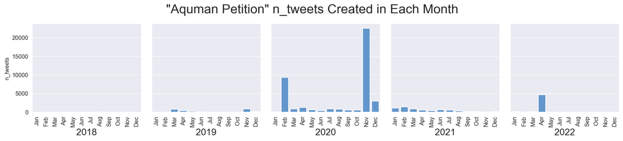

```python
df_month = df_creations.groupby(['month', 'year'])['n_tweets'].sum().reset_index()
helpers.facet_day_month(df_month, "month", "n_tweets", facet_on='year', n_col=5)
```

**NOTE:**

- 2020 Peaks --> Feb, Nov

### "Aquman Petition" Tweets Created in Each Day

> > - Tweets Created in Each Year
> > - Tweets Created in Each Month
> > - **Tweets Created in Each Day**
> > - Tweets Created in Each Day of 2018
> > - Tweets Created in Each Day of 2019
> > - Tweets Created in Each Day of 2020
> > - Tweets Created in Each Day of 2021
> > - Tweets Created in Each Day of 2022

```python
df_creations.head(1)
```

|  | date | year | month | dayofmonth | hour | n_tweets | by_#accounts | #created_accounts |
| --- | --- | --- | --- | --- | --- | --- | --- | --- |
| 0 | 2022-04-28 | 2022 | Apr | 28 | 16 | 276 | 267 | 4.0 |

```python
df_daily = (
    df_creations.groupby(['date', 'year', 'month', 'dayofmonth'])
    [['n_tweets', 'by_#accounts', '#created_accounts']].sum().reset_index()
)
df_daily.head(1)
```

|  | date | year | month | dayofmonth | n_tweets | by_#accounts | #created_accounts |
| --- | --- | --- | --- | --- | --- | --- | --- |
| 0 | 2018-03-16 | 2018 | Mar | 16 | 1 | 1 | 3.0 |

```python
# importlib.reload(helpers)
```

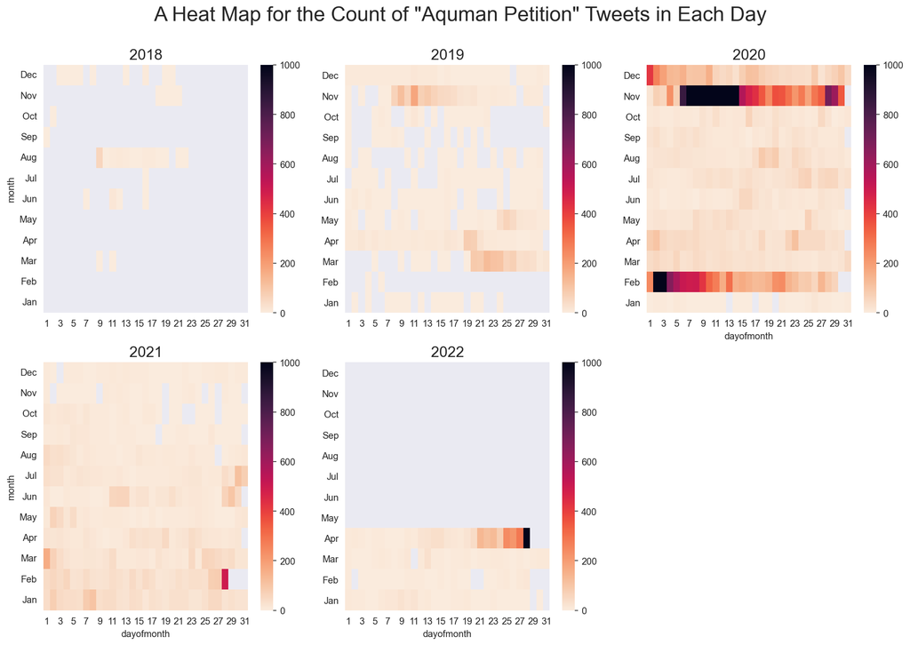

```python
title = 'A Heat Map for the Count of "Aquman Petition" Tweets in Each Day'
helpers.facet_heat(df_daily, title, n_col=3, vmax=1000)
```

```python
df_daily_18 = df_daily[df_daily["year"] == 2018]
df_daily_19 = df_daily[df_daily["year"] == 2019]
df_daily_20 = df_daily[df_daily["year"] == 2020]
df_daily_21 = df_daily[df_daily["year"] == 2021]
df_daily_22 = df_daily[df_daily["year"] == 2022]
```

### "Aquman Petition" Tweets Created in Each Day of 2018

> > - Tweets Created in Each Year
> > - Tweets Created in Each Month
> > - Tweets Created in Each Day
> > - **Tweets Created in Each Day of 2018**
> > - Tweets Created in Each Day of 2019
> > - Tweets Created in Each Day of 2020
> > - Tweets Created in Each Day of 2021
> > - Tweets Created in Each Day of 2022

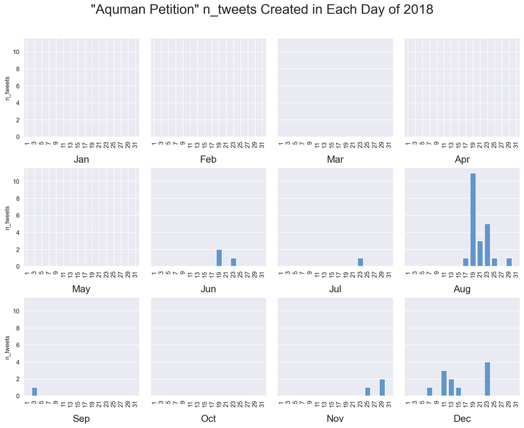

```python
helpers.facet_day_month(df_daily_18, "dayofmonth", "n_tweets", facet_on='month', n_col=4, year_str='2018')
```

### "Aquman Petition" Tweets Created in Each Day of 2019

> > - Tweets Created in Each Year
> > - Tweets Created in Each Month
> > - Tweets Created in Each Day
> > - Tweets Created in Each Day of 2018
> > - **Tweets Created in Each Day of 2019**
> > - Tweets Created in Each Day of 2020
> > - Tweets Created in Each Day of 2021
> > - Tweets Created in Each Day of 2022

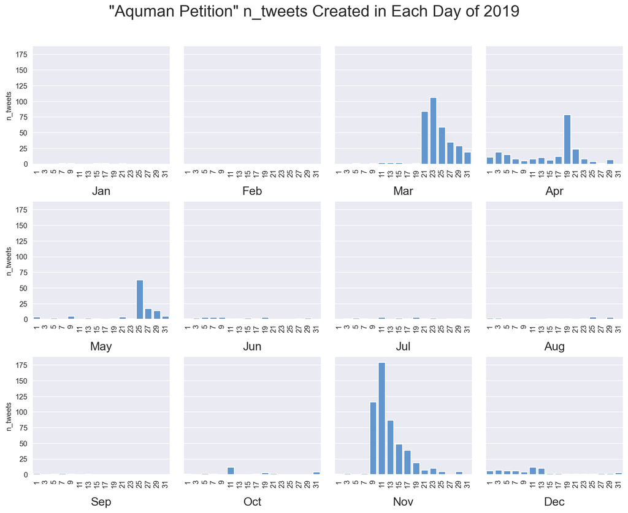

```python
helpers.facet_day_month(df_daily_19, "dayofmonth", "n_tweets", facet_on='month', n_col=4, year_str='2019')
```

### "Aquman Petition" Tweets Created in Each Day of 2020

> > - Tweets Created in Each Year
> > - Tweets Created in Each Month
> > - Tweets Created in Each Day
> > - Tweets Created in Each Day of 2018
> > - Tweets Created in Each Day of 2019
> > - **Tweets Created in Each Day of 2020**
> > - Tweets Created in Each Day of 2021
> > - Tweets Created in Each Day of 2022

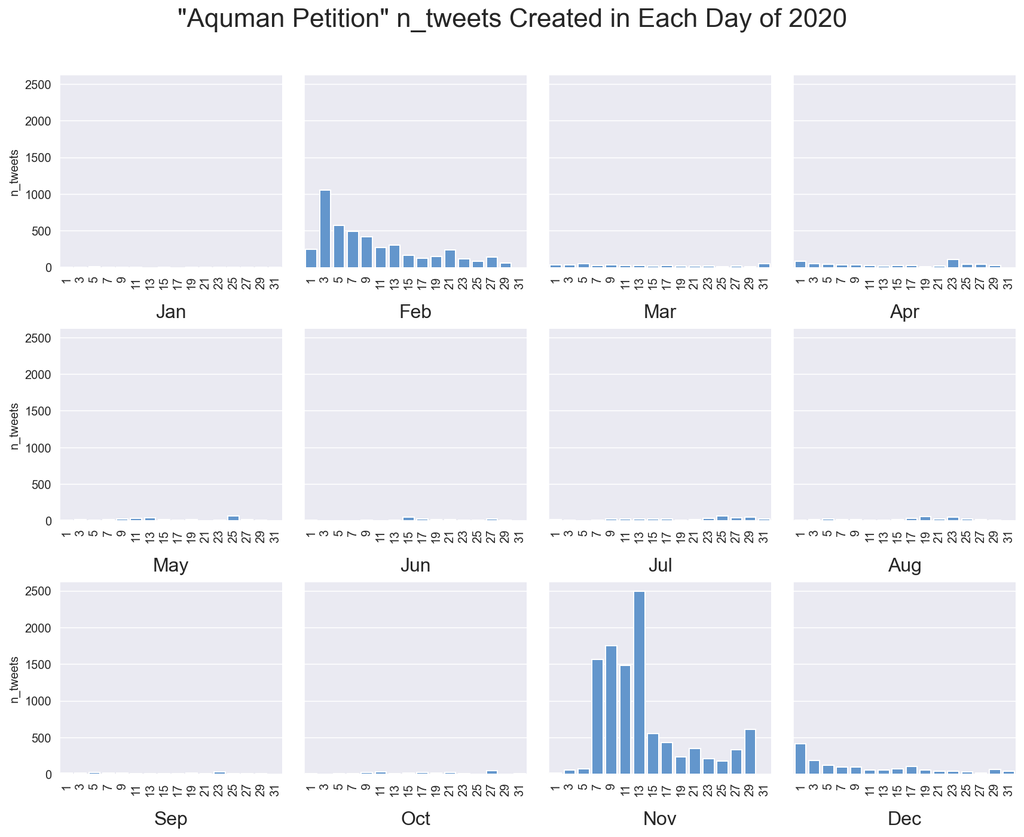

```python
helpers.facet_day_month(df_daily_20, "dayofmonth", "n_tweets", facet_on='month', n_col=4, year_str='2020')
```

### "Aquman Petition" Tweets Created in Each Day of 2021

> > - Tweets Created in Each Year
> > - Tweets Created in Each Month
> > - Tweets Created in Each Day
> > - Tweets Created in Each Day of 2018
> > - Tweets Created in Each Day of 2019
> > - Tweets Created in Each Day of 2020
> > - **Tweets Created in Each Day of 2021**
> > - Tweets Created in Each Day of 2022

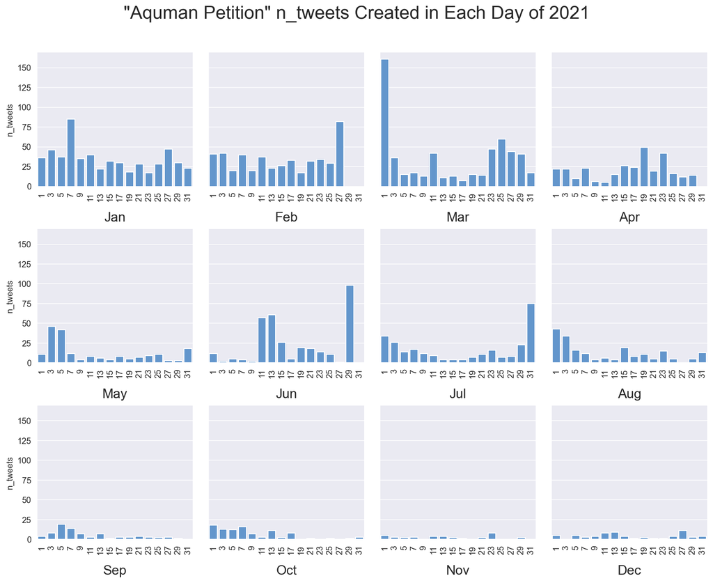

```python
helpers.facet_day_month(df_daily_21, "dayofmonth", "n_tweets", facet_on='month', n_col=4, year_str='2021')
```

### "Aquman Petition" Tweets Created in Each Day of 2022

> > - Tweets Created in Each Year
> > - Tweets Created in Each Month
> > - Tweets Created in Each Day
> > - Tweets Created in Each Day of 2018
> > - Tweets Created in Each Day of 2019
> > - Tweets Created in Each Day of 2020
> > - Tweets Created in Each Day of 2021
> > - **Tweets Created in Each Day of 2022**

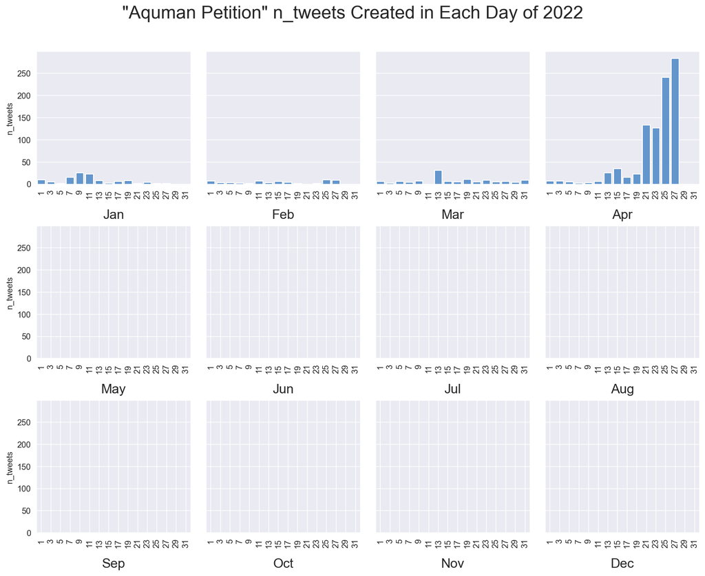

```python
helpers.facet_day_month(df_daily_22, "dayofmonth", "n_tweets", facet_on='month', n_col=4, year_str='2022')
```

## Investigate Peaks

> - Tweets Metrics
> - Users Tweets Metrics
> - ------------------------------
> - Duration After Account Creation
> - Tweets Created OVER TIME
> - **Peak Dates**
> - ------------------------------
> - Tweets on Peaks
> - Most Repeated Tweets
> - Same Text Same Date
> - ------------------------------
> - Unverified Accounts
> - Deleted or Banned
> - Default Profile Image
> - Users Metrics

**NOTE:**

- 2020 Peaks --> Feb, Nov
- 2022 Peaks --> Apr

```python
df_peaks = df_daily.sort_values('n_tweets', ascending=False)
df_peaks.head(10)
```

|  | date | year | month | dayofmonth | n_tweets | by_#accounts | #created_accounts |
| --- | --- | --- | --- | --- | --- | --- | --- |
| 1100 | 2022-04-28 | 2022 | Apr | 28 | 3231 | 3128 | 94.0 |
| 586 | 2020-11-12 | 2020 | Nov | 12 | 3197 | 3015 | 174.0 |
| 587 | 2020-11-13 | 2020 | Nov | 13 | 2493 | 2340 | 173.0 |
| 582 | 2020-11-08 | 2020 | Nov | 8 | 2094 | 1929 | 261.0 |
| 583 | 2020-11-09 | 2020 | Nov | 9 | 1752 | 1590 | 245.0 |
| 302 | 2020-02-02 | 2020 | Feb | 2 | 1654 | 1607 | 297.0 |
| 581 | 2020-11-07 | 2020 | Nov | 7 | 1565 | 1432 | 384.0 |
| 585 | 2020-11-11 | 2020 | Nov | 11 | 1482 | 1394 | 163.0 |
| 584 | 2020-11-10 | 2020 | Nov | 10 | 1447 | 1266 | 196.0 |
| 588 | 2020-11-14 | 2020 | Nov | 14 | 1134 | 1072 | 143.0 |

```python
# filter on dates with peaks
df_peaks = df_peaks[['date', 'n_tweets']]
df_peaks_18 = df_peaks[df_peaks.date.dt.year == 2018]
df_peaks_19 = df_peaks[df_peaks.date.dt.year == 2019]
df_peaks_20 = df_peaks[df_peaks.date.dt.year == 2020]
df_peaks_21 = df_peaks[df_peaks.date.dt.year == 2021]
df_peaks_22 = df_peaks[df_peaks.date.dt.year == 2022]
```

```python
df_feb_20 = df_peaks[(df_peaks.date.dt.year == 2020) & (df_peaks.date.dt.month == 2)]
df_nov_20 = df_peaks[(df_peaks.date.dt.year == 2020) & (df_peaks.date.dt.month == 11)]
df_dec_20 = df_peaks[(df_peaks.date.dt.year == 2020) & (df_peaks.date.dt.month == 12)]
df_apr_22 = df_peaks[(df_peaks.date.dt.year == 2022) & (df_peaks.date.dt.month == 4)]
```

### Peaks in All Years

> > - **All Years**
> > - 2018
> > - 2019
> > - 2020
> > - 2021
> > - 2022

```python
helpers.bar_peaks(df_peaks.head(2), "Dates with the Highest Number of 'Aquaman Petition' Tweets in All Years", threshold=0)
```

[figure not shown]

```python
helpers.bar_peaks(df_peaks[2:].head(3), "Dates with the Highest Number of 'Aquaman Petition' Tweets in All Years")
```

[figure not shown]

### 2018 Peaks

> > - All Years
> > - **2018**
> > - 2019
> > - 2020
> > - 2021
> > - 2022

```python
helpers.bar_peaks(df_peaks_18.head(2), "Dates with the Highest Number of 'Aquaman Petition' Tweets in 2018")
```

[figure not shown]

### 2019 Peaks

> > - All Years
> > - 2018
> > - **2019**
> > - 2020
> > - 2021
> > - 2022

```python
helpers.bar_peaks(df_peaks_19.head(2), "Dates with the Highest Number of 'Aquaman Petition' Tweets in 2019")
```

[figure not shown]

### 2020 Peaks

> > - All Years
> > - 2018
> > - 2019
> > - **2020**
> > - 2021
> > - 2022

```python
helpers.bar_peaks(df_peaks_20.head(4), "Dates with the Highest Number of 'Aquaman Petition' Tweets in 2020")
```

[figure not shown]

```python
helpers.bar_peaks(df_feb_20, "'Aquaman Petition' Tweets Created in Each Day of Feb 2020", 1000)
```

[figure not shown]

```python
helpers.bar_peaks(df_nov_20, "'Aquaman Petition' Tweets Created in Each Day of Nov 2020", 1000)
```

[figure not shown]

```python
helpers.bar_peaks(df_dec_20, "'Aquaman Petition' Tweets Created in Each Day of Dec 2020", 1000)
```

[figure not shown]

### 2021 Peaks

> > - All Years
> > - 2018
> > - 2019
> > - 2020
> > - **2021**
> > - 2022

```python
helpers.bar_peaks(df_peaks_21.head(2), "Dates with the Highest Number of 'Aquaman Petition' Tweets in 2021")
```

[figure not shown]

### 2022 Peaks

> > - All Years
> > - 2018
> > - 2019
> > - 2020
> > - 2021
> > - **2022**

```python
helpers.bar_peaks(df_peaks_22.head(11), "Dates with the Highest Number of 'Aquaman Petition' Tweets in 2022", threshold=3000)
```

[figure not shown]

## "Aquaman Petition" Tweets on Peaks

> - Tweets Metrics
> - Users Tweets Metrics
> - ------------------------------
> - Duration After Account Creation
> - Tweets Created OVER TIME
> - Peak Dates
> - ------------------------------
> - **Tweets on Peaks**
> - Most Repeated Tweets
> - Same Text Same Date
> - ------------------------------
> - Unverified Accounts
> - Deleted or Banned
> - Default Profile Image
> - Users Metrics

## "Aquaman Petition" Tweets on Peak Dates

> > - **Tweets on Peak Dates**
> > - Tweets on Peak Hours
> > - Tweets on Peak Times

### Peak Dates

```python
df_peaks.head(10)
```

|  | date | n_tweets |
| --- | --- | --- |
| 1100 | 2022-04-28 | 3231 |
| 586 | 2020-11-12 | 3197 |
| 587 | 2020-11-13 | 2493 |
| 582 | 2020-11-08 | 2094 |
| 583 | 2020-11-09 | 1752 |
| 302 | 2020-02-02 | 1654 |
| 581 | 2020-11-07 | 1565 |
| 585 | 2020-11-11 | 1482 |
| 584 | 2020-11-10 | 1447 |
| 588 | 2020-11-14 | 1134 |

```python
mask = (aquaman_petition.date.astype(str)=="2022-04-28")
df = aquaman_petition[mask]
tmp = df.groupby('hour').size().reset_index(name='n_tweets')

title = '"Aquaman Petition" Contributions on (2022-04-28)'
helpers.bar_peaks(tmp, title, threshold=90, xlabel='Hour')
```

[figure not shown]

```python
aquaman_petition[aquaman_petition.date.astype(str) == "2022-04-28"]["text"].value_counts().head()
```

```
dc entertainment: remove amber heard from aquaman 2 - sign the petition! https://t.co/8829dkv21h via @change              2
dc entertainment: remove amber heard from aquaman 2 - sign the petition! https://t.co/f06emailvb @change használatával    2
„dc entertainment: remove amber heard from aquaman 2” - jetzt unterschreiben! https://t.co/dqnsrv3v2k via @changeger      2
dc entertainment: remove amber heard from aquaman 2 - sign the petition! https://t.co/usypy1jybg via @changeorg_india     2
dc entertainment: remove amber heard from aquaman 2 - sign the petition! https://t.co/7uwi04vjnc via @change              2
Name: text, dtype: int64
```

```python
aquaman_petition[aquaman_petition.date.astype(str) == "2022-04-28"]["username"].value_counts().head()
```

```
leah bennett       7
Crystal Moore      6
Jaybee34           6
Michelle           5
Stacey Innocent    4
Name: username, dtype: int64
```

```python
mask = (aquaman_petition.date.astype(str)=="2020-11-12")
df = aquaman_petition[mask]
tmp = df.groupby('hour').size().reset_index(name='n_tweets')

title = '"Aquaman Petition" Contributions on (2020-11-12)'
helpers.bar_peaks(tmp, title, threshold=0, xlabel='Hour')
```

[figure not shown]

```python
aquaman_petition[aquaman_petition.date.astype(str) == "2020-11-12"]["text"].value_counts().head()
```

```
dc entertainment: remove amber heard from aquaman 2 - sign the petition! https://t.co/pckoi1lujs via @ukchange                         2
warner brothers: emilia clarke to replace amber heard as mera on aquaman 2 - sign the petition! https://t.co/tqygilzheo via @change    2
dc entertainment: remove amber heard from aquaman 2 - sign the petition! https://t.co/hnyykb21hv via @change                           2
dc entertainment: remove amber heard from aquaman 2 - sign the petition! https://t.co/cqezpn34zw via @ukchange                         2
dc entertainment: remove amber heard from aquaman 2 - sign the petition! https://t.co/wgbdjj6iai via @change                           2
Name: text, dtype: int64
```

```python
aquaman_petition[aquaman_petition.date.astype(str) == "2020-11-12"]["username"].value_counts().head()
```

```
Support Johnny Depp ♡ Stream City of Lies         27
metallicarebear                                   10
Tanya 🇬🇧🏴‍☠️ Wald-Mignon #JusticeForJohnnyDepp     9
Idea@JusticeForJohnnyDepp                          8
Stephanie Brown                                    8
Name: username, dtype: int64
```

## "Aquaman Petition" Tweets on Peak Hours

> > - Tweets on Peak Dates
> > - **Tweets on Peak Hours**
> > - Tweets on Peak Times

```python
aquaman_petition.head(1)
```

|  | n_statuses | created_at | user_description | user_created_at | user_id | username | is_verified | user_location | n_followers | user_url | lang | profile_banner_url | profile_image_url | text | n_friends | tweet_id | user_screen_name | date | year | month | dayofmonth | hour | diff | days_diff | minutes_diff | retweet_count | reply_count | like_count | quote_count | … |
| --- | --- | --- | --- | --- | --- | --- | --- | --- | --- | --- | --- | --- | --- | --- | --- | --- | --- | --- | --- | --- | --- | --- | --- | --- | --- | --- | --- | --- | --- | --- |
| 4434 | 2860 | 2018-03-16 21:52:09 | I pretend to be sophisticated, but really I'm ... | 2016-06-29 18:06:35 | 748216104565235712 | Morgan | False | NaN | 177 | https://t.co/7NiXfsBF9J | en | https://pbs.twimg.com/profile_banners/74821610... | http://pbs.twimg.com/profile_images/1202278135... | can't find the receipts but he also defended j... | 656 | 974765287080853508 | mdragonfly89 | 2018-03-16 | 2018 | Mar | 16 | 21 | 625 days 03:45:34 | 625 | 225.57 | 0.0 | 0.0 | 6.0 | 0.0 | … |

```python
df_peak_hrs = aquaman_petition.groupby(['date', 'hour']).agg({'text':'count'}).reset_index(
).rename(columns={'text':'n_tweets'}).sort_values('n_tweets', ascending=False)

df_peak_hrs.head(15)
```

|  | date | hour | n_tweets |
| --- | --- | --- | --- |
| 10236 | 2022-04-28 | 16 | 276 |
| 10234 | 2022-04-28 | 14 | 275 |
| 10237 | 2022-04-28 | 17 | 266 |
| 10241 | 2022-04-28 | 21 | 246 |
| 10238 | 2022-04-28 | 18 | 242 |
| 10240 | 2022-04-28 | 20 | 238 |
| 10235 | 2022-04-28 | 15 | 234 |
| 10239 | 2022-04-28 | 19 | 233 |
| 10242 | 2022-04-28 | 22 | 228 |
| 10233 | 2022-04-28 | 13 | 219 |
| 5321 | 2020-11-13 | 0 | 215 |
| 5314 | 2020-11-12 | 17 | 209 |
| 5315 | 2020-11-12 | 18 | 209 |
| 5313 | 2020-11-12 | 16 | 203 |
| 5317 | 2020-11-12 | 20 | 196 |

### Users with The Most Tweets on the same hour

```python
df = aquaman_petition.groupby(['date', 'hour', 'username']).agg({'text':'count'}).reset_index(
).rename(columns={'text':'n_tweets'}).sort_values('n_tweets', ascending=False)

print(df.shape)
df.head(15)
```

```
(51849, 4)
```

|  | date | hour | username | n_tweets |
| --- | --- | --- | --- | --- |
| 29068 | 2020-11-13 | 0 | Pantea☠︎ | 69 |
| 22874 | 2020-11-09 | 17 | kateinthemiddle🎃 | 45 |
| 23913 | 2020-11-10 | 13 | rds-AlJacob | 39 |
| 23860 | 2020-11-10 | 12 | rds-AlJacob | 38 |
| 23958 | 2020-11-10 | 14 | rds-AlJacob | 32 |
| 20038 | 2020-11-08 | 2 | Rohan Malviya | 21 |
| 36029 | 2020-11-26 | 19 | Reivaxx | 19 |
| 33879 | 2020-11-18 | 5 | Jeff | 18 |
| 35567 | 2020-11-24 | 15 | Tepa.M.T | 15 |
| 19111 | 2020-11-07 | 13 | 梅雨 | 14 |
| 37349 | 2020-11-29 | 10 | Denisse | 14 |
| 43724 | 2021-03-23 | 16 | Debbie Michailides | 14 |
| 44932 | 2021-06-11 | 13 | Marvel.Fury | 13 |
| 41013 | 2021-01-07 | 12 | Irina Skywalker | 13 |
| 43726 | 2021-03-23 | 17 | Debbie Michailides | 12 |

```python
title = 'Users with The Most "Aquaman Petition" Contributions on Each Hour'
helpers.barh(df[['username', 'n_tweets']].head(15), title, c='red') # , c=colors
```

[figure not shown]

### Pantea☠︎ (69) "Aquaman Petition" Tweets (2020-11-13) on the same hour (12:00 am)

```python
mask = (aquaman_petition.date.astype(str)=="2020-11-13") & (aquaman_petition.username=="Pantea☠︎")
tmp = aquaman_petition[mask]
tmp.text.value_counts().head(30)
```

```
@alexdoradoo dc entertainment: remove amber heard from aquaman 2 - sign the petition! https://t.co/4rrcupclrq via @change        1
@asharblz dc entertainment: remove amber heard from aquaman 2 - sign the petition! https://t.co/4rrcupclrq via @change           1
@mattlovescinema dc entertainment: remove amber heard from aquaman 2 - sign the petition! https://t.co/4rrcupclrq                1
@lewisjohny2 dc entertainment: remove amber heard from aquaman 2 - sign the petition! https://t.co/4rrcupclrq                    1
@gwcpika dc entertainment: remove amber heard from aquaman 2 - sign the petition! https://t.co/4rrcupclrq via @change            1
@bredgaming dc entertainment: remove amber heard from aquaman 2 - sign the petition! https://t.co/4rrcupclrq via @change         1
@slimeseason35 dc entertainment: remove amber heard from aquaman 2 - sign the petition! https://t.co/4rrcupclrq via @change      1
@emarged dc entertainment: remove amber heard from aquaman 2 - sign the petition! https://t.co/4rrcupclrq via @change            1
@gay_moana dc entertainment: remove amber heard from aquaman 2 - sign the petition! https://t.co/4rrcupclrq via @change          1
@infinitejay dc entertainment: remove amber heard from aquaman 2 - sign the petition! https://t.co/4rrcupclrq via @change        1
@holyska1991 dc entertainment: remove amber heard from aquaman 2 - sign the petition! https://t.co/4rrcupclrq via @change        1
@gingerstale dc entertainment: remove amber heard from aquaman 2 - sign the petition! https://t.co/4rrcupclrq via @change        1
@astronixii dc entertainment: remove amber heard from aquaman 2 - sign the petition! https://t.co/4rrcupclrq via @change         1
@gibjock dc entertainment: remove amber heard from aquaman 2 - sign the petition! https://t.co/4rrcupclrq via @change            1
@emily_jayne1233 dc entertainment: remove amber heard from aquaman 2 - sign the petition! https://t.co/4rrcupclrq via @change    1
@poedjarin dc entertainment: remove amber heard from aquaman 2 - sign the petition! https://t.co/4rrcupclrq via @change          1
@andrew_muench dc entertainment: remove amber heard from aquaman 2 - sign the petition! https://t.co/4rrcupclrq                  1
@unlucky_em dc entertainment: remove amber heard from aquaman 2 - sign the petition! https://t.co/4rrcupclrq                     1
@dulllahh dc entertainment: remove amber heard from aquaman 2 - sign the petition! https://t.co/4rrcupumiy                       1
@broncosojrr dc entertainment: remove amber heard from aquaman 2 - sign the petition! https://t.co/4rrcupclrq                    1
@selrareheartbet dc entertainment: remove amber heard from aquaman 2 - sign the petition! https://t.co/4rrcupclrq                1
@skcomics2 dc entertainment: remove amber heard from aquaman 2 - sign the petition! https://t.co/4rrcupclrq                      1
@pantherhollyann dc entertainment: remove amber heard from aquaman 2 - sign the petition! https://t.co/4rrcupclrq                1
@nazaekwunife dc entertainment: remove amber heard from aquaman 2 - sign the petition! https://t.co/4rrcupclrq                   1
@redapplesquares dc entertainment: remove amber heard from aquaman 2 - sign the petition! https://t.co/4rrcupclrq                1
@alidocinferno dc entertainment: remove amber heard from aquaman 2 - sign the petition! https://t.co/4rrcupclrq                  1
@moonfiyahh dc entertainment: remove amber heard from aquaman 2 - sign the petition! https://t.co/4rrcupclrq                     1
@immortallydum dc entertainment: remove amber heard from aquaman 2 - sign the petition! https://t.co/4rrcupclrq                  1
@jamiekinnear2 dc entertainment: remove amber heard from aquaman 2 - sign the petition! https://t.co/4rrcupclrq                  1
@happygamerlife dc entertainment: remove amber heard from aquaman 2 - sign the petition! https://t.co/4rrcupclrq                 1
Name: text, dtype: int64
```

```python
mask = (aquaman_petition.date.astype(str)=="2020-11-06") & (aquaman_petition.username=="misscastle13")
tmp = aquaman_petition[mask]
tmp.text.value_counts().head(30)
```

```
Series([], Name: text, dtype: int64)
```

### kateinthemiddle🎃 (45) "Aquaman Petition" Tweets (2020-11-09) on the same hour (05:00 pm)

```python
mask = (aquaman_petition.date.astype(str)=="2020-11-09") & (aquaman_petition.username=="kateinthemiddle🎃")
tmp = aquaman_petition[mask]
tmp.text.value_counts().head(30)
```

```
@mygrindelwald lets save johnny! sign &amp; share these petitions! together we can make it! https://t.co/qpjmehtcb2 &amp; https://t.co/94flecmmrt #justiceforjohnnydepp #amberheardisanabuser                                              1
@deppxblake lets save johnny! sign &amp; share these petitions, together we can make it! https://t.co/qpjmehtcb2 &amp; https://t.co/94flecmmrt #justiceforjohnnydepp #amberheardisanabuser                                                 1
@dariapankov lets save johnny! sign &amp; share these petitions, together we can make it! https://t.co/qpjmehtcb2 &amp; https://t.co/94flecmmrt #justiceforjohnnydepp #amberheardisanabuser                                                1
@folllllll__ lets save johnny! sign &amp; share these petitions, together we can make it! https://t.co/qpjmehtcb2 &amp; https://t.co/94flecmmrt #justiceforjohnnydepp #amberheardisanabuser                                                1
@kountryserenity lets save johnny! sign &amp; share these petitions, together we can make it! https://t.co/qpjmehtcb2 &amp; https://t.co/94flecmmrt #justiceforjohnnydepp #amberheardisanabuser                                            1
@himespit lets save johnny! sign &amp; share these petitions, together we can make it! https://t.co/qpjmehtcb2 &amp; https://t.co/94flecmmrt #justiceforjohnnydepp #amberheardisanabuser                                                   1
@juliee_nc lets save johnny! sign &amp; share these petitions, together we can make it! https://t.co/qpjmehtcb2 &amp; https://t.co/94flecmmrt #justiceforjohnnydepp #amberheardisanabuser                                                  1
@hectorray0623 lets save johnny! sign &amp; share these petitions, together we can make it! https://t.co/qpjmehtcb2 &amp; https://t.co/94flecmmrt #justiceforjohnnydepp #amberheardisanabuser                                              1
@bey_bts lets save johnny! sign &amp; share these petitions, together we can make it! https://t.co/qpjmehtcb2 &amp; https://t.co/94flecmmrt #justiceforjohnnydepp #amberheardisanabuser                                                    1
@irem_yagmur_ lets save johnny! sign &amp; share these petitions, together we can make it! https://t.co/qpjmehtcb2 &amp; https://t.co/94flecmmrt #justiceforjohnnydepp #amberheardisanabuser                                               1
@colt_arnold lets save johnny! sign &amp; share these petitions, together we can make it! https://t.co/qpjmehtcb2 &amp; https://t.co/94flecmmrt #justiceforjohnnydepp #amberheardisanabuser                                                1
@bacacov lets save johnny! sign &amp; share these petitions, together we can make it! https://t.co/qpjmehtcb2 &amp; https://t.co/94flecmmrt #justiceforjohnnydepp #amberheardisanabuser                                                    1
@adityam3199 lets save johnny! sign &amp; share these petitions, together we can make it! https://t.co/qpjmehtcb2 &amp; https://t.co/94flecmmrt #justiceforjohnnydepp #amberheardisanabuser                                                1
@aishiteirudarin lets save johnny! sign &amp; share these petitions, together we can make it! https://t.co/qpjmehtcb2 &amp; https://t.co/94flecmmrt #justiceforjohnnydepp #amberheardisanabuser                                            1
@jessconnell1 lets save johnny! sign &amp; share these petitions, together we can make it! https://t.co/qpjmehtcb2 &amp; https://t.co/94flecmmrt #justiceforjohnnydepp #amberheardisanabuser                                               1
@suspectbuddy @coramelodie @realamberheard @kamalaharris lets save johnny! sign &amp; share these petitions, together we can make it! https://t.co/qpjmehtcb2 &amp; https://t.co/94flecmmrt #justiceforjohnnydepp #amberheardisanabuser    1
@swami_ananya lets save johnny! sign &amp; share these petitions, together we can make it! https://t.co/qpjmehtcb2 &amp; https://t.co/94flecmmrt #justiceforjohnnydepp #amberheardisanabuser                                               1
@philmitchell83 lets save johnny! sign &amp; share these petitions, together we can make it! https://t.co/qpjmehtcb2 &amp; https://t.co/94flecmmrt #justiceforjohnnydepp #amberheardisanabuser                                             1
@sineonfirinne lets save johnny! sign &amp; share these petitions, together we can make it! https://t.co/qpjmehtcb2 &amp; https://t.co/94flecmmrt #justiceforjohnnydepp #amberheardisanabuser                                              1
@magconboundd lets save johnny! sign &amp; share these petitions, together we can make it! https://t.co/qpjmehtcb2 &amp; https://t.co/94flecmmrt #justiceforjohnnydepp #amberheardisanabuser                                               1
```

[output cut: 11 more lines]

## "Aquaman Petition" Tweets on Peak Times

> - Tweets on Peak Dates
> - Tweets on Peak Hours
> - **Tweets on Peak Times**

```python
df_peak_times = aquaman_petition.groupby('created_at').count()['text'].reset_index(name='n_tweets')\
.sort_values('n_tweets', ascending=False)

df_peak_times.head()
```

|  | created_at | n_tweets |
| --- | --- | --- |
| 42031 | 2020-12-10 17:23:29 | 3 |
| 29974 | 2020-11-12 19:37:54 | 3 |
| 30731 | 2020-11-13 00:00:03 | 3 |
| 22366 | 2020-11-08 17:53:12 | 2 |
| 3192 | 2020-02-02 00:54:11 | 2 |

```python
df = aquaman_petition.groupby(['created_at', 'username']).agg({'text':'count'}).reset_index(
).rename(columns={'text':'n_tweets'}).sort_values('n_tweets', ascending=False)

df = df[df.n_tweets > 1]

print(f'Unique number of users: {df.username.nunique()}')
print(f'Total number of Tweets: {df.n_tweets.sum()}')
df.head(15)
```

```
Unique number of users: 12
Total number of Tweets: 25
```

|  | created_at | username | n_tweets |
| --- | --- | --- | --- |
| 42357 | 2020-12-10 17:23:29 | trapholizay | 3 |
| 22583 | 2020-11-08 18:38:57 | Support Johnny Depp ♡ Stream City of Lies | 2 |
| 25349 | 2020-11-10 11:08:11 | ContanzaBustosflores | 2 |
| 54620 | 2022-04-28 20:51:21 | Lil Linda | 2 |
| 52996 | 2022-04-28 14:23:28 | Ivan A. Sanchez V. | 2 |
| 49750 | 2021-10-01 06:32:52 | Tepa.M.T | 2 |
| 50278 | 2022-01-18 03:18:51 | Lalita Tripathi | 2 |
| 39318 | 2020-11-28 15:03:21 | Wait, I'm Not Ready Yet. | 2 |
| 23604 | 2020-11-09 08:28:29 | ४&⎊ Amaryss😎 | 2 |
| 46597 | 2021-03-11 11:13:32 | hp🏴‍☠️💕🏴‍☠️ | 2 |
| 18795 | 2020-11-06 18:25:11 | SimonBarreBrisebois | 2 |
| 46268 | 2021-03-01 14:02:08 | InterNewsCast | 2 |

```python
title = 'Users with The Most "Aquaman Petition" Contributions on The same Time'
helpers.barh(df[['username', 'n_tweets']].head(15), title, c='red') # , c=colors
```

[figure not shown]

```python
aquaman_petition.duplicated().sum()
```

```
0
```

```python
aquaman_petition[aquaman_petition.created_at.astype(str) == "2020-12-10 17:23:29"]
```

|  | n_statuses | created_at | user_description | user_created_at | user_id | username | is_verified | user_location | n_followers | user_url | lang | profile_banner_url | profile_image_url | text | n_friends | tweet_id | user_screen_name | date | year | month | dayofmonth | hour | diff | days_diff | minutes_diff | retweet_count | reply_count | like_count | quote_count | … |
| --- | --- | --- | --- | --- | --- | --- | --- | --- | --- | --- | --- | --- | --- | --- | --- | --- | --- | --- | --- | --- | --- | --- | --- | --- | --- | --- | --- | --- | --- | --- |
| 693851 | 42545 | 2020-12-10 17:23:29 | News aggregator for hip-hop | 2020-01-27 01:17:47 | 1221603113477591042 | trapholizay | False | The Internet | 16 | https://t.co/RtCeEzOF18 | en | NaN | http://pbs.twimg.com/profile_images/1221614711... | johnny depp reportedly tries to have amber hea... | 0 | 1337085539162476544 | trapholizaynews | 2020-12-10 | 2020 | Dec | 10 | 17 | 318 days 16:05:42 | 318 | 965.7 | 0.0 | 1.0 | 0.0 | 0.0 | … |
| 693850 | 42545 | 2020-12-10 17:23:29 | News aggregator for hip-hop | 2020-01-27 01:17:47 | 1221603113477591042 | trapholizay | False | The Internet | 16 | https://t.co/RtCeEzOF18 | en | NaN | http://pbs.twimg.com/profile_images/1221614711... | johnny depp reportedly tries to have amber hea... | 0 | 1337085539120459779 | trapholizaynews | 2020-12-10 | 2020 | Dec | 10 | 17 | 318 days 16:05:42 | 318 | 965.7 | 0.0 | 1.0 | 0.0 | 0.0 | … |
| 693849 | 42545 | 2020-12-10 17:23:29 | News aggregator for hip-hop | 2020-01-27 01:17:47 | 1221603113477591042 | trapholizay | False | The Internet | 16 | https://t.co/RtCeEzOF18 | en | NaN | http://pbs.twimg.com/profile_images/1221614711... | johnny depp reportedly tries to have amber hea... | 0 | 1337085539044954112 | trapholizaynews | 2020-12-10 | 2020 | Dec | 10 | 17 | 318 days 16:05:42 | 318 | 965.7 | 0.0 | 1.0 | 0.0 | 0.0 | … |

```python
print('\nIdentical Tweets data except for the created petition link\n')
aquaman_petition[aquaman_petition.created_at.astype(str) == "2020-12-10 17:23:29"].text.value_counts()
```

```
Identical Tweets data except for the created petition link
```

```
johnny depp reportedly tries to have amber heard fired from "aquaman 2"\n\n#amberheard #aquaman2 #beef #johnnydepp #johnnydeppabuseallegations #m...\nhttps://t.co/rehhrj8x7q    1
johnny depp reportedly tries to have amber heard fired from "aquaman 2"\n\n#amberheard #aquaman2 #beef #johnnydepp #johnnydeppabuseallegations #m...\nhttps://t.co/ofenkvjtce    1
johnny depp reportedly tries to have amber heard fired from "aquaman 2"\n\n#amberheard #aquaman2 #beef #johnnydepp #johnnydeppabuseallegations #m...\nhttps://t.co/0xt4vor5zh    1
Name: text, dtype: int64
```

## Most Repeated Tweets

> - Tweets Metrics
> - Users Tweets Metrics
> - ------------------------------
> - Duration After Account Creation
> - Tweets Created OVER TIME
> - Peak Dates
> - ------------------------------
> - Tweets on Peaks
> - **Most Repeated Tweets**
> - Same Text Same Date
> - ------------------------------
> - Unverified Accounts
> - Deleted or Banned
> - Default Profile Image
> - Users Metrics

```python
aquaman_petition.text.value_counts().head(30)
```

```
remove the turd from aquaman 2 petition: https://t.co/osnxmebphw\n\n#justiceforjohnnydepp #johnydeppisinnocent\n#johnnydepp #fireamberheard #amberturd #boycottwarnerbros #boycottdisney #boycottthesun                                                                                    15
@gn_geeknation please help sign, share &amp; retweet. thanks, you're fantastic.\n\nl'oréal: remove amber heard as l'oreal spokesperson - sign the petition! https://t.co/p7sbttmnbi via @change                                                                                            13
dc entertainment: remove amber heard from aquaman 2 - sign the petition! https://t.co/ayerxv1tkr via @change                                                                                                                                                                               12
dc entertainment: remove amber heard from aquaman 2 - sign the petition! https://t.co/2hqx8updxs via @change                                                                                                                                                                               11
dc entertainment: remove amber heard from aquaman 2 - sign the petition! https://t.co/vq7lnk6xq8 via @change                                                                                                                                                                               11
dc entertainment: remove amber heard from aquaman 2 - sign the petition! https://t.co/s2ngnta5md via @cdnchange \n\n#justiceforjohnnydepp                                                                                                                                                  10
dc entertainment: remove amber heard from aquaman 2 - sign the petition! https://t.co/453uc1kgck via @change                                                                                                                                                                               10
warnermedia: fire amber heard from aquaman 2 - sign the petition! https://t.co/b8ttqwgfyy via @change #johnnydeppisinnocent \n#amberheardisaliar #amberheardisanabuser #justiceforjohnnydepp  #johnnydeppisavictim #fireamberheard #boycottloreal #recastmera #nojohnnynopirates            9
dc entertainment: remove amber heard from aquaman 2 - sign the petition! https://t.co/wim1zy1kls via @change                                                                                                                                                                                8
dc entertainment: remove amber heard from aquaman 2 - sign the petition! https://t.co/fpzgqp3wjw via @change                                                                                                                                                                                8
dc entertainment: remove amber heard from aquaman 2 - sign the petition! https://t.co/2v6mnnewq1 via @change                                                                                                                                                                                8
l'oréal: remove amber heard as l'oreal spokesperson - sign the petition! https://t.co/tkpbutm7rf via @change #johnnydeppisinnocent \n#amberheardisaliar #amberheardisanabuser #justiceforjohnnydepp  #johnnydeppisavictim #fireamberheard #boycottloreal #recastmera #nojohnnynopirates     7
dc entertainment: remove amber heard from aquaman 2 - sign the petition! https://t.co/kgdu4qjv8r via @change                                                                                                                                                                                7
please sign the petition! https://t.co/n4oyifjxoz\n#johnnydepp #justiceforjohnnydepp #boycottwarnerbros #fantasticbeasts                                                                                                                                                                    7
please sign the petition! https://t.co/n4oyifjxoz\n#johnnydepp #justiceforjohnnydepp #boycottwarnerbros #boycottfantasticbeasts3 #fantasticbeasts                                                                                                                                           7
l'oréal: remove amber heard as l'oréal spokeperson - sign the petition! https://t.co/x2idddwtrt via @change #johnnydeppisinnocent \n#amberheardisaliar #amberheardisanabuser #justiceforjohnnydepp  #johnnydeppisavictim #fireamberheard #boycottloreal #recastmera #nojohnnynopirates      7
dc entertainment: remove amber heard from aquaman 2 - sign the petition! https://t.co/c8ho35f9oz via @change #johnnydeppisinnocent \n#amberheardisaliar #amberheardisanabuser #justiceforjohnnydepp  #johnnydeppisavictim #fireamberheard #boycottloreal #recastmera #nojohnnynopirates     6
the people: warner bros, bring johnny depp back as gellert grindelwald!!! - sign the petition! https://t.co/j6ecforj53 via @cdnchange \n\n#justiceforjohnnydepp                                                                                                                             6
please sign the petition! https://t.co/n4oyifjxoz\n#johnnydepp #justiceforjohnnydepp #boycottwarnerbros #fantasticbeasts #fantasticbeasts3                                                                                                                                                  6
@realamberheard dc entertainment: remove amber heard from aquaman 2 - sign the petition! https://t.co/njgw3t9cwh vía @change_es #justiceforjohnnydepp                                                                                                                                       5
```

[output cut: 11 more lines]

## Same Text Same Date

> - Tweets Metrics
> - Users Tweets Metrics
> - ------------------------------
> - Duration After Account Creation
> - Tweets Created OVER TIME
> - Peak Dates
> - ------------------------------
> - Tweets on Peaks
> - Most Repeated Tweets
> - **Same Text Same Date**
> - ------------------------------
> - Unverified Accounts
> - Deleted or Banned
> - Default Profile Image
> - Users Metrics

```python
# print('\nThe Amplifications in the counts and number of likes on #justiceforjohnnydepp is quite obvious!!')
df_same = aquaman_petition.groupby(["text", "date", 'username']).agg({'tweet_id':'count', 'user_id': 'nunique'}).reset_index()
df_same.rename(columns={'tweet_id': 'n_tweets', 'user_id':'by_#accounts'}, inplace=True)
df_same.sort_values(["n_tweets", 'date'], ascending=[False, True], inplace=True)

with pd.option_context('display.max_colwidth', None):
    display(df_same.head(15))
```

|  | text | date | username | n_tweets | by_#accounts |
| --- | --- | --- | --- | --- | --- |
| 3401 | @gn_geeknation please help sign, share &amp; retweet. thanks, you're fantastic.\n\nl'oréal: remove amber heard as l'oreal spokesperson - sign the petition! https://t.co/p7sbttmnbi via @change | 2021-01-07 | Irina Skywalker | 13 | 1 |
| 48702 | remove the turd from aquaman 2 petition: https://t.co/osnxmebphw\n\n#justiceforjohnnydepp #johnydeppisinnocent\n#johnnydepp #fireamberheard #amberturd #boycottwarnerbros #boycottdisney #boycottthesun | 2020-11-07 | 𝚒𝚣𝚓𝚌𝚕𝚗𝚘𝚕𝚒𝚟𝚊𝚊𝚊𝚊 ♥️ | 11 | 1 |
| 7704 | bring captain jack sparrow petition: sign nowwww at https://t.co/edpdsnq0s4 #justiceforjohnnydepp #johnnydeppisasurvivor #johnnydeppismygrindelwald #jacksparrow #amberturd #amberheardisanabuser #amber… | 2020-11-09 | 𝚒𝚣𝚓𝚌𝚕𝚗𝚘𝚕𝚒𝚟𝚊𝚊𝚊𝚊 ♥️ | 5 | 1 |
| 3988 | @realamberheard dc entertainment: remove amber heard from aquaman 2 - sign the petition! https://t.co/njgw3t9cwh vía @change_es #justiceforjohnnydepp | 2020-11-29 | Denisse | 5 | 1 |
| 48703 | remove the turd from aquaman 2 petition: https://t.co/osnxmebphw\n\n#justiceforjohnnydepp #johnydeppisinnocent\n#johnnydepp #fireamberheard #amberturd #boycottwarnerbros #boycottdisney #boycottthesun | 2020-11-08 | 𝚒𝚣𝚓𝚌𝚕𝚗𝚘𝚕𝚒𝚟𝚊𝚊𝚊𝚊 ♥️ | 4 | 1 |
| 4324 | @thr sign this petition to remove amber heard the abuser from aquaman2 👇🏼👇🏼👇🏼\n#justiceforjohnnydepp \nhttps://t.co/t7mgd9fa14 | 2020-12-09 | I am Ghazaal | 4 | 1 |
| 27911 | dc entertainment: remove amber heard from aquaman 2 - sign the petition! https://t.co/s2ngnta5md via @cdnchange \n\n#justiceforjohnnydepp | 2020-11-08 | metallicarebear | 3 | 1 |
| 49885 | the people: warner bros, bring johnny depp back as gellert grindelwald!!! - sign the petition! https://t.co/j6ecforj53 via @cdnchange \n\n#justiceforjohnnydepp | 2020-11-08 | metallicarebear | 3 | 1 |
| 3996 | @realamberheard https://t.co/avrp22ij00\nplease sign!! we reached 1million now lets get more :) \nsign and share to get amber off aquaman 2! thank you❤ #justiceforjohnnydepp #amberheard #amberheardisa… | 2020-11-14 | Luna Loves | 3 | 1 |
| 37167 | dc entertainment: remove amber heard from aquaman 2 - ¡firma la petición! https://t.co/lsycyjhow1 vía @changeorglatino | 2021-04-07 | Katrina ♡ | 3 | 1 |
| 48065 | please, let your voice be heard against injustice brought by amber heard https://t.co/r7te1hzisg \n\nsign a petition to show \n@warnerbros\n \n@aquamanmovie\n nobody supports domestic abusers as they … | 2021-09-07 | Papaya | 3 | 1 |
| 11783 | dc entertainment: remove amber heard from aquaman 2 - sign the petition! https://t.co/5q5dtfdg8c via @ukchange | 2019-03-21 | Amanda Rose | 2 | 1 |
| 19401 | dc entertainment: remove amber heard from aquaman 2 - sign the petition! https://t.co/hlvuy1yay6 via @change @aquamanmovie @dccomics @wbhomeent @wbpictures | 2019-03-22 | Martina Vaira | 2 | 1 |
| 24299 | dc entertainment: remove amber heard from aquaman 2 - sign the petition! https://t.co/nmifycbgxv via @change | 2019-03-23 | Mary Fakhoury | 2 | 1 |
| 47370 | petition to remove amber heard from aquaman 2! keep sharing it! https://t.co/iqxy2zwkoj … @aquamanmovie @dccomics @shazammovie @warnerbrosuk @wbpictures #jasonmomoa | 2019-03-24 | Support Johnny Depp ♡ Stream City of Lies 🏆 | 2 | 1 |

## Exploring Unverified Accounts

> - Tweets Metrics
> - Users Tweets Metrics
> - ------------------------------
> - Duration After Account Creation
> - Tweets Created OVER TIME
> - Peak Dates
> - ------------------------------
> - Tweets on Peaks
> - Most Repeated Tweets
> - Same Text Same Date
> - ------------------------------
> - **Unverified Accounts**
> - Deleted or Banned
> - Default Profile Image
> - Users Metrics

```python
users.is_verified.value_counts()
```

```
False    447394
True       4694
Name: is_verified, dtype: int64
```

```python
aquaman_petition_u.is_verified.value_counts()
```

```
False    38253
True       143
Name: is_verified, dtype: int64
```

> **NOTE:**
> - Most of the accounts are not verified!!

```python
df_unverified = aquaman_petition.query(" is_verified == False ")
print(df_unverified.shape)
df_unverified.head()
```

```
(55066, 30)
```

|  | n_statuses | created_at | user_description | user_created_at | user_id | username | is_verified | user_location | n_followers | user_url | lang | profile_banner_url | profile_image_url | text | n_friends | tweet_id | user_screen_name | date | year | month | dayofmonth | hour | diff | days_diff | minutes_diff | retweet_count | reply_count | like_count | quote_count | … |
| --- | --- | --- | --- | --- | --- | --- | --- | --- | --- | --- | --- | --- | --- | --- | --- | --- | --- | --- | --- | --- | --- | --- | --- | --- | --- | --- | --- | --- | --- | --- |
| 4434 | 2860 | 2018-03-16 21:52:09 | I pretend to be sophisticated, but really I'm ... | 2016-06-29 18:06:35 | 748216104565235712 | Morgan | False | NaN | 177 | https://t.co/7NiXfsBF9J | en | https://pbs.twimg.com/profile_banners/74821610... | http://pbs.twimg.com/profile_images/1202278135... | can't find the receipts but he also defended j... | 656 | 974765287080853508 | mdragonfly89 | 2018-03-16 | 2018 | Mar | 16 | 21 | 625 days 03:45:34 | 625 | 225.57 | 0.0 | 0.0 | 6.0 | 0.0 | … |
| 4577 | 4654 | 2018-03-18 22:06:17 | Daily film news, intellectually stimulating ed... | 2018-02-17 08:29:20 | 964778778143555585 | Le Cinéphiles | False | Le Cinéma | 17786 | https://t.co/TexAcEQbue | en | https://pbs.twimg.com/profile_banners/96477877... | http://pbs.twimg.com/profile_images/1035011501... | breaking: amber heard reportedly grew a mustac... | 528 | 975493621917954048 | LeCinephiles | 2018-03-18 | 2018 | Mar | 18 | 22 | 29 days 13:36:57 | 29 | 816.95 | 44.0 | 5.0 | 177.0 | 9.0 | … |
| 10145 | 28391 | 2018-06-14 18:17:20 | NaN | 2011-08-09 00:55:59 | 351267259 | josé | False | NaN | 356 | https://t.co/82UfLNoANG | en | https://pbs.twimg.com/profile_banners/35126725... | http://pbs.twimg.com/profile_images/1326374794... | i know nothing about aquaman but with nicole k... | 271 | 1007326136097910784 | qwertjose | 2018-06-14 | 2018 | Jun | 14 | 18 | 2501 days 17:21:21 | 2501 | 1041.35 | NaN | NaN | NaN | NaN | … |
| 10426 | 267324 | 2018-06-18 02:54:23 | Science,news,sports,fashion,nerd,comic book,Ge... | 2014-11-19 03:48:32 | 2904153955 | Nathaniel DeVon Sanford | False | Dayton, OH | 2004 | https://t.co/z9m36Rni5a | en | https://pbs.twimg.com/profile_banners/29041539... | http://pbs.twimg.com/profile_images/8455682913... | retweeted https://t.co/vosoxcbzlu (@comicbook)... | 5002 | 1008543420095266816 | WRFoxKidsNation | 2018-06-18 | 2018 | Jun | 18 | 2 | 1306 days 23:05:51 | 1306 | 1385.85 | 0.0 | 0.0 | 0.0 | 0.0 | … |
| 10435 | 59916 | 2018-06-18 05:51:22 | Eternal T.V./film viewer of sci-fi, fantasy, a... | 2014-06-15 21:56:28 | 2569701078 | Christopher Arnold | False | LaSalle (Montreal), QC, Canada | 348 | NaN | en | https://pbs.twimg.com/profile_banners/25697010... | http://pbs.twimg.com/profile_images/1114001573... | retweeted https://t.co/53rfexqwso (@comicbook)... | 1916 | 1008587957391982593 | ChrisArnoldSHX | 2018-06-18 | 2018 | Jun | 18 | 5 | 1463 days 07:54:54 | 1463 | 474.90 | 0.0 | 0.0 | 0.0 | 0.0 | … |

```python
df_unverified.username.value_counts().head(15)
```

```
Mrs Charmaine Grindelwald                         291
Captain Bool-Bool🏴‍☠️                             260
Harleycosplay                                     204
rds-AlJacob                                       184
Andriana Pavlidou 🏴‍☠️                            159
Darlene Piechoski                                 128
Stephanie Brown                                   122
metallicarebear                                   122
Support Johnny Depp ♡ Stream City of Lies         119
Tanya 🇬🇧🏴‍☠️ Wald-Mignon #JusticeForJohnnyDepp     99
⚜️🦂 Om 🦂⚜️ 🕉🔱☯️ 👉🦂 🇸🇪🏴‍☠️❣️                        94
DorkAngel-GBW                                      93
Sara Roberts                                       93
Helen Marie (Helly Skelly)                         93
SimonBarreBrisebois                                89
Name: username, dtype: int64
```

```python
df_unverified.text.value_counts().head(60)
```

```
remove the turd from aquaman 2 petition: https://t.co/osnxmebphw\n\n#justiceforjohnnydepp #johnydeppisinnocent\n#johnnydepp #fireamberheard #amberturd #boycottwarnerbros #boycottdisney #boycottthesun                                                                                      15
@gn_geeknation please help sign, share &amp; retweet. thanks, you're fantastic.\n\nl'oréal: remove amber heard as l'oreal spokesperson - sign the petition! https://t.co/p7sbttmnbi via @change                                                                                              13
dc entertainment: remove amber heard from aquaman 2 - sign the petition! https://t.co/ayerxv1tkr via @change                                                                                                                                                                                 12
dc entertainment: remove amber heard from aquaman 2 - sign the petition! https://t.co/vq7lnk6xq8 via @change                                                                                                                                                                                 11
dc entertainment: remove amber heard from aquaman 2 - sign the petition! https://t.co/2hqx8updxs via @change                                                                                                                                                                                 11
dc entertainment: remove amber heard from aquaman 2 - sign the petition! https://t.co/s2ngnta5md via @cdnchange \n\n#justiceforjohnnydepp                                                                                                                                                    10
dc entertainment: remove amber heard from aquaman 2 - sign the petition! https://t.co/453uc1kgck via @change                                                                                                                                                                                 10
warnermedia: fire amber heard from aquaman 2 - sign the petition! https://t.co/b8ttqwgfyy via @change #johnnydeppisinnocent \n#amberheardisaliar #amberheardisanabuser #justiceforjohnnydepp  #johnnydeppisavictim #fireamberheard #boycottloreal #recastmera #nojohnnynopirates              9
dc entertainment: remove amber heard from aquaman 2 - sign the petition! https://t.co/2v6mnnewq1 via @change                                                                                                                                                                                  8
dc entertainment: remove amber heard from aquaman 2 - sign the petition! https://t.co/wim1zy1kls via @change                                                                                                                                                                                  8
dc entertainment: remove amber heard from aquaman 2 - sign the petition! https://t.co/fpzgqp3wjw via @change                                                                                                                                                                                  8
l'oréal: remove amber heard as l'oreal spokesperson - sign the petition! https://t.co/tkpbutm7rf via @change #johnnydeppisinnocent \n#amberheardisaliar #amberheardisanabuser #justiceforjohnnydepp  #johnnydeppisavictim #fireamberheard #boycottloreal #recastmera #nojohnnynopirates       7
l'oréal: remove amber heard as l'oréal spokeperson - sign the petition! https://t.co/x2idddwtrt via @change #johnnydeppisinnocent \n#amberheardisaliar #amberheardisanabuser #justiceforjohnnydepp  #johnnydeppisavictim #fireamberheard #boycottloreal #recastmera #nojohnnynopirates        7
please sign the petition! https://t.co/n4oyifjxoz\n#johnnydepp #justiceforjohnnydepp #boycottwarnerbros #fantasticbeasts                                                                                                                                                                      7
please sign the petition! https://t.co/n4oyifjxoz\n#johnnydepp #justiceforjohnnydepp #boycottwarnerbros #boycottfantasticbeasts3 #fantasticbeasts                                                                                                                                             7
dc entertainment: remove amber heard from aquaman 2 - sign the petition! https://t.co/kgdu4qjv8r via @change                                                                                                                                                                                  7
the people: warner bros, bring johnny depp back as gellert grindelwald!!! - sign the petition! https://t.co/j6ecforj53 via @cdnchange \n\n#justiceforjohnnydepp                                                                                                                               6
```

[output cut: 44 more lines]

## Deleted or Banned

> - Tweets Metrics
> - Users Tweets Metrics
> - ------------------------------
> - Duration After Account Creation
> - Tweets Created OVER TIME
> - Peak Dates
> - ------------------------------
> - Tweets on Peaks
> - Most Repeated Tweets
> - Same Text Same Date
> - ------------------------------
> - Unverified Accounts
> - **Deleted or Banned**
> - Default Profile Image
> - Users Metrics

### Check the NaNs in Usernames --> 108

The NaNs in username --> either means deleted or banned accounts

### account is temporarily unavailable because it violates the twitter media policy.

```python
helpers.isnull(tweets[['username', 'user_url', 'profile_image_url']])
```

```
The number of NaNs in username: 108
The number of NaNs in user_url: 1244722
The number of NaNs in profile_image_url: 74
```

```python
df_banned = tweets[pd.isnull(tweets.username)]
print(df_banned.shape)
df_banned.head()
```

```
(108, 30)
```

|  | n_statuses | created_at | user_description | user_created_at | user_id | username | is_verified | user_location | n_followers | user_url | lang | profile_banner_url | profile_image_url | text | n_friends | tweet_id | user_screen_name | date | year | month | dayofmonth | hour | diff | days_diff | minutes_diff | retweet_count | reply_count | like_count | quote_count | … |
| --- | --- | --- | --- | --- | --- | --- | --- | --- | --- | --- | --- | --- | --- | --- | --- | --- | --- | --- | --- | --- | --- | --- | --- | --- | --- | --- | --- | --- | --- | --- |
| 1593 | 239 | 2018-01-24 02:03:36 | @Hail_Monroe's account is temporarily unavaila... | 2017-12-17 23:23:02 | 942535638078971907 | NaN | False | NaN | 177 | NaN | en | NaN | NaN | @hail_monroe's account is temporarily unavaila... | 13 | 955984396338827265 | Hail_Monroe | 2018-01-24 | 2018 | Jan | 24 | 2 | 37 days 02:40:34 | 37 | 160.57 | 0.0 | 0.0 | 2.0 | 0.0 | … |
| 2008 | 29548 | 2018-01-30 21:28:23 | @WouldYouHitGirl's account is temporarily unav... | 2015-12-19 06:06:04 | 4600424982 | NaN | False | NaN | 412 | NaN | en | NaN | NaN | @wouldyouhitgirl's account is temporarily unav... | 140 | 958451851418054658 | WouldYouHitGirl | 2018-01-30 | 2018 | Jan | 30 | 21 | 773 days 15:22:19 | 773 | 922.32 | 0.0 | 0.0 | 0.0 | 0.0 | … |
| 2010 | 12166 | 2018-01-30 21:40:09 | @ViralSexyPic's account is temporarily unavail... | 2016-06-28 18:19:39 | 747857005973483520 | NaN | False | NaN | 449 | NaN | en | NaN | NaN | @viralsexypic's account is temporarily unavail... | 32 | 958454814719004673 | ViralSexyPic | 2018-01-30 | 2018 | Jan | 30 | 21 | 581 days 03:20:30 | 581 | 200.50 | 0.0 | 0.0 | 0.0 | 0.0 | … |
| 5936 | 6741 | 2018-04-12 04:01:19 | @cristianpg23's account is temporarily unavail... | 2010-11-28 09:47:43 | 220617414 | NaN | False | NaN | 22 | NaN | et | NaN | NaN | @cristianpg23's account is temporarily unavail... | 4 | 984280276946780161 | cristianpg23 | 2018-04-12 | 2018 | Apr | 12 | 4 | 2691 days 18:13:36 | 2691 | 1093.60 | 0.0 | 0.0 | 0.0 | 0.0 | … |
| 6043 | 25447 | 2018-04-16 09:01:49 | @awilliams_84's account is temporarily unavail... | 2011-08-02 23:36:39 | 347542318 | NaN | False | NaN | 113 | NaN | en | NaN | NaN | @awilliams_84's account is temporarily unavail... | 12 | 985805451634925568 | awilliams_84 | 2018-04-16 | 2018 | Apr | 16 | 9 | 2448 days 09:25:10 | 2448 | 565.17 | 0.0 | 0.0 | 0.0 | 0.0 | … |

```python
title = 'Peak contributions of the Banned Accounts'
df = df_banned.groupby('date').size().reset_index(name='n_tweets')
df.sort_values('n_tweets', ascending=False, inplace=True)
helpers.bar_peaks(df.head(3), title, threshold=0, xlabel='tweets Creation Date')
```

[figure not shown]

```python
df_banned.user_screen_name.value_counts().head()
```

```
JasonIsGone_     4
IvanOrozcojr2    4
awilliams_84     3
baaattleaxeee    2
Rpdlol           2
Name: user_screen_name, dtype: int64
```

```python
df_banned.text.value_counts().head(60)
```

```
@jasonisgone_'s account is temporarily unavailable because it violates the twitter media policy. learn more.                                                                                                                                                                          4
@awilliams_84's account is temporarily unavailable because it violates the twitter media policy. learn more.                                                                                                                                                                          3
@wouldyouhitgirl's account is temporarily unavailable because it violates the twitter media policy. learn more.                                                                                                                                                                       2
#justiceforjohnnydepp                                                                                                                                                                                                                                                                 2
@gatitaperv's account is temporarily unavailable because it violates the twitter media policy. learn more.                                                                                                                                                                            2
@www_4flirt_org's account is temporarily unavailable because it violates the twitter media policy. learn more.                                                                                                                                                                        2
@sniperw31911655's account is temporarily unavailable because it violates the twitter media policy. learn more.                                                                                                                                                                       2
@dollarsloppies's account is temporarily unavailable because it violates the twitter media policy. learn more.                                                                                                                                                                        2
@mikegravitybro's account is temporarily unavailable because it violates the twitter media policy. learn more.                                                                                                                                                                        2
@pyromike4's account is temporarily unavailable because it violates the twitter media policy. learn more.                                                                                                                                                                             2
@freeblackpussyi's account is temporarily unavailable because it violates the twitter media policy. learn more.                                                                                                                                                                       2
@sofawarriorlady's account is temporarily unavailable because it violates the twitter media policy. learn more.                                                                                                                                                                       2
@viralsexypic's account is temporarily unavailable because it violates the twitter media policy. learn more.                                                                                                                                                                          2
@niniseel's account is temporarily unavailable because it violates the twitter media policy. learn more.                                                                                                                                                                              2
damn amber heard has the most perfect most iconic most biggest most juciest and most yummiest tits i have ever seen the perfect tits the most iconic tits the most biggest tits the most juciest tits the sexiest tits https://t.co/dz3n3yk705                                        1
@elfunadoreturns's account is temporarily unavailable because it violates the twitter media policy. learn more.                                                                                                                                                                       1
@aadik36769152's account is temporarily unavailable because it violates the twitter media policy. learn more.                                                                                                                                                                         1
```

[output cut: 44 more lines]

## Default Profile Image

> - Tweets Metrics
> - Users Tweets Metrics
> - ------------------------------
> - Duration After Account Creation
> - Tweets Created OVER TIME
> - Peak Dates
> - ------------------------------
> - Tweets on Peaks
> - Most Repeated Tweets
> - Same Text Same Date
> - ------------------------------
> - Unverified Accounts
> - Deleted or Banned
> - **Default Profile Image**
> - Users Metrics

### Users with the same profile image (the default image)

```python
users.head(1)
```

|  | user_id | user_created_at | username | user_screen_name | n_followers | n_friends | n_statuses | user_url | user_description | user_location | profile_banner_url | profile_image_url | is_verified |
| --- | --- | --- | --- | --- | --- | --- | --- | --- | --- | --- | --- | --- | --- |
| 0 | 1968 | 2006-07-17 16:06:28 | Jonn Nubian ® | JonnNubian | 4838 | 2247 | 31013 | https://t.co/pMzd272GFv | Professional Adventurer, Editor-in-Chief https... | Manhattan \| NYC | https://pbs.twimg.com/profile_banners/1968/164... | http://pbs.twimg.com/profile_images/118384953/... | False |

```python
users['profile_image_url'].value_counts().head(3)
```

```
http://abs.twimg.com/sticky/default_profile_images/default_profile_normal.png    8750
http://pbs.twimg.com/profile_images/118384953/jnuavatar_normal.jpg                  1
http://pbs.twimg.com/profile_images/1340308525839474698/w4nPX-bQ_normal.jpg         1
Name: profile_image_url, dtype: int64
```

```python
# Users Tweeted with "Aquaman Petition Links" having the default profile image
aquaman_petition_u['profile_image_url'].value_counts().head(3)
```

```
http://abs.twimg.com/sticky/default_profile_images/default_profile_normal.png    1846
http://pbs.twimg.com/profile_images/519511394467577857/A-28MauA_normal.jpeg         1
http://pbs.twimg.com/profile_images/1114498542603784192/J0JJkNJx_normal.jpg         1
Name: profile_image_url, dtype: int64
```

```python
image = "http://abs.twimg.com/sticky/default_profile_images/default_profile_normal.png"
default_image = aquaman_petition[aquaman_petition['profile_image_url'] == image]
print(default_image.shape)
default_image.head()
```

```
(2817, 30)
```

|  | n_statuses | created_at | user_description | user_created_at | user_id | username | is_verified | user_location | n_followers | user_url | lang | profile_banner_url | profile_image_url | text | n_friends | tweet_id | user_screen_name | date | year | month | dayofmonth | hour | diff | days_diff | minutes_diff | retweet_count | reply_count | like_count | quote_count | … |
| --- | --- | --- | --- | --- | --- | --- | --- | --- | --- | --- | --- | --- | --- | --- | --- | --- | --- | --- | --- | --- | --- | --- | --- | --- | --- | --- | --- | --- | --- | --- |
| 11046 | 4 | 2018-06-23 13:10:28 | Avid book reader. Makeup artist. Face painter.... | 2018-06-06 13:07:34 | 1004349077243514881 | Treenthemakeupmaven | False | Dallas | 0 | NaN | en | NaN | http://abs.twimg.com/sticky/default_profile_im... | amber heard: ban dior sauvage - sign the petit... | 0 | 1010510402357211140 | TrinaCedeno2 | 2018-06-23 | 2018 | Jun | 23 | 13 | 17 days 00:02:54 | 17 | 2.90 | 0.0 | 0.0 | 1.0 | 0.0 | … |
| 17042 | 3 | 2018-08-16 09:53:57 | NaN | 2017-09-26 10:04:44 | 912618935748517888 | Krystal Ashlin-Watts | False | NaN | 1 | NaN | en | NaN | http://abs.twimg.com/sticky/default_profile_im... | united nations development programme: remove d... | 5 | 1030029888198041600 | Johnnydeppgirl | 2018-08-16 | 2018 | Aug | 16 | 9 | 323 days 23:49:13 | 323 | 1429.22 | 0.0 | 0.0 | 0.0 | 0.0 | … |
| 17398 | 1570 | 2018-08-16 18:34:50 | NaN | 2017-03-08 02:48:40 | 839306844795518976 | Brenda Clemons | False | NaN | 43 | NaN | en | NaN | http://abs.twimg.com/sticky/default_profile_im... | united nations development programme: remove d... | 155 | 1030160973443813376 | DarkPagan1965 | 2018-08-16 | 2018 | Aug | 16 | 18 | 526 days 15:46:10 | 526 | 946.17 | 0.0 | 0.0 | 1.0 | 0.0 | … |
| 17487 | 21080 | 2018-08-16 20:51:29 | NaN | 2017-08-24 23:52:42 | 900868501828771840 | Helene Efraimsen | False | Aarhus, Danmark | 90 | NaN | en | NaN | http://abs.twimg.com/sticky/default_profile_im... | united nations development programme: remove d... | 109 | 1030195362034855937 | HEfraimsen | 2018-08-16 | 2018 | Aug | 16 | 20 | 356 days 20:58:47 | 356 | 1258.78 | 0.0 | 0.0 | 3.0 | 0.0 | … |
| 35883 | 21080 | 2018-12-26 22:45:00 | NaN | 2017-08-24 23:52:42 | 900868501828771840 | Helene Efraimsen | False | Aarhus, Danmark | 90 | NaN | en | NaN | http://abs.twimg.com/sticky/default_profile_im... | aclu: to remove an unsuitable proven abuser fr... | 109 | 1078059130684915712 | HEfraimsen | 2018-12-26 | 2018 | Dec | 26 | 22 | 488 days 22:52:18 | 488 | 1372.30 | 1.0 | 0.0 | 2.0 | 0.0 | … |

```python
tweets.is_verified.value_counts()
```

```
False    1688126
True       32191
Name: is_verified, dtype: int64
```

```python
default_image.is_verified.value_counts()
```

```
False    2817
Name: is_verified, dtype: int64
```

```python
default_image.text.value_counts().head(30)
```

```
dc entertainment: remove amber heard from aquaman 2 - sign the petition! https://t.co/ayerxv1tkr via @change                                                           12
dc entertainment: remove amber heard from aquaman 2 - sign the petition! https://t.co/vq7lnk6xq8 via @change                                                           11
dc entertainment: remove amber heard from aquaman 2 - sign the petition! https://t.co/wim1zy1kls via @change                                                            8
dc entertainment: remove amber heard from aquaman 2 - sign the petition! https://t.co/2v6mnnewq1 via @change                                                            8
dc entertainment: remove amber heard from aquaman 2 - sign the petition! https://t.co/fpzgqp3wjw via @change                                                            8
petition · have amber heard removed as aclu ambassador for women's rights · https://t.co/lg8e0ayje6 https://t.co/dduyhjfqsh                                             5
dc entertainment: remove amber heard from aquaman 2 - ¡firma la petición! https://t.co/osy7doouxb vía @change_es                                                        5
dc entertainment: remove amber heard from aquaman 2 - sign the petition! https://t.co/utcrtn7s5w via @change                                                            5
dc entertainment: remove amber heard from aquaman 2 - sign the petition! https://t.co/q1k7ymqhte via @change                                                            4
dc entertainment: remove amber heard from aquaman 2 - sign the petition! https://t.co/xog7nn6xrg via @change                                                            3
american civil liberties union: aclu: revoke your title of ambassador for women's rights from amber heard! - sign the petition! https://t.co/irehky8wu5 via @change     3
dc entertainment: remove amber heard from aquaman 2 - sign the petition! https://t.co/boqpb2k48f via @change                                                            2
dc entertainment: remove amber heard from aquaman 2 - sign the petition! https://t.co/4hn385ld9y via @changeaus                                                         2
dc entertainment: remove amber heard from aquaman 2 - ¡firma la petición! https://t.co/dw1acvekpi vía @change_es                                                        2
dc entertainment: remove amber heard from aquaman 2 - sign the petition! https://t.co/spwtco8xtg via @cdnchange                                                         2
l'oréal: remove amber heard as l'oreal spokesperson - sign the petition! https://t.co/s770akhokf via @change                                                            2
dc entertainment: remove amber heard from aquaman 2 - sign the petition! https://t.co/blqpn3qj8r via @change                                                            2
dc entertainment: remove amber heard from aquaman 2 - sign the petition! https://t.co/98rvjczm46 via @changeaus                                                         2
dc entertainment: remove amber heard from aquaman 2 - sign the petition! https://t.co/cbnrllsg6l via @change                                                            2
dc entertainment: remove amber heard from aquaman 2 - sign the petition! https://t.co/oq81ojatbb via @change                                                            2
dc entertainment: remove amber heard from aquaman 2 - sign the petition! https://t.co/xs38r71k7x via @cdnchange                                                         2
dc entertainment: remove amber heard from aquaman 2 - sign the petition! https://t.co/ft9zjt9mic via @ukchange                                                          2
@0gre3f #justiceforjohnnydepp #amberheardisanabuser #amberturd #boycottfantasticbeasts\nremove amber from aquaman 2 petition:\nhttps://t.co/tob1s9d2ad                  2
dc entertainment: remove amber heard from aquaman 2 - sign the petition! https://t.co/xpxgzpmtaf via @change                                                            2
dc entertainment: remove amber heard from aquaman 2 - ¡firma la petición! https://t.co/4epkgdmvo2 vía @change_es                                                        2
dc entertainment: remove amber heard from aquaman 2 - sign the petition! https://t.co/oggmdmqhfd via @change                                                            2
l'oréal: remove amber heard as l'oreal spokesperson - sign the petition! https://t.co/iamdld7obu via @change                                                            2
dc entertainment: remove amber heard from aquaman 2 - sign the petition! https://t.co/svty1bwlp9 via @change                                                            2
dc entertainment: remove amber heard from aquaman 2 - ¡firma la petición! https://t.co/xbeqg5u51x vía @change_es                                                        2
@laurabockov #justiceforjohnnydepp #amberheardisanabuser #amberturd #boycottfantasticbeasts\nremove amber from aquaman 2 petition:\nhttps://t.co/tob1s9d2ad             2
Name: text, dtype: int64
```

```python
title = 'Peak contributions of the accounts tweeted "aquaman petition links" having the default profile image!'
df = default_image.groupby('date').size().reset_index(name='n_tweets')
df.sort_values('n_tweets', ascending=False, inplace=True)
helpers.bar_peaks(df.head(2), title, threshold=0, xlabel='tweets Creation Date')
```

[figure not shown]

```python
default_image.username.value_counts().head(10)
```

```
mary fakhoury            57
Marcus Scott             57
🏴‍☠️💜Justice JD 2022💜    54
Tulin                    48
Zeta                     45
jessicalockhart          41
Jeff                     35
Susan Horrill            32
Lou                      22
YVONNE SHOEBRIDGE        21
Name: username, dtype: int64
```

```python
default_image.user_location.value_counts().head(10)
```

```
A real person in the USA     84
Essex                        32
Denmark                      14
Aarhus, Danmark               7
Texas, USA                    6
Durban, South Africa          5
United States                 5
Florida, USA                  5
Manchester, England           4
Dundee, Scotland              4
Name: user_location, dtype: int64
```

```python
tweets[tweets['username'] == 'mary fakhoury'].user_location.value_counts()
```

```
Series([], Name: user_location, dtype: int64)
```

```python
tweets[tweets['username'] == '🏴‍☠️💜Justice JD 2022💜'].user_location.value_counts()
```

```
A real person in the USA     431
Name: user_location, dtype: int64
```

```python
tweets[tweets['username'] == 'Marcus Scott'].user_location.value_counts()
```

```
Series([], Name: user_location, dtype: int64)
```

### Top accounts tweeted with "aquaman petition links" having the default profile image!

```python
tmp = default_image.username.value_counts().reset_index().rename(columns={'index':'username', 'username':'n_tweets'})
title = 'Top accounts tweeted with "aquaman petition links" having the default profile image!'
helpers.barh(tmp.head(15), title, c='red')
```

[figure not shown]

## mary fakhoury

```python
helpers.contr_peaks(tweets, "mary fakhoury", n=3, threshold=0)
```

```
total number of tweets by "mary fakhoury": 73
```

[figure not shown]

```python
tweets[tweets.username == 'mary fakhoury'].text.value_counts().head()
```

```
dc entertainment: remove amber heard from aquaman 2 - sign the petition! https://t.co/vq7lnk6xq8 via @change    11
dc entertainment: remove amber heard from aquaman 2 - sign the petition! https://t.co/2v6mnnewq1 via @change     8
dc entertainment: remove amber heard from aquaman 2 - sign the petition! https://t.co/fpzgqp3wjw via @change     8
dc entertainment: remove amber heard from aquaman 2 - sign the petition! https://t.co/wim1zy1kls via @change     8
amber heard's father threatens to shoot johnny depp, reports https://t.co/gft2zzb1mf via @change                 2
Name: text, dtype: int64
```

## 🏴‍☠️💜Justice JD 2022💜

```python
helpers.contr_peaks(tweets, "🏴‍☠️💜Justice JD 2022💜", n=5, threshold=0)
```

```
total number of tweets by "🏴‍☠️💜Justice JD 2022💜": 431
```

[figure not shown]

```python
tweets[tweets.username == '🏴‍☠️💜Justice JD 2022💜'].text.value_counts().head()
```

```
#justiceforjohnnydepp                                                                                                                                                  41
#justiceforjohnnydepp #johnnydepp                                                                                                                                       3
petition · have amber heard removed as aclu ambassador for women's rights · https://t.co/lg8e0ayje6 https://t.co/dduyhjfqsh                                             3
american civil liberties union: aclu: revoke your title of ambassador for women's rights from amber heard! - sign the petition! https://t.co/irehky8wu5 via @change     3
#amberheardisaliar                                                                                                                                                      3
Name: text, dtype: int64
```

## Marcus Scott

```python
helpers.contr_peaks(tweets, "Marcus Scott", n=2, threshold=0)
```

```
total number of tweets by "Marcus Scott": 57
```

[figure not shown]

```python
tweets[tweets.username == 'Marcus Scott'].text.value_counts().head()
```

```
dc entertainment: remove amber heard from aquaman 2 https://t.co/6shiye6sqw via @change                         1
dc entertainment: remove amber heard from aquaman 2 - sign the petition! https://t.co/yjfa0ti9vf via @change    1
dc entertainment: remove amber heard from aquaman 2 - sign the petition! https://t.co/b97cbrehuo via @change    1
dc entertainment: remove amber heard from aquaman 2 - sign the petition! https://t.co/htko6llqw4 via @change    1
dc entertainment: remove amber heard from aquaman 2 - sign the petition! https://t.co/mzdldygsi8 via @change    1
Name: text, dtype: int64
```

## Tulin

```python
helpers.contr_peaks(tweets, "Tulin", n=5, threshold=0)
```

```
total number of tweets by "Tulin": 48
```

[figure not shown]

```python
tweets[tweets.username == 'Tulin'].text.value_counts().head()
```

```
dc entertainment: remove amber heard from aquaman 2 - sign the petition! https://t.co/ma0zwt2xxl via @ukchange    1
dc entertainment: remove amber heard from aquaman 2 - sign the petition! https://t.co/d35dtoa7ri via @ukchange    1
dc entertainment: remove amber heard from aquaman 2 - sign the petition! https://t.co/fajdefjjds via @ukchange    1
dc entertainment: remove amber heard from aquaman 2 - sign the petition! https://t.co/pod83ik0zd via @ukchange    1
dc entertainment: remove amber heard from aquaman 2 - sign the petition! https://t.co/xeqo8hlifm via @ukchange    1
Name: text, dtype: int64
```

## Zeta

```python
helpers.contr_peaks(tweets, "Zeta", n=4, threshold=0)
```

```
total number of tweets by "Zeta": 58
```

[figure not shown]

```python
tweets[tweets.username == 'Zeta'].text.value_counts().head()
```

```
dc entertainment: remove amber heard from aquaman 2 - sign the petition! https://t.co/ayerxv1tkr via @change    12
dc entertainment: remove amber heard from aquaman 2 - sign the petition! https://t.co/q1k7ymqhte via @change     4
l'oréal: remove amber heard as l'oreal spokesperson - sign the petition! https://t.co/rim7i68spq via @change     2
dc entertainment: remove amber heard from aquaman 2 - sign the petition! https://t.co/boqpb2k48f via @change     2
l'oréal: remove amber heard as l'oreal spokesperson - sign the petition! https://t.co/fqjwkx5g5v via @change     2
Name: text, dtype: int64
```

## jessicalockhart

```python
helpers.contr_peaks(tweets, "jessicalockhart", n=4, threshold=0)
```

```
total number of tweets by "jessicalockhart": 123
```

[figure not shown]

```python
tweets[tweets.username == 'jessicalockhart'].text.value_counts().head()
```

```
#justiceforjohnnydepp                                                                                                                                                                                                                 49
#justiceforjohnnydepp #amberheardisaliar                                                                                                                                                                                               3
dc entertainment: remove amber heard from aquaman 2 - sign the petition! https://t.co/gl7fkfgfkt via @change                                                                                                                           1
american civil liberties union: aclu: revoke your title of ambassador for women's rights from amber heard! - sign the petition! https://t.co/refx3yw5pv via @change #justiceforjohnnydepp #amberheardisanabuser #amberheardisaliar     1
amber heard failed to donate $7m divorce settlement to pledged charities https://t.co/evqfsm348t #amberheardisagolddigger #amberheardisaliar #justiceforjohnnydepp                                                                     1
Name: text, dtype: int64
```

## Users Metrics

> - Tweets Metrics
> - Users Tweets Metrics
> - ------------------------------
> - Duration After Account Creation
> - Tweets Created OVER TIME
> - Peak Dates
> - ------------------------------
> - Tweets on Peaks
> - Most Repeated Tweets
> - Same Text Same Date
> - ------------------------------
> - Unverified Accounts
> - Deleted or Banned
> - Default Profile Image
> - **Users Metrics**

## Users Metrics

> > - **Top Tweeted Users**
> > - Users with the Most Followers
> > - Users with the Most Friends
> > - Users with the Most Statuses

## Top Tweeted Users with "Aquaman Petition Links"

> > > - **Top Totals**
> > > - Top Daily
> > > - Top Daily (on average)

```python
# df_top_users = (
#     aquaman_petition["username"]
#     .value_counts()
#     .to_frame()
#     .reset_index()
#     .rename(columns={"index": "username", "username": "n_Tweets"})
# )
```

```python
df_top_users = (
    aquaman_petition.groupby(['username', aquaman_petition.user_created_at.dt.date])
    .agg({'text':'count', 'n_friends': 'max', 'n_followers': 'max', 'n_statuses': 'max'})
    .reset_index().rename(columns={'text':'n_tweets'}).sort_values('n_tweets', ascending=False)
)

df_top_users.head(60)
```

|  | username | user_created_at | n_tweets | n_friends | n_followers | n_statuses |
| --- | --- | --- | --- | --- | --- | --- |
| 19426 | Mrs Charmaine Grindelwald | 2019-08-09 | 291 | 290 | 331 | 6627 |
| 4859 | Captain Bool-Bool🏴‍☠️ | 2017-01-28 | 260 | 189 | 705 | 17985 |
| 10656 | Harleycosplay | 2020-10-07 | 204 | 195 | 216 | 4580 |
| 33397 | rds-AlJacob | 2019-02-23 | 184 | 1675 | 1017 | 15632 |
| 2192 | Andriana Pavlidou 🏴‍☠️ | 2020-11-09 | 159 | 37 | 47 | 2142 |
| 6973 | Darlene Piechoski | 2015-01-22 | 128 | 142 | 17 | 2375 |
| 32586 | metallicarebear | 2020-11-06 | 122 | 27 | 24 | 440 |
| 25118 | Stephanie Brown | 2018-08-10 | 121 | 5008 | 2045 | 40157 |
| 25396 | Support Johnny Depp ♡ Stream City of Lies | 2015-12-23 | 119 | 273 | 15617 | 203908 |
| 25797 | Tanya 🇬🇧🏴‍☠️ Wald-Mignon #JusticeForJohnnyDepp | 2015-02-24 | 99 | 2458 | 1561 | 15155 |
| 36216 | ⚜️🦂 Om 🦂⚜️ 🕉🔱☯️ 👉🦂 🇸🇪🏴‍☠️❣️ | 2020-10-23 | 94 | 232 | 215 | 33773 |
| 10848 | Helen Marie (Helly Skelly) | 2019-08-12 | 93 | 2568 | 2568 | 49332 |
| 23646 | Sara Roberts | 2020-07-29 | 93 | 203 | 76 | 1130 |
| 7817 | DorkAngel-GBW | 2009-05-18 | 93 | 62 | 420 | 23414 |
| 24546 | SimonBarreBrisebois | 2012-02-22 | 89 | 1920 | 2073 | 242477 |
| 12228 | Janina #IBelieveHim #justiceforjohnnydepp | 2012-04-30 | 88 | 558 | 2270 | 199234 |
| 7392 | DeppFanPage🇺🇸🏴‍☠️ | 2011-04-11 | 87 | 1000 | 1027 | 20830 |
| 11490 | Irina Skywalker | 2020-05-30 | 84 | 10 | 0 | 8609 |
| 30600 | francky.fb #justiceforjohnnydepp | 2018-10-08 | 81 | 50 | 43 | 2497 |
| 11042 | Horae of Peace | 2020-11-23 | 79 | 573 | 607 | 9422 |
| 21050 | Pantea☠︎ | 2020-05-31 | 78 | 180 | 180 | 1314 |
| 3522 | BeCurious | 2020-07-17 | 77 | 700 | 751 | 7793 |
| 368 | 84Blackbird | 2012-03-24 | 71 | 133 | 73 | 2167 |
| 6641 | Dale Cleary 🇬🇧 | 2014-03-26 | 70 | 3626 | 1974 | 42094 |
| 26330 | TheRealLauraB🌊⚔️ | 2015-06-05 | 65 | 740 | 20921 | 42756 |
| 9130 | Fairy Naa 🧚⚔️🛡️⚖️ | 2011-08-06 | 65 | 496 | 946 | 9502 |
| 25398 | Support Johnny Depp ♡ Stream City of Lies 🏆 | 2015-12-23 | 62 | 282 | 15975 | 206679 |
| 25397 | Support Johnny Depp ♡ Stream City of Lies NOW 🇺🇸 | 2015-12-23 | 61 | 273 | 15611 | 203752 |
| 17861 | Mary Ficarra | 2009-03-23 | 61 | 955 | 917 | 16561 |
| 31653 | kateinthemiddle🎃 | 2015-04-07 | 59 | 78 | 19 | 275 |
| 2507 | Annabel Depphead ⭐️⭐️ | 2020-08-11 | 59 | 995 | 1618 | 31258 |
| 36635 | 梅雨 | 2019-06-29 | 59 | 524 | 27 | 308 |
| 25970 | Tepa.M.T | 2020-11-02 | 58 | 205 | 119 | 2880 |
| 32462 | mary fakhoury | 2019-12-04 | 57 | 4 | 2 | 313 |
| 17483 | Marcus Scott | 2013-07-13 | 57 | 314 | 48 | 13143 |
| 17859 | Mary Fakhoury | 2009-07-13 | 55 | 14440 | 15285 | 4702 |
| 9381 | FlamenRed | 2009-04-19 | 55 | 639 | 99 | 18322 |
| 29411 | blahbydodaday🤖 | 2017-06-22 | 54 | 502 | 605 | 7112 |
| 38022 | 🏴‍☠️💜Justice JD 2022💜 | 2020-07-20 | 54 | 1057 | 530 | 15425 |
| 22353 | ReemDepp | 2018-09-17 | 52 | 12 | 7842 | 8982 |
| 3809 | Be⚖️🏴‍☠️🇸🇰 | 2020-04-21 | 52 | 449 | 333 | 24739 |
| 34119 | sweet_emmee/Emily♿️♻️ | 2009-03-20 | 50 | 4988 | 1344 | 203729 |
| 5257 | Cesar Ramirez | 2015-04-07 | 50 | 249 | 174 | 7901 |
| 38043 | 🐈 Kerryanne E Wald-Mignon 🇬🇧 🐈 | 2010-06-28 | 49 | 150 | 206 | 12896 |
| 26933 | Tulin | 2015-07-23 | 48 | 31 | 14 | 13830 |
| 16027 | Libby 🐝🏴‍☠️🥚 #JusticeForJohnnyDepp | 2017-11-19 | 48 | 1631 | 1669 | 52965 |
| 11206 | IFOD | 2009-08-25 | 46 | 227 | 12540 | 56836 |
| 28564 | Zeta | 2019-07-18 | 45 | 78 | 9 | 496 |
| 14320 | Kathy Hedden | 2012-01-29 | 45 | 2979 | 777 | 20655 |
| 11150 | I am Ghazaal | 2017-08-10 | 44 | 216 | 208 | 4810 |
| 22444 | ResIpsaLoquitur | 2020-08-10 | 44 | 629 | 500 | 10738 |
| 10152 | Giovanna | 2020-11-07 | 44 | 0 | 3 | 231 |
| 11856 | JT Larson Depp-Mignon | 2009-04-06 | 44 | 899 | 2811 | 10323 |
| 22390 | Reivaxx | 2020-10-19 | 44 | 56 | 25 | 1938 |
| 31367 | joann hess | 2020-08-20 | 43 | 3392 | 4030 | 29154 |
| 28828 | airamanna | 2019-07-10 | 43 | 68 | 8 | 338 |
| 4689 | CRC | 2019-10-10 | 42 | 109 | 274 | 44682 |
| 11647 | Ivelina | 2010-12-26 | 42 | 1182 | 1202 | 31495 |
| 31333 | jessicalockhart | 2008-03-13 | 41 | 192 | 28 | 3786 |
| 12747 | JessaLou | 2020-07-16 | 40 | 247 | 296 | 8919 |

```python
# df_top_users[60:].head(60)
```

```python
# top_list = set(df_top_users.username.head(60))
# users[users.username.isin(top_list)]['user_location'].value_counts()
```

```python
helpers.barh(df_top_users[['username', 'n_tweets']].head(15), "Top Tweeted Users with 'Aquaman Petition Links'", c='red')
```

[figure not shown]

> > **NOTE:**
> > - The repeated pirate flag in usernames 🏴‍☠️

## Mrs Charmaine Grindelwald

```python
# importlib.reload(helpers)
```

```python
helpers.contr_peaks(tweets, "Mrs Charmaine Grindelwald", n=9, threshold=0)
```

```
total number of tweets by "Mrs Charmaine Grindelwald": 430
```

[figure not shown]

```python
aquaman_petition[aquaman_petition.username == 'Mrs Charmaine Grindelwald'].text.value_counts().head()
```

```
dc entertainment: remove amber heard from aquaman 2 - sign the petition! https://t.co/ykwerv4qdg via @ukchange          4
l'oréal: remove amber heard as l'oréal spokeperson - sign the petition! https://t.co/zrlks4blmt via @ukchange           1
dc entertainment: remove amber heard from aquaman 2 - sign the petition! https://t.co/hhcx2ceno1 via @ukchange          1
united states supreme court: put amber heard behind bars! - sign the petition! https://t.co/gtorxpmk8f via @ukchange    1
united states supreme court: put amber heard behind bars! - sign the petition! https://t.co/6xxzokvvip via @ukchange    1
Name: text, dtype: int64
```

## Captain Bool-Bool🏴‍☠️

```python
helpers.contr_peaks(tweets, "Captain Bool-Bool🏴‍☠️", n=3, threshold=0)
```

```
total number of tweets by "Captain Bool-Bool🏴‍☠️": 1341
```

[figure not shown]

```python
aquaman_petition[aquaman_petition.username == 'Captain Bool-Bool🏴‍☠️'].text.value_counts().head()
```

```
#justiceforjohnnydepp   #piratesofthecaribbean #jacksparrow  #johnnydepp #disney #captainjacksparrow\nhttps://t.co/rnnbphshbr\ndisney: we want johnny depp back as captain jack sparrow - sign the petition!\n183 k.                              4
#justiceforjohnnydepp   #piratesofthecaribbean #jacksparrow  #johnnydepp #disney #captainjacksparrow\nhttps://t.co/rnnbphshbr\ndisney: we want johnny depp back as captain jack sparrow - sign the petition!\n180 k.                              3
#nojohnnynopirates #johnnydeppforpotc6   #johnnydepp  #bringbackcaptainjack #justiceforjohnnydepp  #disney #captainjacksparrow\nhttps://t.co/rnnbphshbr\ndisney: we want johnny depp back as captain jack sparrow - sign the petition!\n195 k.    3
#justiceforjohnnydepp   #piratesofthecaribbean #jacksparrow  #johnnydepp #disney #captainjacksparrow\nhttps://t.co/rnnbphshbr\ndisney: we want johnny depp back as captain jack sparrow - sign the petition!\n184 k.                              3
#justiceforjohnnydepp   #piratesofthecaribbean #jacksparrow  #johnnydepp #disney #captainjacksparrow\nhttps://t.co/rnnbphshbr\ndisney: we want johnny depp back as captain jack sparrow - sign the petition!\n182 k.                              3
Name: text, dtype: int64
```

## Harleycosplay

```python
helpers.contr_peaks(tweets, "Harleycosplay", n=5, threshold=0)
```

```
total number of tweets by "Harleycosplay": 441
```

[figure not shown]

```python
aquaman_petition[aquaman_petition.username == 'Harleycosplay'].text.value_counts().head()
```

```
dc entertainment: remove amber heard from aquaman 2 - sign the petition! https://t.co/pqkpppmmap via @change \n\n1,596,072 still going strong.   we can do this #justiceforjohnnydepp #firetheliar #amberheardisanabuser                                       1
dc entertainment: remove amber heard from aquaman 2 - sign the petition! https://t.co/pqkpppmmap via @change 1,839,445 lets keep it going.  i will not be seeing this movie sorry jason but she is  pos human and i just can't                                 1
dc entertainment: remove amber heard from aquaman 2 - sign the petition! https://t.co/crpauzohbp via @change 1,834,515 real people don't want to see little miss nobody in the movie.   please share #10mstandwithjohnnydepp  and then some.   happy easter    1
dc entertainment: remove amber heard from aquaman 2 - sign the petition! https://t.co/crpauzohbp via @change don't forget to share 1,834,605 real people have signed lets keep showing that nobody we don't like her #10mstandwithjohnnydepp and then some     1
dc entertainment: remove amber heard from aquaman 2 - sign the petition! https://t.co/7ctfn0w6vy via @change 1,834,908 and still growing slowly but every signature counts keep sharing #10mstandwithjohnnydepp and more                                       1
Name: text, dtype: int64
```

## rds-AlJacob

```python
helpers.contr_peaks(tweets, "rds-AlJacob", n=2, threshold=0)
```

```
total number of tweets by "rds-AlJacob": 1437
```

[figure not shown]

```python
aquaman_petition[aquaman_petition.username == 'rds-AlJacob'].text.value_counts().head()
```

```
warner brothers: bring johnny depp back to fantastic beasts - sign the petition! https://t.co/iyyst4adue via @ukchange #justiceforjohnnydepp                                              2
warner brothers: keep johnny depp as grindelwald! - sign the petition! https://t.co/k2syrnbzue via @ukchange #justiceforjohnnydepp                                                        2
california state courts: amber heard brought to justice - sign the petition! https://t.co/ytscgbeer8 via @ukchange #justiceforjohnnydepp #amberheardisanabuser                            1
united nation human rights : united nations drop amber heard - sign the petition! https://t.co/20elcdsqld via @ukchange #justiceforjohnnydepp #amberheardisanabuser                       1
the walt disney company: for disney to apologize and give johnny depp his capt jack sparrow job back. - sign the petition! https://t.co/ijuzkeh1ab via @ukchange #justiceforjohnnydepp    1
Name: text, dtype: int64
```

## Andriana Pavlidou 🏴‍☠️

```python
helpers.contr_peaks(tweets, "Andriana Pavlidou 🏴‍☠️", n=5, threshold=0)
```

```
total number of tweets by "Andriana Pavlidou 🏴‍☠️": 478
```

[figure not shown]

```python
aquaman_petition[aquaman_petition.username == 'Andriana Pavlidou 🏴‍☠️'].text.value_counts().head()
```

```
please sign the petition! https://t.co/n4oyifjxoz\n#johnnydepp #justiceforjohnnydepp #boycottwarnerbros #fantasticbeasts                                  7
please sign the petition! https://t.co/n4oyifjxoz\n#johnnydepp #justiceforjohnnydepp #boycottwarnerbros #boycottfantasticbeasts3 #fantasticbeasts         7
please sign the petition! https://t.co/n4oyifjxoz\n#johnnydepp #justiceforjohnnydepp #boycottwarnerbros #fantasticbeasts #fantasticbeasts3                6
please sign the petition! https://t.co/n4oyifjxoz\n#johnnydepp #justiceforjohnnydepp #boycottwarnerbros #fantasticbeasts #warnerbros #fantasticbeasts3    4
please sign the petition! https://t.co/n4oyifjxoz\n#johnnydepp #justiceforjohnnydepp #boycottwarnerbros #fantasticbeasts #fantasticbeasts3 #warnerbros    3
Name: text, dtype: int64
```

## Darlene Piechoski

```python
helpers.contr_peaks(tweets, "Darlene Piechoski", n=5, threshold=0)
```

```
total number of tweets by "Darlene Piechoski": 241
```

[figure not shown]

```python
aquaman_petition[aquaman_petition.username == 'Darlene Piechoski'].text.value_counts().head()
```

```
warnermedia: fire amber heard from aquaman 2 - sign the petition! https://t.co/b8ttqwgfyy via @change #johnnydeppisinnocent \n#amberheardisaliar #amberheardisanabuser #justiceforjohnnydepp  #johnnydeppisavictim #fireamberheard #boycottloreal #recastmera #nojohnnynopirates           9
l'oréal: remove amber heard as l'oréal spokeperson - sign the petition! https://t.co/x2idddwtrt via @change #johnnydeppisinnocent \n#amberheardisaliar #amberheardisanabuser #justiceforjohnnydepp  #johnnydeppisavictim #fireamberheard #boycottloreal #recastmera #nojohnnynopirates     7
l'oréal: remove amber heard as l'oreal spokesperson - sign the petition! https://t.co/tkpbutm7rf via @change #johnnydeppisinnocent \n#amberheardisaliar #amberheardisanabuser #justiceforjohnnydepp  #johnnydeppisavictim #fireamberheard #boycottloreal #recastmera #nojohnnynopirates    7
dc entertainment: remove amber heard from aquaman 2 - sign the petition! https://t.co/c8ho35f9oz via @change #johnnydeppisinnocent \n#amberheardisaliar #amberheardisanabuser #justiceforjohnnydepp  #johnnydeppisavictim #fireamberheard #boycottloreal #recastmera #nojohnnynopirates    6
fbi: investigate and charge amber heard - sign the petition! https://t.co/ydh96sy80k via @change #johnnydeppisinnocent \n#amberheardisaliar #amberheardisanabuser #justiceforjohnnydepp  #johnnydeppisavictim #fireamberheard #boycottloreal #recastmera #nojohnnynopirates                5
Name: text, dtype: int64
```

## metallicarebear

```python
helpers.contr_peaks(tweets, "metallicarebear", n=6, threshold=0)
```

```
total number of tweets by "metallicarebear": 328
```

[figure not shown]

```python
aquaman_petition[aquaman_petition.username == 'metallicarebear'].text.value_counts().head()
```

```
dc entertainment: remove amber heard from aquaman 2 - sign the petition! https://t.co/s2ngnta5md via @cdnchange \n\n#justiceforjohnnydepp                            10
the people: warner bros, bring johnny depp back as gellert grindelwald!!! - sign the petition! https://t.co/j6ecforj53 via @cdnchange \n\n#justiceforjohnnydepp       6
the people: warner bros, bring johnny depp back as gellert grindelwald!!! - sign the petition! https://t.co/w3ysifztwe via @cdnchange \n\n#justiceforjohnnydepp       5
dc entertainment: remove amber heard from aquaman 2 - sign the petition! https://t.co/s2ngnta5md via @cdnchange \n\n#justiceforjohnnydepp \n#justiceforjohhnydepp     4
dc entertainment: remove amber heard from aquaman 2 - sign the petition! https://t.co/yyyajryxzs via @cdnchange \n\n#justiceforjohnnydepp                             4
Name: text, dtype: int64
```

## Stephanie Brown

```python
helpers.contr_peaks(tweets, "Stephanie Brown", n=3, threshold=0)
```

```
total number of tweets by "Stephanie Brown": 867
```

[figure not shown]

```python
aquaman_petition[aquaman_petition.username == 'Stephanie Brown'].text.value_counts().head()
```

```
dc entertainment: remove amber heard from aquaman 2 - sign the petition! https://t.co/ikr5wecvgt via @change                                                                                                                                              1
#johnnydeppiscaptainjacksparrow #boycottdisney until they #rehirejohnnydepp!                                   \nthis is #justiceforjohnnydepp!\ndisney: get disney to sign johnny depp again - sign the petition! https://t.co/i36dluhqzq via @change    1
#removeamberheard \nunited nations: remove amber heard as a spokesperson for harry walker agency for domestic violence - sign the petition! https://t.co/9q16sjhawp via @change                                                                           1
#amberheardisanabuser \namber heard.: have amber heard plead guilty for domestic violence. - sign the petition! https://t.co/bvmedfmba5 via @change                                                                                                       1
#justiceforjohnnydepp \nunited states supreme court: put amber heard behind bars! - sign the petition! https://t.co/sb42arilqs via @change                                                                                                                1
Name: text, dtype: int64
```

## Support Johnny Depp ♡ Stream City of Lies

```python
helpers.contr_peaks(tweets, "Support Johnny Depp ♡ Stream City of Lies", n=3, threshold=0)
```

```
total number of tweets by "Support Johnny Depp ♡ Stream City of Lies": 4297
```

[figure not shown]

```python
aquaman_petition[aquaman_petition.username == 'Support Johnny Depp ♡ Stream City of Lies'].text.value_counts().head()
```

```
@aquamanmovie why don't you stop celebrating abusers? #recastmera #amberheardisanabuser #fireamberheard #justiceforjohnnydepp\nhttps://t.co/lpy0jbgy7o https://t.co/wluvkdtwdk                                                                                                                              …
petition to remove amber heard from ‘aquaman 2’ reaches 1.1 million signatures #fireamberheard  https://t.co/jjxrzuel15                                                                                                                                                                                     …
dc entertainment: remove amber heard from aquaman 2 - sign the petition!\n1,445,278 have signed. let’s get to 1,500,000! https://t.co/3bxok9jfsu                                                                                                                                                            …
sign the petitions please:\n\nwarner bros, bring johnny depp back as gellert grindelwald!!!\nhttps://t.co/elazu19brk\n\nwe want johnny depp back as captain jack sparrow\nhttps://t.co/539txobaym\n\nremove amber heard from aquaman 2\nhttps://t.co/isnbnz7d3z\n\n#justiceforjohnnydepp https://t.co/a7ne7h…
petition to bring johnny depp back as captain jack sparrow reaches nearly 300,000 signatures #justiceforjohnnydepp  https://t.co/wjwrjjev7h                                                                                                                                                                 …
Name: text, dtype: int64
```

## Tanya 🇬🇧🏴‍☠️ Wald-Mignon #JusticeForJohnnyDepp

```python
helpers.contr_peaks(tweets, "Tanya 🇬🇧🏴‍☠️ Wald-Mignon #JusticeForJohnnyDepp", n=7, threshold=0)
```

```
total number of tweets by "Tanya 🇬🇧🏴‍☠️ Wald-Mignon #JusticeForJohnnyDepp": 1458
```

[figure not shown]

```python
aquaman_petition[aquaman_petition.username == 'Tanya 🇬🇧🏴‍☠️ Wald-Mignon #JusticeForJohnnyDepp'].text.value_counts().head()
```

```
dc entertainment: remove amber heard from aquaman 2 - sign the petition! https://t.co/ib9xsouvki via @ukchange                                                           5
l'oréal: remove amber heard as l'oreal spokesperson - sign the petition! https://t.co/episal4knz via @ukchange                                                           4
dc entertainment: remove amber heard from aquaman 2 - sign the petition! https://t.co/sg0dzvnocp via @ukchange                                                           3
american civil liberties union: aclu: revoke your title of ambassador for women's rights from amber heard! - sign the petition! https://t.co/b1bja5zoxr via @ukchange    3
american civil liberties union: aclu: revoke your title of ambassador for women's rights from amber heard! - sign the petition! https://t.co/41s5vzc2rg via @ukchange    2
Name: text, dtype: int64
```

## ⚜️🦂 Om 🦂⚜️ 🕉🔱☯️ 👉🦂 🇸🇪🏴‍☠️❣️

```python
helpers.contr_peaks(tweets, "⚜️🦂 Om 🦂⚜️ 🕉🔱☯️ 👉🦂 🇸🇪🏴‍☠️❣️", n=10, threshold=0)
```

```
total number of tweets by "⚜️🦂 Om 🦂⚜️ 🕉🔱☯️ 👉🦂 🇸🇪🏴‍☠️❣️": 905
```

[figure not shown]

```python
aquaman_petition[aquaman_petition.username == '⚜️🦂 Om 🦂⚜️ 🕉🔱☯️ 👉🦂 🇸🇪🏴‍☠️❣️'].text.value_counts().head()
```

```
dc entertainment: remove amber heard from aquaman 2 - sign the petition! https://t.co/67ojmnnong via @change                                               3
320 have signed. let’s get to 500!\n\namber heard: a public letter to amber heard - sign the petition! https://t.co/wdojqyps7j via @change                 2
dc entertainment: remove amber heard from aquaman 2 - sign the petition! https://t.co/aqgankixxd via @change                                               2
14,787 have signed. let’s get to 15,000!\n\nl'oréal: remove amber heard as l'oréal spokeperson - sign the petition! https://t.co/vxwo1imqse via @change    2
american civil liberties union: have amber heard removed as aclu ambassador for women's rights - sign the petition! https://t.co/gb7ugawtey via @change    2
Name: text, dtype: int64
```